# Paper 1 analyses

Joanna J. Ilska

2024-02-22

After removing prediction in popularity section.

## 1. Trends in popularity measured as proportional growth/decline

The chunk below extracts the total numbers of dogs in different subset of the registry, and calculates the trend in registrations for the Breed Register, as simple linear regression of log transformed values on year of birth. It also calculates the proportion (from exponent of the regression coefficient), for easier selection of breeds with most interesting outcomes.

```r
## Create empty frame to store the results
# pedsize<-data.frame(breed=NA,ped_size=NA,Breg=NA,National=NA,yr_first=NA,yr_last=NA,n1990=NA,logN_b=NA,logN_SE=NA,logN_p=NA, expB=NA,pp=NA)
#
# breed_folders <- list.dirs("../../outputs", recursive = FALSE)
# for (b in breed_folders) {
#   bname=str_split_i(b,'/',-1)
#   ## From log file, extract the numbers
#   filename=paste0(b,"/",bname,"_popAnalysis_log.txt")
#   if (file.exists(filename)) {
#     ## Find line where dogs were filtered by Breed register, and dob>1989
#     logfile = readLines(filename)
#     ## Get the number of dogs in breed register
#     line1 = logfile[grep("Breed registry",logfile)+1]
#     nBR = str_split(line1,' ',simplify=TRUE)[1,2]
#     nTot = str_split(line1,' ',simplify=TRUE)[1,5]
#     ## Get the number of national dogs
#     line2 = logfile[grep("only national",logfile)+1]
#     nNAT = str_split(line2,' ',simplify=TRUE)[1,2]
#   } else {
#     print(paste0("No log file for ",bname))
#   }
#   ## From census files, calculate regressions
#   censfile = paste0(b,"/out_tables/census_stats_national.csv")
#   if (file.exists(censfile)) {
#     cs <-read.csv(censfile)
#
#     ## Find first and last years with non-zero registrations
#     ## Index of non-zero entries
#     indx=which(cs$tborn!=0)
#     ## Find the corresponding first and last year
#     y1=cs[indx[1],'yob']
#     y2=cs[tail(indx, n=1),'yob']
#
#     if (y1==1990) {
#       ## Run regression on log transformed values - add 1 to all entries, otherwise log won't calculate when there are 0s
#       cs$tborn2 = cs$tborn+1
#       ## Calculate log
#       ## Convert yob to numeric from 1 (1990) to 32 (2021)
#       cs$y<-cs$yob-1989
#       cs$log_tborn = log(cs$tborn2)
#       regl<-lm(log_tborn ~ y, data=cs)
#       lb = summary(regl)$coefficients[2,1]
#       lse = summary(regl)$coefficients[2,2]
#       lp = summary(regl)$coefficients[2,4]
#       antilog = exp(lb)
#       pp = antilog*100-100
#
#       n = cs %>% filter(yob==1990) %>% pull(tborn)
#       ## Add results to table
#       pedsize[nrow(pedsize) + 1,] = c(bname,nTot,nBR,nNAT,y1,y2,n,lb,lse,lp,antilog,pp)
#     } else {
#       pedsize[nrow(pedsize) + 1,] = c(bname,nTot,nBR,nNAT,NA,NA,NA,NA,NA,NA,NA,NA)
#     }
#   } else {
#     print(paste0("No census file for ",bname))
#   }
# }
#
# ## Remove the first empty row
# pedsize<-pedsize[!is.na(pedsize$breed),]
#
# ## Convert to numeric
# cols.num<-names(pedsize)[2:12]
# pedsize[cols.num]<-sapply(pedsize[cols.num],as.numeric)
#
# ## Save to file
# write.csv(pedsize,"1_trends_in_popularity.csv", row.names=FALSE)
```

```r
pedsize<-read.csv("1_trends_in_popularity.csv")
head(pedsize)
```

```
##   breed ped_size  Breg National yr_first yr_last n1990        logN_b
## 1   ACD     3125  1812     1605     1990    2021    10  0.0257377565
## 2   AFF     4513  3550     3396     1990    2021    85  0.0009636883
## 3   AFG    38071  7690     7007     1990    2021   424 -0.0648182660
## 4 AIRDT    50056 27005    26692     1990    2021  1241 -0.0237539613
## 5   AKT    33989 29105    28642     1990    2021   589 -0.0469511208
## 6  AMAL    18755 15515    14917     1990    2021    71  0.0947889653
##       logN_SE       logN_p      expB          pp
## 1 0.009593363 1.175883e-02 1.0260718  2.60718325
## 2 0.005787637 8.688743e-01 1.0009642  0.09641528
## 3 0.004893578 4.551147e-14 0.9372378 -6.27622241
## 4 0.002533876 2.014199e-10 0.9765259 -2.34740567
## 5 0.011236968 2.334370e-04 0.9541340 -4.58659663
## 6 0.017773256 9.090222e-06 1.0994268  9.94268134
```

Select only breeds with at least 10 dogs in LReg in 1990.

```r
trend90<-pedsize %>% filter(n1990>9) %>% filter(complete.cases(yr_first))
paste0("Retained ", nrow(trend90), " breeds with first registrations in 1990 for meta-analysis")
```

```
## [1] "Retained 159 breeds with first registrations in 1990 for meta-analysis"
```

```r
summary(trend90$logN_b)
```

```
##     Min.  1st Qu.   Median     Mean  3rd Qu.     Max.
## -0.11170 -0.03427 -0.01363 -0.00874  0.01053  0.19942
```

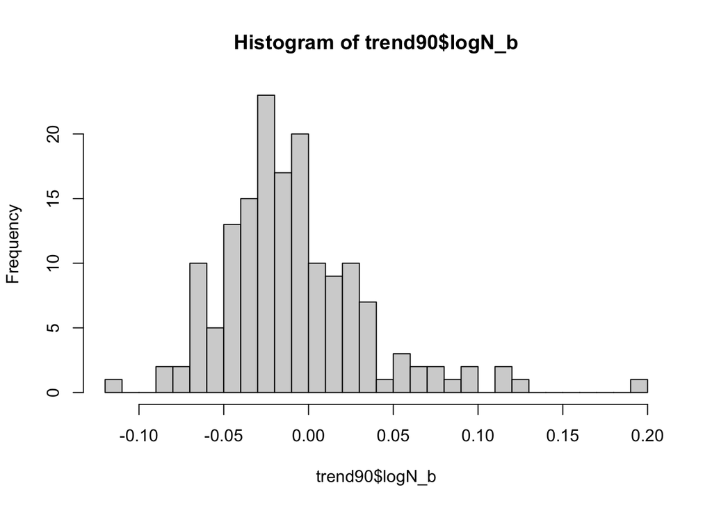

```r
hist(trend90$logN_b, breaks=30)
```

Run the meta-analysis

```r
m.90R <- metagen(TE = logN_b,
                 seTE = logN_SE,
                 studlab = breed,
                 data = trend90,
                 sm = "SMD",
                 fixed = FALSE,
                 random = TRUE,
                 method.tau = "REML",
                 hakn = TRUE,
                 title = "Growth-rate")

summary(m.90R)
```

```
## Review:     Growth-rate
##
##              SMD             95%-CI %W(random)
## ACD       0.0257 [ 0.0069;  0.0445]        0.6
## AFF       0.0010 [-0.0104;  0.0123]        0.6
## AFG      -0.0648 [-0.0744; -0.0552]        0.6
## AIRDT    -0.0238 [-0.0287; -0.0188]        0.6
## AKT      -0.0470 [-0.0690; -0.0249]        0.6
## AMAL      0.0948 [ 0.0600;  0.1296]        0.5
## AMCOCK   -0.0305 [-0.0390; -0.0219]        0.6
## ANATOL   -0.0747 [-0.1043; -0.0451]        0.6
## AUSHEP    0.0537 [ 0.0422;  0.0651]        0.6
## AUSILK   -0.0447 [-0.0608; -0.0286]        0.6
## AUT      -0.0193 [-0.0313; -0.0072]        0.6
## BASS     -0.0322 [-0.0414; -0.0230]        0.6
## BC        0.0014 [-0.0034;  0.0062]        0.6
## BDF      -0.0547 [-0.0680; -0.0413]        0.6
## BEAG      0.0397 [ 0.0312;  0.0481]        0.6
## BEARD    -0.0610 [-0.0654; -0.0565]        0.6
## BEDLT     0.0122 [ 0.0053;  0.0191]        0.6
## BFDG      0.0504 [ 0.0360;  0.0649]        0.6
## BGVP      0.0087 [-0.0065;  0.0240]        0.6
## BICHF    -0.0489 [-0.0632; -0.0346]        0.6
## BLOOD    -0.0283 [-0.0456; -0.0111]        0.6
## BMD      -0.0162 [-0.0220; -0.0104]        0.6
## BORDT     0.0292 [ 0.0167;  0.0417]        0.6
## BORZ     -0.0364 [-0.0428; -0.0300]        0.6
## BOSTT     0.1173 [ 0.1044;  0.1302]        0.6
## BOX      -0.0355 [-0.0451; -0.0259]        0.6
## BRD      -0.0224 [-0.0317; -0.0131]        0.6
## BRITT    -0.0093 [-0.0190;  0.0005]        0.6
## BSDG     -0.0615 [-0.0733; -0.0498]        0.6
## BSDM      0.1203 [ 0.0974;  0.1431]        0.6
## BSDT     -0.0613 [-0.0698; -0.0527]        0.6
## BSNJI    -0.0201 [-0.0374; -0.0029]        0.6
## BULLD     0.0701 [ 0.0628;  0.0773]        0.6
## BULLM    -0.0496 [-0.0646; -0.0347]        0.6
## BULLT    -0.0115 [-0.0209; -0.0022]        0.6
## BULLTM    0.0302 [ 0.0189;  0.0414]        0.6
## CAIRN    -0.0624 [-0.0694; -0.0554]        0.6
```

[output cut: 126 more lines]

```
## Random effects model (HK) -0.0089 [-0.0156; -0.0022] -2.62  0.0096
##
## Quantifying heterogeneity:
##  tau^2 = 0.0018 [0.0015; 0.0023]; tau = 0.0420 [0.0388; 0.0482]
##  I^2 = 99.0% [99.0%; 99.1%]; H = 10.06 [9.78; 10.35]
##
## Test of heterogeneity:
##         Q d.f. p-value
##  15993.07  158       0
##
## Details on meta-analytical method:
## - Inverse variance method
## - Restricted maximum-likelihood estimator for tau^2
## - Q-Profile method for confidence interval of tau^2 and tau
## - Hartung-Knapp adjustment for random effects model (df = 158)
```

```r
print("Growth rate across the breeds with registrations from 1990, using REML with Hartung-Knapp adjustment")
```

```
## [1] "Growth rate across the breeds with registrations from 1990, using REML with Hartung-Knapp adjustment"
```

```r
print(paste0(round(exp(m.90R$TE.random)*100-100,digits=2), " (95% CI: ", round(exp(m.90R$lower.random)*100-100,digits=2), " to ", round(exp(m.90R$upper.random)*100-100,digits=2), "%)"))
```

```
## [1] "-0.89 (95% CI: -1.55 to -0.22%)"
```

Check for breeds with significant trends

```r
signTrend<-as.data.frame(trend90 %>% filter(logN_p<0.05))
summary(signTrend$pp)
```

```
##     Min.  1st Qu.   Median     Mean  3rd Qu.     Max.
## -10.5689  -4.0761  -2.0844  -0.8911   2.1383  22.0694
```

```r
print(paste0("Standard deviation: ", round(sd(signTrend$pp),digits=3)))
```

```
## [1] "Standard deviation: 5.005"
```

```r
print(paste0("Number of breeds: ",nrow(signTrend)))
```

```
## [1] "Number of breeds: 123"
```

```r
paste0("Negative trend: ",nrow(filter(signTrend,pp<0))," (",nrow(filter(signTrend,pp<0))/nrow(signTrend)*100,"%)")
```

```
## [1] "Negative trend: 84 (68.2926829268293%)"
```

```r
paste0("No trend: ",nrow(filter(signTrend,pp==0)), " (",nrow(filter(signTrend,pp==0))/nrow(signTrend)*100,"%)")
```

```
## [1] "No trend: 0 (0%)"
```

```r
paste0("Positive trend: ",nrow(filter(signTrend,pp>0)), " (",nrow(filter(signTrend,pp>0))/nrow(signTrend)*100,"%)")
```

```
## [1] "Positive trend: 39 (31.7073170731707%)"
```

```r
paste0("Growth rate < -25%: ", nrow(signTrend %>% filter(pp<(-25))))
```

```
## [1] "Growth rate < -25%: 0"
```

```r
paste0("Growth rate between -25% and -10%: ", nrow(signTrend %>% filter(pp<(-10)) %>% filter(pp>(-26))))
```

```
## [1] "Growth rate between -25% and -10%: 1"
```

```r
paste0("Growth rate between -9% and 0% ", nrow(signTrend %>% filter(pp<(0)) %>% filter(pp>(-10))))
```

```
## [1] "Growth rate between -9% and 0% 83"
```

```r
paste0("Growth rate between 0% and 9% ", nrow(signTrend %>% filter(pp<(10)) %>% filter(pp>(0))))
```

```
## [1] "Growth rate between 0% and 9% 34"
```

```r
paste0("Growth rate between 10% and 25% ", nrow(signTrend %>% filter(pp<(26)) %>% filter(pp>(9))))
```

```
## [1] "Growth rate between 10% and 25% 7"
```

```r
paste0("Growth rate >25% ", nrow(signTrend %>% filter(pp>(25))))
```

```
## [1] "Growth rate >25% 0"
```

Print out breeds with highest growth and decline - using output of meta-analysis to get confidence intervals

```r
meta_limit_breeds_growth<-function(metaname) {
  stud_idx_min = which.min(metaname$TE)
  breed_min = metaname$studlab[stud_idx_min]
  min_est = round(exp(metaname$TE[stud_idx_min])*100-100,digits=1)
  min_CIlow = round(exp(metaname$lower[stud_idx_min])*100-100,digits=1)
  min_CIupp = round(exp(metaname$upper[stud_idx_min])*100-100,digits=1)

  stud_idx_max = which.max(metaname$TE)
  breed_max = metaname$studlab[stud_idx_max]
  max_est = round(exp(metaname$TE[stud_idx_max])*100-100,digits=1)
  max_CIlow = round(exp(metaname$lower[stud_idx_max])*100-100,digits=1)
  max_CIupp = round(exp(metaname$upper[stud_idx_max])*100-100,digits=1)

  print(paste0("Largest decline in ", breed_min, " at ", min_est, "% (95% CI: ", min_CIlow, "% to ", min_CIupp, "%)"))
  print(paste0("Largest growth in ", breed_max, " at ", max_est, "% (95% CI: ", max_CIlow, "% to ", max_CIupp, "%)"))
}
```

```r
meta_limit_breeds_growth(m.90R)
```

```
## [1] "Largest decline in YT at -10.6% (95% CI: -11.3% to -9.9%)"
## [1] "Largest growth in FBULL at 22.1% (95% CI: 18.5% to 25.7%)"
```

### Trends in popularity since 2010

Calculate registration trends within the last 10 years.

Note - in the original across-breed analysis, I have limited this to breeds which had at least 40 dogs registered between 2006 and 2009. But, this isn’t a fair comparison to the whole period, where the only requirement was that at least 10 national dog were registered in 1990. Change accordingly. The script largely repeats the steps done for the whole period, but limiting trend to period since 2010.

```r
## Create data frame to store the results
# trends2010<-data.frame(breed=NA,n2010=NA,logN_b=NA,logN_SE=NA,logN_p=NA,pp=NA)
#
# for (b in breed_folders) {
#   bname=str_split_i(b,'/',-1)
#   ## From census stats, extract the number of dogs born in 2006 to 2009
#   filename=paste0(b,"/out_tables/census_stats_national.csv")
#   if (file.exists(filename)) {
#     cs <-read.csv(filename)
#     n = cs %>% filter(yob==2010) %>% pull(tborn)
#     ## If n is >9, calculate regression coefficient for dogs born from 2010
#     if (!is_empty(n) && n>9) {
#       temp = as.data.frame(cs %>% filter(yob>2009))
#       n2 = sum(temp$tborn)
#
#       if (n2>0) {
#
#         ## Replace 0s with 1s for tborn and calcualte log values
#         temp$tborn2 = temp$tborn+1
#         temp$logn = log(temp$tborn2)
#         ## Convert yob to numeric from 1 (1990) to 32 (2021)
#         temp$y<-temp$yob-1989
#
#         ## Run regression on log
#         regl<-lm(logn ~ y, data=temp)
#         lb = summary(regl)$coefficients[2,1]
#         lse = summary(regl)$coefficients[2,2]
#         lp = summary(regl)$coefficients[2,4]
#         antilog = exp(lb)
#         pp = antilog*100-100
#
#         trends2010[nrow(trends2010) + 1,] = c(bname,n,lb,lse,lp,pp)
#
#       } else {
#         trends2010[nrow(trends2010) + 1,] = c(bname,n,NA,NA,NA,NA)
#       }
#
#     } else {
#       trends2010[nrow(trends2010) + 1,] = c(bname,0,NA,NA,NA,NA)
#     }
#   } else {
#     next
#   }
# }
#
# ## Remove the first empty row
# trends2010<-trends2010[!is.na(trends2010$breed),]
#
# ## Convert to numeric
# cols.num<-names(trends2010)[2:6]
# trends2010[cols.num]<-sapply(trends2010[cols.num],as.numeric)
#
# ## Remove breeds with missing regression coefficient
# trends2010<-trends2010[!is.na(trends2010$logN_b),]
#
# write.csv(trends2010,"1_trends_in_popularity_since2010.csv", row.names=FALSE)
```

```r
trends2010<-read.csv("1_trends_in_popularity_since2010.csv")
head(trends2010)
```

```
##   breed n2010       logN_b     logN_SE       logN_p          pp
## 1   ACD    65 -0.016775954 0.029330784 5.799799e-01  -1.6636021
## 2   AFF    73  0.005199382 0.018390923 7.831612e-01   0.5212923
## 3   AFG    69 -0.052231569 0.029929432 1.115511e-01  -5.0890943
## 4 AIRDT   569  0.008824762 0.009019936 3.509703e-01   0.8863815
## 5   AKT  1001 -0.180067600 0.012182087 4.025845e-08 -16.4786251
## 6  AMAL  1252 -0.161642607 0.013320274 2.629323e-07 -14.9254799
```

```r
trends2010 %>% filter(n2010<10)
```

```
## [1] breed   n2010   logN_b  logN_SE logN_p  pp
## <0 rows> (or 0-length row.names)
```

Run meta-analysis on all breeds

```r
m.2010 <- metagen(TE = logN_b,
                 seTE = logN_SE,
                 studlab = breed,
                 data = trends2010,
                 sm = "SMD",
                 fixed = FALSE,
                 random = TRUE,
                 method.tau = "REML",
                 hakn = TRUE,
                 title = "Growth-rate since 2010")

summary(m.2010)
```

```
## Review:     Growth-rate since 2010
##
##                SMD             95%-CI %W(random)
## ACD        -0.0168 [-0.0743;  0.0407]        0.5
## AFF         0.0052 [-0.0308;  0.0412]        0.6
## AFG        -0.0522 [-0.1109;  0.0064]        0.5
## AIRDT       0.0088 [-0.0089;  0.0265]        0.6
## AKT        -0.1801 [-0.2039; -0.1562]        0.6
## AMAL       -0.1616 [-0.1877; -0.1355]        0.6
## AMCOCK     -0.0398 [-0.0599; -0.0197]        0.6
## ANATOL      0.0124 [-0.1863;  0.2110]        0.2
## AUSHEP      0.0529 [ 0.0226;  0.0831]        0.6
## AUSILK     -0.0749 [-0.1313; -0.0186]        0.5
## AUT         0.0210 [-0.0324;  0.0744]        0.5
## BASS       -0.0625 [-0.0827; -0.0423]        0.6
## BC         -0.0282 [-0.0374; -0.0190]        0.6
## BDF        -0.0960 [-0.1644; -0.0277]        0.5
## BEAG       -0.0240 [-0.0323; -0.0156]        0.6
## BEARD      -0.0649 [-0.0908; -0.0391]        0.6
## BEDLT      -0.0341 [-0.0536; -0.0147]        0.6
## BFDG       -0.0249 [-0.0465; -0.0033]        0.6
## BGVG       -0.0787 [-0.1337; -0.0237]        0.5
## BGVP       -0.0256 [-0.0669;  0.0157]        0.5
## BICHF      -0.1727 [-0.1880; -0.1573]        0.6
## BLOOD      -0.0600 [-0.1615;  0.0415]        0.4
## BMD        -0.0242 [-0.0486;  0.0002]        0.6
## BMH         0.0385 [-0.0301;  0.1071]        0.5
## BOLO       -0.0661 [-0.0995; -0.0327]        0.6
## BORDT      -0.0403 [-0.0561; -0.0246]        0.6
## BORZ       -0.0281 [-0.0554; -0.0007]        0.6
## BOSTT       0.0697 [ 0.0387;  0.1008]        0.6
## BOX        -0.0310 [-0.0531; -0.0088]        0.6
## BRACC       0.1039 [ 0.0643;  0.1435]        0.5
## BRD        -0.0390 [-0.0805;  0.0025]        0.5
## BRITT      -0.0498 [-0.0872; -0.0125]        0.6
## BSDG       -0.0468 [-0.1110;  0.0174]        0.5
## BSDM        0.1199 [ 0.0938;  0.1459]        0.6
## BSDT       -0.0986 [-0.1288; -0.0684]        0.6
## BSNJI       0.0760 [-0.0195;  0.1715]        0.4
## BULLD       0.1104 [ 0.0982;  0.1226]        0.6
```

[output cut: 151 more lines]

```
## Random effects model (HK) -0.0130 [-0.0234; -0.0026] -2.47  0.0145
##
## Quantifying heterogeneity:
##  tau^2 = 0.0047 [0.0038; 0.0059]; tau = 0.0682 [0.0613; 0.0767]
##  I^2 = 97.0% [96.8%; 97.2%]; H = 5.79 [5.58; 6.02]
##
## Test of heterogeneity:
##        Q d.f. p-value
##  6143.07  183       0
##
## Details on meta-analytical method:
## - Inverse variance method
## - Restricted maximum-likelihood estimator for tau^2
## - Q-Profile method for confidence interval of tau^2 and tau
## - Hartung-Knapp adjustment for random effects model (df = 183)
```

```r
print("Growth rate across the breeds with registrations from 2010, using REML with Hartung-Knapp adjustment")
```

```
## [1] "Growth rate across the breeds with registrations from 2010, using REML with Hartung-Knapp adjustment"
```

```r
print(paste0(round(exp(m.2010$TE.random)*100-100,digits=2), " (95% CI: ", round(exp(m.2010$lower.random)*100-100,digits=2), " to ", round(exp(m.2010$upper.random)*100-100,digits=2), "%)"))
```

```
## [1] "-1.29 (95% CI: -2.31 to -0.26%)"
```

Check for breeds with significant trends

```r
signTrend10<-as.data.frame(trends2010 %>% filter(logN_p<0.05))
summary(signTrend10$pp)
```

```
##    Min. 1st Qu.  Median    Mean 3rd Qu.    Max.
## -16.889  -7.125  -3.766  -1.494   4.320  34.912
```

```r
print(paste0("Standard deviation: ", round(sd(signTrend10$pp),digits=3)))
```

```
## [1] "Standard deviation: 9.198"
```

```r
print(paste0("Number of breeds: ",nrow(signTrend10)))
```

```
## [1] "Number of breeds: 103"
```

```r
paste0("Negative trend: ",nrow(filter(signTrend10,pp<0))," (",nrow(filter(signTrend10,pp<0))/nrow(signTrend10)*100,"%)")
```

```
## [1] "Negative trend: 72 (69.9029126213592%)"
```

```r
paste0("No trend: ",nrow(filter(signTrend10,pp==0)), " (",nrow(filter(signTrend10,pp==0))/nrow(signTrend10)*100,"%)")
```

```
## [1] "No trend: 0 (0%)"
```

```r
paste0("Positive trend: ",nrow(filter(signTrend10,pp>0)), " (",nrow(filter(signTrend10,pp>0))/nrow(signTrend10)*100,"%)")
```

```
## [1] "Positive trend: 31 (30.0970873786408%)"
```

```r
paste0("Growth rate < -25%: ", nrow(signTrend10 %>% filter(pp<(-25))))
```

```
## [1] "Growth rate < -25%: 0"
```

```r
paste0("Growth rate between -25% and -10%: ", nrow(signTrend10 %>% filter(pp<(-10)) %>% filter(pp>(-26))))
```

```
## [1] "Growth rate between -25% and -10%: 12"
```

```r
paste0("Growth rate between -9% and 0% ", nrow(signTrend10 %>% filter(pp<(0)) %>% filter(pp>(-10))))
```

```
## [1] "Growth rate between -9% and 0% 60"
```

```r
paste0("Growth rate between 0% and 9% ", nrow(signTrend10 %>% filter(pp<(10)) %>% filter(pp>(0))))
```

```
## [1] "Growth rate between 0% and 9% 16"
```

```r
paste0("Growth rate between 10% and 25% ", nrow(signTrend10 %>% filter(pp<(26)) %>% filter(pp>(9))))
```

```
## [1] "Growth rate between 10% and 25% 15"
```

```r
paste0("Growth rate >25% ", nrow(signTrend10 %>% filter(pp>(25))))
```

```
## [1] "Growth rate >25% 1"
```

Print out breeds with highest growth and decline - using output of meta-analysis to get confidence intervals

```r
meta_limit_breeds_growth(m.2010)
```

```
## [1] "Largest decline in PYRSHLH at -16.9% (95% CI: -24.5% to -8.5%)"
## [1] "Largest growth in FBULL at 34.9% (95% CI: 29.4% to 40.7%)"
```

Trends in top10 breeds since 2010

```r
trends2010_top10<-trends2010[trends2010$breed %in% c('LAB','FBULL','ECS','BULLD','DAXMSH','ESS','GOLD','GSD','STAFF','PUG'),]



m.2010_top10 <- metagen(TE = logN_b,
                 seTE = logN_SE,
                 studlab = breed,
                 data = trends2010_top10,
                 sm = "SMD",
                 fixed = FALSE,
                 random = TRUE,
                 method.tau = "REML",
                 hakn = TRUE,
                 title = "Growth-rate since 2010")

summary(m.2010_top10)
```

```
## Review:     Growth-rate since 2010
##
##            SMD             95%-CI %W(random)
## BULLD   0.1104 [ 0.0982;  0.1226]       10.2
## DAXMSH  0.1607 [ 0.1323;  0.1891]       10.0
## ECS     0.0243 [ 0.0029;  0.0457]       10.1
## ESS    -0.0181 [-0.0423;  0.0061]       10.1
## FBULL   0.2995 [ 0.2576;  0.3413]        9.8
## GOLD    0.0279 [ 0.0087;  0.0472]       10.1
## GSD    -0.0253 [-0.0387; -0.0118]       10.2
## LAB     0.0164 [-0.0100;  0.0429]       10.0
## PUG     0.0011 [-0.0416;  0.0439]        9.8
## STAFF  -0.0245 [-0.0609;  0.0119]        9.9
##
## Number of studies: k = 10
##
##                              SMD            95%-CI    t p-value
## Random effects model (HK) 0.0568 [-0.0174; 0.1310] 1.73  0.1174
##
## Quantifying heterogeneity:
##  tau^2 = 0.0104 [0.0048; 0.0360]; tau = 0.1020 [0.0692; 0.1897]
##  I^2 = 98.1% [97.5%; 98.6%]; H = 7.27 [6.29; 8.41]
##
## Test of heterogeneity:
##       Q d.f.  p-value
##  475.78    9 < 0.0001
##
## Details on meta-analytical method:
## - Inverse variance method
## - Restricted maximum-likelihood estimator for tau^2
## - Q-Profile method for confidence interval of tau^2 and tau
## - Hartung-Knapp adjustment for random effects model (df = 9)
```

```r
print("Growth rate across the top 10 breeds from 2010, using REML with Hartung-Knapp adjustment")
```

```
## [1] "Growth rate across the top 10 breeds from 2010, using REML with Hartung-Knapp adjustment"
```

```r
print(paste0(round(exp(m.2010_top10$TE.random)*100-100,digits=2), " (95% CI: ", round(exp(m.2010_top10$lower.random)*100-100,digits=2), " to ", round(exp(m.2010_top10$upper.random)*100-100,digits=2), "%)"))
```

```
## [1] "5.84 (95% CI: -1.73 to 14%)"
```

Print estimates for the breeds for which there was a significant change in population size:

```r
est_breed<-function(breed,mname) {
  ## Find index of the breed acronym in study labs
  bidx=match(breed,mname$studlab)
  est = round(exp(mname$TE[bidx])*100-100,digits=1)
  CIlow = round(exp(mname$lower[bidx])*100-100,digits=1)
  CIupp = round(exp(mname$upper[bidx])*100-100,digits=1)

  print(paste0("Estimates for ", breed, ": ", est, "% (95% CI: ", CIlow," - ", CIupp, ")"))

}
```

```r
for (b in trends2010_top10 %>% arrange(.,pp) %>% filter(logN_p<0.05) %>% select(breed)) {
  est_breed(b,m.2010_top10)
}
```

```
## [1] "Estimates for GSD: -2.5% (95% CI: -3.8 - -1.2)"
## [2] "Estimates for GOLD: 2.8% (95% CI: 0.9 - 4.8)"
## [3] "Estimates for BULLD: 11.7% (95% CI: 10.3 - 13)"
## [4] "Estimates for DAXMSH: 17.4% (95% CI: 14.1 - 20.8)"
## [5] "Estimates for FBULL: 34.9% (95% CI: 29.4 - 40.7)"
```

## 2. Proportion of dogs used in breeding

Extracts the number of dogs in Lreg born between 2005 and 2015, and calculates proportion of bred from.

```r
# resBP<-data.frame(breed=NA,n_born=NA,n_parents=NA,pb=NA)
#
# breed_folders <- list.dirs("../../outputs", recursive = FALSE)
# for (b in breed_folders) {
#   bname=str_split_i(b,'/',-1)
#   ## From log file, extract the numbers
#   filename=paste0(b,"/",bname,"_popAnalysis_log.txt")
#   if (file.exists(filename)) {
#     ## Find line reporting proportion of dogs born used in breeding
#     logfile = readLines(filename)
#     ## Find correct line in log file
#     line = which(grepl("Proportion of dogs born between 2005 and 2015 inclusive, that became parents:", logfile))
#     ## If the line is found
#     if (length(logfile[line])>0) {
#       ## Extract percentage to a variable
#       pb=as.numeric(str_split((str_split(logfile[line],': ',simplify=TRUE)[-1]),"%",simplify=TRUE)[1])
#       ## Extract the number of events - i.e. parents
#       parents = str_split_1(logfile[line+2],":")[-1]
#       born = str_split_1(logfile[line+1],":")[-1]
#       resBP[nrow(resBP) + 1,] = c(bname,born,parents,pb)
#     } else {
#       resBP[nrow(resBP) + 1,] = c(bname,NA,NA,NA)
#     }
#   } else {
#     resBP[nrow(resBP) + 1,] = c(bname,NA,NA,NA)
#   }
# }
#
# ## Remove the first empty row
# resBP<-resBP[!is.na(resBP$breed),]
#
#
# ## Convert to numeric
# cols.num<-names(resBP)[2:4]
# resBP[cols.num]<-sapply(resBP[cols.num],as.numeric)
#
# write.csv(resBP,"2_proportionBred.csv",row.names=FALSE)
```

```r
resBP<-read.csv("3_proportionBred.csv")
head(resBP)
```

```
##   breed n_born n_parents    pb
## 1   ACD    690        73 10.58
## 2   AFF   1212       313 25.83
## 3   AFG   1572       161 10.24
## 4 AIRDT   7486       589  7.87
## 5   AKT  10146      1086 10.70
## 6  AMAL  10714      1174 10.96
```

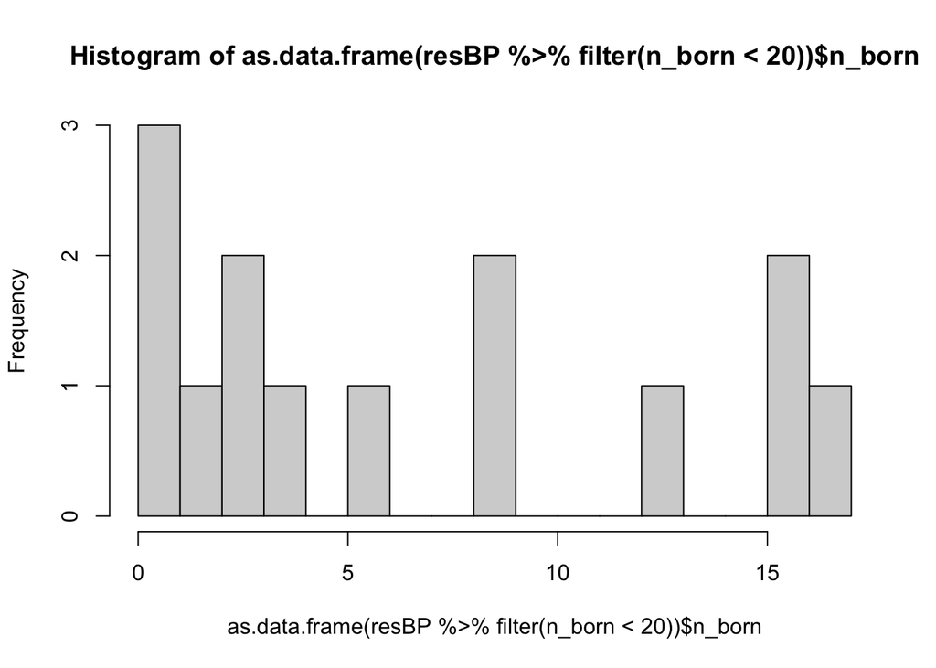

```r
hist(as.data.frame(resBP%>% filter(n_born<20))$n_born,breaks=20)
```

Remove breeds with <10 registrations in 2005 - 2015. Rare breeds are chaotic, but they do provide an interesting viewing. This is a change compared to individual scripts, as there only filtered out breeds with no dogs born

```r
paste0("Started with ",nrow(resBP), " breeds")
```

```
## [1] "Started with 222 breeds"
```

```r
resPB<-resBP %>% filter(n_born>9)
paste0("Retained ", nrow(resPB), " after removing breeds with 0 dogs born")
```

```
## [1] "Retained 210 after removing breeds with 0 dogs born"
```

Some basic stats for the percentage.

```r
summary(resPB$pb)
```

```
##    Min. 1st Qu.  Median    Mean 3rd Qu.    Max.
##    0.00   10.53   13.09   14.24   16.77   46.00
```

Find min and max

```r
resPB[which.min(resPB$pb),]
```

```
##      breed n_born n_parents pb
## 189 SMUNST     13         0  0
```

```r
resPB[which.max(resPB$pb),]
```

```
##     breed n_born n_parents pb
## 124   JRT     50        23 46
```

Run meta-analysis - all breeds.

```r
m.prop <- metaprop(event = n_parents,
                   n = n_born,
                   studlab = breed,
                   data = resPB,
                   method = "GLMM",
                   sm = "PLOGIT",
                   fixed = FALSE,
                   random = TRUE,
                   hakn = TRUE,
                   title = "ProportionParents")
summary(m.prop)
```

```
## Review:     ProportionParents
##
##            proportion           95%-CI
## ACD            0.1058 [0.0838; 0.1312]
## AFF            0.2583 [0.2338; 0.2839]
## AFG            0.1024 [0.0879; 0.1185]
## AIRDT          0.0787 [0.0727; 0.0850]
## AKT            0.1070 [0.1011; 0.1132]
## AMAL           0.1096 [0.1037; 0.1156]
## AMCOCK         0.1414 [0.1301; 0.1533]
## ANATOL         0.0472 [0.0272; 0.0755]
## AUSHEP         0.1058 [0.0905; 0.1228]
## AUSILK         0.1910 [0.1361; 0.2566]
## AUT            0.1667 [0.1334; 0.2044]
## AZWKH          0.0625 [0.0016; 0.3023]
## BASS           0.0969 [0.0913; 0.1026]
## BAUC           0.0856 [0.0497; 0.1352]
## BBDG           0.0741 [0.0091; 0.2429]
## BC             0.1089 [0.1050; 0.1128]
## BDF            0.0941 [0.0756; 0.1155]
## BEAG           0.1218 [0.1179; 0.1259]
## BEARD          0.0954 [0.0880; 0.1032]
## BEDLT          0.1583 [0.1487; 0.1683]
## BERG           0.1481 [0.0419; 0.3373]
## BFDG           0.1273 [0.1074; 0.1495]
## BGVG           0.0818 [0.0660; 0.1001]
## BGVP           0.1320 [0.1151; 0.1505]
## BICHF          0.1191 [0.1149; 0.1234]
## BLOOD          0.1243 [0.1018; 0.1499]
## BMD            0.1044 [0.0973; 0.1119]
## BMH            0.1643 [0.1304; 0.2030]
## BOLO           0.1332 [0.1149; 0.1532]
## BORDT          0.1299 [0.1276; 0.1322]
## BORZ           0.1452 [0.1253; 0.1671]
## BOSTT          0.2425 [0.2343; 0.2509]
## BOX            0.1009 [0.0987; 0.1033]
## BRACC          0.1147 [0.0912; 0.1419]
## BRD            0.0877 [0.0739; 0.1033]
## BRITT          0.1095 [0.0941; 0.1264]
## BSDG           0.0779 [0.0584; 0.1014]
```

[output cut: 182 more lines]

```
##  tau^2 = 0.1640; tau = 0.4049; I^2 = 99.6%; H = 16.01
##
## Test of heterogeneity:
##              Q d.f. p-value
##  Wald 53576.16  209       0
##  LRT  51347.66  209       0
##
## Details on meta-analytical method:
## - Random intercept logistic regression model
## - Maximum-likelihood estimator for tau^2
## - Random effects confidence interval based on t-distribution (df = 209)
## - Logit transformation
## - Clopper-Pearson confidence interval for individual studies
## - Continuity correction of 0.5 in studies with zero cell frequencies
##   (only used to calculate individual study results)
```

Note - extracting the estimates from metaprop is not trivial, as the estimates that are printed out in summary are backtransformed - when results are extracted from meta-analysis object directly, they are before transformation. As such, use the previous simple min and max for proportion and find those in the summary for the corresponding CIs. The breeds to find are SMUNST and JRT.

## 2.1 Proportion of males used in breeding

Extract data from new log files Proportion of LReg males born in 2015 used in breeding.

```r
# ms<-data.frame(breed=NA,n_males=NA,n_sires=NA)
#
# breed_folders <- list.dirs("../../outputs", recursive = FALSE)
# for (b in breed_folders) {
#   bname=str_split_i(b,'/',-1)
#   ## From log file, extract the numbers
#   filename=paste0(b,"/",bname,"_males_sires_2015.txt")
#   if (file.exists(filename)) {
#     ## Find line reporting proportion of dogs born used in breeding
#     logfile = readLines(filename)
#     ## Find correct lines in log file
#     line1 = which(grepl("N_males", logfile))
#     line2 = which(grepl("N_sires", logfile))
#     ## If the line is found
#     if (length(logfile[line])>0) {
#       ## Extract the number of events - i.e. parents
#       nmales = str_split_1(logfile[line1],",")[-1]
#       nsires = str_split_1(logfile[line2],",")[-1]
#       ms[nrow(ms) + 1,] = c(bname,nmales,nsires)
#     } else {
#       ms[nrow(ms) + 1,] = c(bname,NA,NA)
#     }
#   } else {
#     ms[nrow(ms) + 1,] = c(bname,NA,NA)
#   }
# }
#
# ## Remove the first empty row
# ms<-ms[!is.na(ms$breed),]
#
# ## Convert to numeric
# cols.num<-names(ms)[2:3]
# ms[cols.num]<-sapply(ms[cols.num],as.numeric)
#
# ## Calculate percentage
# ms$perc<-round(ms$n_sires/ms$n_males*100,digits=2)
# ms$logNborn<-log(ms$n_males)

# write.csv(ms,"3_proportionBred_sires2015.csv",row.names=FALSE)
```

```r
ms<-read.csv("3_proportionBred_sires2015.csv")
head(ms)
```

```
##   breed n_males n_sires  perc logNborn
## 1   ACD      25       2  8.00 3.218876
## 2   AFF      58      15 25.86 4.060443
## 3   AFG      51       1  1.96 3.931826
## 4 AIRDT     366       8  2.19 5.902633
## 5   AKT     178      15  8.43 5.181784
## 6  AMAL     261      13  4.98 5.564520
```

Remove breed with <10 males born - note for internal report, this is different, previously only removed breeds with 0 males!

```r
paste0("Started with ",nrow(ms), " breeds")
```

```
## [1] "Started with 222 breeds"
```

```r
msm<-ms %>% filter(n_males>9)
paste0("Retained ", nrow(msm), " after removing breeds with <10 male dogs born")
```

```
## [1] "Retained 177 after removing breeds with <10 male dogs born"
```

Find max

```r
head(msm[order(msm$perc, decreasing=TRUE),],3)
```

```
##    breed n_males n_sires  perc logNborn
## 79  GPIN      14       5 35.71 2.639057
## 9    AUT      11       3 27.27 2.397895
## 2    AFF      58      15 25.86 4.060443
```

```r
head(msm[order(msm$perc, decreasing=FALSE),],10)
```

```
##      breed n_males n_sires perc logNborn
## 13     BDF      13       0 0.00 2.564949
## 32    BSDG      12       0 0.00 2.484907
## 41    CATS      22       0 0.00 3.091042
## 90   HPULI      15       0 0.00 2.708050
## 107  KOOIK      19       0 0.00 2.944439
## 134    PLS      19       0 0.00 2.944439
## 135  PODNG      16       0 0.00 2.772589
## 165 SWVALL      12       0 0.00 2.484907
## 176  XOLOS      12       0 0.00 2.484907
## 149    SAM     115       2 1.74 4.744932
```

Run meta-analysis - all breeds

```r
m.propMS <- metaprop(event = n_sires,
                   n = n_males,
                   studlab = breed,
                   data = msm,
                   method = "GLMM",
                   sm = "PLOGIT",
                   fixed = FALSE,
                   random = TRUE,
                   hakn = TRUE,
                   title = "ProportionMales")
summary(m.propMS)
```

```
## Review:     ProportionMales
##
##            proportion           95%-CI
## ACD            0.0800 [0.0098; 0.2603]
## AFF            0.2586 [0.1526; 0.3904]
## AFG            0.0196 [0.0005; 0.1045]
## AIRDT          0.0219 [0.0095; 0.0426]
## AKT            0.0843 [0.0479; 0.1352]
## AMAL           0.0498 [0.0268; 0.0837]
## AMCOCK         0.1134 [0.0580; 0.1939]
## AUSHEP         0.0200 [0.0005; 0.1065]
## AUT            0.2727 [0.0602; 0.6097]
## BASS           0.0459 [0.0253; 0.0758]
## BAUC           0.1154 [0.0245; 0.3015]
## BC             0.0675 [0.0524; 0.0854]
## BDF            0.0000 [0.0000; 0.2471]
## BEAG           0.0309 [0.0219; 0.0424]
## BEARD          0.0592 [0.0287; 0.1061]
## BEDLT          0.0930 [0.0578; 0.1400]
## BFDG           0.1212 [0.0340; 0.2820]
## BGVG           0.0784 [0.0218; 0.1888]
## BGVP           0.1212 [0.0340; 0.2820]
## BICHF          0.0639 [0.0438; 0.0895]
## BLOOD          0.1190 [0.0398; 0.2563]
## BMD            0.0495 [0.0250; 0.0869]
## BMH            0.0303 [0.0008; 0.1576]
## BOLO           0.0588 [0.0163; 0.1438]
## BORDT          0.0555 [0.0472; 0.0649]
## BORZ           0.1064 [0.0355; 0.2310]
## BOSTT          0.0944 [0.0769; 0.1144]
## BOX            0.0392 [0.0305; 0.0494]
## BRACC          0.0556 [0.0116; 0.1539]
## BRD            0.0235 [0.0029; 0.0824]
## BRITT          0.0267 [0.0032; 0.0930]
## BSDG           0.0000 [0.0000; 0.2646]
## BSDM           0.0610 [0.0201; 0.1366]
## BSDT           0.0909 [0.0253; 0.2167]
## BSNJI          0.0741 [0.0091; 0.2429]
## BULLD          0.0859 [0.0767; 0.0958]
## BULLM          0.0600 [0.0359; 0.0932]
```

[output cut: 149 more lines]

```
##  tau^2 = 0.2111; tau = 0.4594; I^2 = 86.1% [84.2%; 87.7%]; H = 2.68 [2.52; 2.85]
##
## Test of heterogeneity:
##             Q d.f.  p-value
##  Wald 1262.89  176 < 0.0001
##  LRT  1312.94  176 < 0.0001
##
## Details on meta-analytical method:
## - Random intercept logistic regression model
## - Maximum-likelihood estimator for tau^2
## - Random effects confidence interval based on t-distribution (df = 176)
## - Logit transformation
## - Clopper-Pearson confidence interval for individual studies
## - Continuity correction of 0.5 in studies with zero cell frequencies
##   (only used to calculate individual study results)
```

Meta-analysis for top 10 breeds

```r
msm_top10<-msm[msm$breed %in% c('LAB','FBULL','ECS','BULLD','DAXMSH','ESS','GOLD','GSD','STAFF','PUG'),]
m.propMS10 <- metaprop(event = n_sires,
                   n = n_males,
                   studlab = breed,
                   data = msm_top10,
                   method = "GLMM",
                   sm = "PLOGIT",
                   fixed = FALSE,
                   random = TRUE,
                   hakn = TRUE,
                   title = "ProportionMalestop10")
summary(m.propMS10)
```

```
## Review:     ProportionMalestop10
##
##        proportion           95%-CI
## BULLD      0.0859 [0.0767; 0.0958]
## DAXMSH     0.0807 [0.0683; 0.0946]
## ECS        0.0684 [0.0639; 0.0732]
## ESS        0.0822 [0.0748; 0.0900]
## FBULL      0.1152 [0.1079; 0.1227]
## GOLD       0.0314 [0.0260; 0.0377]
## GSD        0.0350 [0.0295; 0.0413]
## LAB        0.0480 [0.0448; 0.0513]
## PUG        0.0746 [0.0673; 0.0824]
## STAFF      0.0856 [0.0744; 0.0979]
##
## Number of studies: k = 10
## Number of observations: o = 60285
## Number of events: e = 4081
##
##                      proportion           95%-CI
## Random effects model     0.0662 [0.0498; 0.0876]
##
## Quantifying heterogeneity:
##  tau^2 = 0.1751; tau = 0.4185; I^2 = 98.3% [97.7%; 98.7%]; H = 7.67 [6.67; 8.83]
##
## Test of heterogeneity:
##            Q d.f.  p-value
##  Wald 529.61    9 < 0.0001
##  LRT  555.65    9 < 0.0001
##
## Details on meta-analytical method:
## - Random intercept logistic regression model
## - Maximum-likelihood estimator for tau^2
## - Random effects confidence interval based on t-distribution (df = 9)
## - Logit transformation
## - Clopper-Pearson confidence interval for individual studies
```

Forest plot

```r
pdf(file = "Fig1_MA_forest_top10_propBorn_males2015.pdf", width = 2800, height = 2400)

forest.meta(m.propMS10,
            sortvar = TE,
            prediction = TRUE,
            print.tau2 = FALSE,
            # smlab="Growth 2010 - 2021",
            leftcols=c('studlab'),
            leftlab=c("Breed"),
            print.I2=FALSE,
            print.I2.ci=FALSE,
            # rightlabs = c("Growth (%)", "95% CI", "Weight"),
            rightcols=c('perc','n_males'),
            rightlabs=c("%","Males born"),
            digits.addcols.right = 1,
            just.addcols.right='right',
            colgap.forest.right="1cm",
            col.study='black',
            col.inside = 'black',

)

dev.off()
```

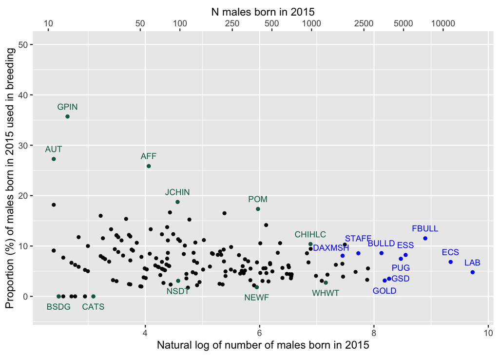

```r
interest<-msm[msm$breed %in% c('AFF','AUT','GPIN','JCHIN','POM', 'JRT','NEWF','CHIHLC','NSDT','WHWT','BSDG','CATS'),]
ynud<-c(2,2,-2,-2,2,2,2,-2,-2,2,-2)
xnud2<-c(0,-0.2,0,0,0,0,0.2,0,0,0)
ynud2<-c(2,1.65,2,2,2,-2,0.1,2,-1.7,3)

ggplot(data=msm,aes(x=logNborn,y=perc)) +
  scale_x_continuous("Natural log of number of males born in 2015",sec.axis=sec_axis(~exp(.), name="N males born in 2015", breaks=c(1,10,50,100,250,500,1000,2500,5000,10000,40000,120000))) +
  ylab("Proportion (%) of males born in 2015 used in breeding")+
  xlab("Log(n_born")+
  # geom_line(data=trend3,aes(ln07_17,predicted.value),colour="red")+
  # geom_line(aes(y = alin3+blin3*ln07_17), colour = "grey30", linetype="dashed")+
  geom_point(data=msm,aes(x=logNborn,y=perc),shape=20,size=2,colour="black")+
  geom_point(data=interest,aes(x=logNborn,y=perc),shape=20,size=2,colour=kcgreen)+
  geom_text(data=interest,aes(label=breed),colour=kcgreen, size = 3, nudge_y = ynud) +
  geom_point(data=msm_top10,aes(x=logNborn,y=perc),shape=20,size=2,colour="blue")+
  geom_text(data=msm_top10,aes(label=breed),colour="blue", size = 3, nudge_y = ynud2,nudge_x=xnud2) +
  ylim(-3,50)#, nudge_x = xnud)
```

```r
ggsave("Fig2_prop_males_bred.jpg", device = "jpg")
msm[msm$breed=='JCHIN',]
```

```
##     breed n_males n_sires  perc logNborn
## 101 JCHIN      96      18 18.75 4.564348
```

```r
msm[msm$breed=='NSDT',]
```

```
##     breed n_males n_sires perc logNborn
## 129  NSDT      97       3 3.09 4.574711
```

## 3. Purpose-bred dogs and their use in breeding.

### 3.1 Overall proportion of dogs with Studbook Nos

Slightly different chunk to 4_purposeBred.Rmd as I’m not bothering with champion titles here which cause issues with formatting.

```r
# breed_folders <- list.dirs("../../outputs", recursive = FALSE)
#
# purpB<-data.frame(breed=NA,SBN_N=NA)
#
# ## Repeat for the rest of the breeds
# for (b in breed_folders[-1]) {
#   bname=str_split_i(b,'/',-1)
#   filename=paste0(b,"/out_tables/champ_stats.csv")
#   if (file.exists(filename)) {
#     pb<-read.csv(filename)
#     sbn<-pb[pb$ChampTitle=='StudBookNo','ChampTitle_N']
#     purpB[nrow(purpB) + 1,] = c(bname,sbn)
#   } else {
#     next
#   }
#
# }
#
# ## Remove the first empty row
# purpB<-purpB[!is.na(purpB$breed),]
#
# ## Convert to numeric
# purpB$SBN_N<-as.numeric(purpB$SBN_N)
#
# ## Merge with overall pedigree size
# purpB<-merge(purpB, as.data.frame(pedsize %>% select(breed,ped_size)),by='breed')
#
# ## Calculate proportion
# purpB$prop<-purpB$SBN_N/purpB$ped_size
#
# ## Save to file
# write.csv(purpB, "4_purpBred_total.csv", row.names=FALSE)
```

```r
purpB<-read.csv("4_purpBred_total.csv")
head(purpB)
```

```
##    breed SBN_N ped_size       prop
## 1    AFF   477     4513 0.10569466
## 2    AFG  3605    38071 0.09469150
## 3  AIRDT  2978    50056 0.05949337
## 4    AKT   781    33989 0.02297802
## 5   AMAL   398    18755 0.02122101
## 6 AMCOCK  1562    22561 0.06923452
```

Studbook Numbers are not assigned in all breeds. Select only breeds with at least one.

```r
pB<-purpB[purpB$SBN_N>0,]
print(paste0("Breeds with SBNs: ",nrow(pB)))
```

```
## [1] "Breeds with SBNs: 172"
```

Breed with highest percentage

```r
head(pB[order(pB$prop, decreasing=TRUE),],5)
```

```
##       breed SBN_N ped_size      prop
## 190   SEALY  2333     7747 0.3011488
## 90   FSPITZ   675     2577 0.2619325
## 118    IBIH   277     1184 0.2339527
## 133   KEESH  1843     7989 0.2306922
## 156 NORWELK  1693     7469 0.2266702
```

```r
head(pB[order(pB$prop, decreasing=FALSE),],5)
```

```
##       breed SBN_N ped_size         prop
## 139  LAGROM     1     3181 0.0003143666
## 128     JRT     2     4882 0.0004096682
## 29      BMH     1     1613 0.0006199628
## 73      DDB    83    44435 0.0018678969
## 178 PYRSHLH     3     1195 0.0025104603
```

Run meta-analysis to get pooled percentage

```r
m.propSB <- metaprop(event = SBN_N,
                   n = ped_size,
                   studlab = breed,
                   data = pB,
                   method = "GLMM",
                   sm = "PLOGIT",
                   fixed = FALSE,
                   random = TRUE,
                   hakn = TRUE,
                   title = "ProportionSBN")
summary(m.propSB)
```

```
## Review:     ProportionSBN
##
##            proportion           95%-CI
## AFF            0.1057 [0.0969; 0.1150]
## AFG            0.0947 [0.0918; 0.0977]
## AIRDT          0.0595 [0.0574; 0.0616]
## AKT            0.0230 [0.0214; 0.0246]
## AMAL           0.0212 [0.0192; 0.0234]
## AMCOCK         0.0692 [0.0660; 0.0726]
## AUSHEP         0.0361 [0.0323; 0.0402]
## AUT            0.2199 [0.2065; 0.2337]
## BASS           0.0452 [0.0434; 0.0471]
## BC             0.0308 [0.0298; 0.0319]
## BDF            0.0611 [0.0553; 0.0673]
## BEAG           0.0373 [0.0360; 0.0386]
## BEARD          0.0582 [0.0560; 0.0605]
## BEDLT          0.1007 [0.0965; 0.1051]
## BFDG           0.0481 [0.0406; 0.0565]
## BGVG           0.0404 [0.0334; 0.0482]
## BGVP           0.0961 [0.0886; 0.1040]
## BICHF          0.0140 [0.0132; 0.0149]
## BLOOD          0.1988 [0.1899; 0.2079]
## BMD            0.0473 [0.0450; 0.0497]
## BMH            0.0006 [0.0000; 0.0034]
## BORDT          0.0185 [0.0179; 0.0191]
## BORZ           0.1718 [0.1654; 0.1784]
## BOSTT          0.0473 [0.0450; 0.0498]
## BOX            0.0141 [0.0137; 0.0145]
## BRACC          0.0245 [0.0194; 0.0307]
## BRD            0.0955 [0.0895; 0.1018]
## BRITT          0.0462 [0.0407; 0.0521]
## BSDG           0.1379 [0.1298; 0.1463]
## BSDL           0.0077 [0.0021; 0.0197]
## BSDM           0.0199 [0.0167; 0.0235]
## BSDT           0.0940 [0.0882; 0.1001]
## BSNJI          0.2153 [0.2051; 0.2258]
## BULLD          0.0220 [0.0214; 0.0227]
## BULLM          0.0467 [0.0449; 0.0485]
## BULLT          0.0376 [0.0365; 0.0388]
## BULLTM         0.0858 [0.0804; 0.0915]
```

[output cut: 142 more lines]

```
##
## Quantifying heterogeneity:
##  tau^2 = 1.3020; tau = 1.1411; I^2 = 99.9%; H = 40.75
##
## Test of heterogeneity:
##               Q d.f. p-value
##  Wald 283911.11  171       0
##  LRT  275238.80  171       0
##
## Details on meta-analytical method:
## - Random intercept logistic regression model
## - Maximum-likelihood estimator for tau^2
## - Random effects confidence interval based on t-distribution (df = 171)
## - Logit transformation
## - Clopper-Pearson confidence interval for individual studies
```

Proportion of SBNs and pedigree size

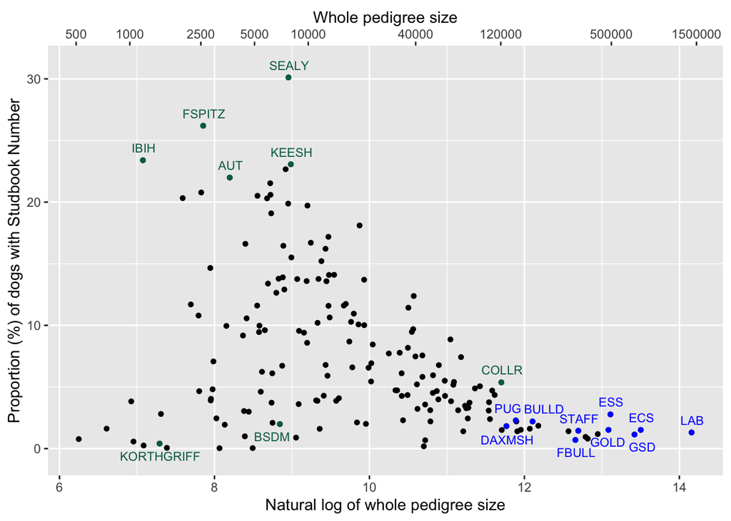

```r
## Calculate logn of ped size
pB$logN = log(pB$ped_size)
pB$perc<-pB$prop*100

pB_top10<-pB[pB$breed %in% c('LAB','FBULL','ECS','BULLD','DAXMSH','ESS','GOLD','GSD','STAFF','PUG'),]
tdf4<-pB[pB$breed %in% c('FSPITZ','IBIH','KEESH','SEALY','KORTHGRIFF','COLLR','AUT','BSDM'),]
xnud <- c(0.01,-0.1,0.01,0.01,0.01,0.01,0.01,0.01)
ynud <- c(1,-1,1,1,1,1,-1,1)
xnud2 <- c(0.15,0.01,0.01,0.01,0.01,-0.01,0.1,0.01,-0.1,0.01)
ynud2 <- c(1,-1.1,1,1,-1,-1,-1,1,1,1)

ggplot(data=pB,aes(x=logN,y=perc)) +
  scale_x_continuous("Natural log of whole pedigree size",sec.axis=sec_axis(~exp(.), name="Whole pedigree size", breaks=c(500,1000,2500,5000,10000,40000,120000,500000,1500000))) +
  ylab("Proportion (%) of dogs with Studbook Number")+
  xlab("Log(n_born")+
  geom_point(data=pB,aes(x=logN,y=perc),shape=20,size=2,colour="black")+
  geom_point(data=tdf4,aes(x=logN,y=perc),shape=20,size=2,colour=kcgreen)+
  geom_text(data=tdf4,aes(label=breed),colour=kcgreen, size = 3, nudge_y = ynud, nudge_x = xnud)+
  geom_point(data=pB_top10,aes(x=logN,y=perc),shape=20,size=2,colour="blue")+
  geom_text(data=pB_top10,aes(label=breed),colour="blue", size = 3, nudge_y = ynud2, nudge_x = xnud2)
```

```r
ggsave("Fig3_purpB_pedSize.jpg", device = "jpg")
pB %>% filter(breed %in% c('SEALY','BSDM'))
```

```
##   breed SBN_N ped_size       prop     logN      perc
## 1  BSDM   138     6934 0.01990193 8.844192  1.990193
## 2 SEALY  2333     7747 0.30114883 8.955061 30.114883
```

Meta-analysis for top 10 breeds

```r
m.propSB_top10 <- metaprop(event = SBN_N,
                   n = ped_size,
                   studlab = breed,
                   data = pB_top10,
                   method = "GLMM",
                   sm = "PLOGIT",
                   fixed = FALSE,
                   random = TRUE,
                   hakn = TRUE,
                   title = "ProportionSBN")
summary(m.propSB_top10)
```

```
## Review:     ProportionSBN
##
##        proportion           95%-CI
## BULLD      0.0220 [0.0214; 0.0227]
## DAXMSH     0.0183 [0.0175; 0.0190]
## ECS        0.0152 [0.0149; 0.0154]
## ESS        0.0278 [0.0273; 0.0282]
## FBULL      0.0070 [0.0067; 0.0073]
## GOLD       0.0152 [0.0148; 0.0155]
## GSD        0.0114 [0.0112; 0.0117]
## LAB        0.0131 [0.0129; 0.0133]
## PUG        0.0228 [0.0221; 0.0236]
## STAFF      0.0145 [0.0141; 0.0149]
##
## Number of studies: k = 10
## Number of observations: o = 4884583
## Number of events: e = 74816
##
##                      proportion           95%-CI
## Random effects model     0.0157 [0.0120; 0.0205]
##
## Quantifying heterogeneity:
##  tau^2 = 0.1444; tau = 0.3800; I^2 = 99.9%; H = 30.54
##
## Test of heterogeneity:
##             Q d.f. p-value
##  Wald 8391.49    9       0
##  LRT  8185.08    9       0
##
## Details on meta-analytical method:
## - Random intercept logistic regression model
## - Maximum-likelihood estimator for tau^2
## - Random effects confidence interval based on t-distribution (df = 9)
## - Logit transformation
## - Clopper-Pearson confidence interval for individual studies
```

### 4.2 Use of SBN dogs in breeding - purpose-bred litters

Function to produce the input table for regression

```r
prep_pBdf <-function(breed){
  ## Read raw data for litters
  df<-read.csv(paste0("../../outputs/",breed,"/out_tables/litter_stats.csv"))
  ## Group by year and litter category, count
  temp <- df %>% group_by(yob, PurposeBred) %>% summarise(total_count=n(),.groups = 'drop') %>% as.data.frame()
  ## Reshape table
  df1 <- temp %>% pivot_wider(names_from = c(PurposeBred), values_from = c(total_count)) %>% as.data.frame()
  ## Fill na's with 0s
  df1[is.na(df1)] <- 0
  ## Skip entries for 2022
  df1<-df1[df1$yob<2022,]
  ## Calculate proportion
  if("PurposeBred" %in% colnames(df1))
  {
    df1$n<-df1$PurposeBred+df1$pet
    df1$prop <- df1$PurposeBred/(df1$PurposeBred+df1$pet)
  } else {
    #print(paste0("No purpose-bred litters in ", breed))
  }
  df<-df1
}
```

Trends in the proportion of litters that are purpose bred was calculated using betaregression. Note, this will use a model with fixed dispersion and logit link function. I am also weighing the records.

Function to calculate betaregression.

```r
regress_purpB<-function(df,breed) {
  ## If purposeBred litters found:
  if("PurposeBred" %in% colnames(df1))
  {
    ## Transform data
    df$prop_trans<-(df$prop*(df$n-1)+0.5)/df$n
    ## Convert yob to numeric from 1 (1990) to 32 (2021)
    df$y<-df$yob-1989
    ## Run betareg
    bregt<-betareg(prop_trans ~ y, data=df)
    b=summary(bregt)$coef$mean[2,1]
    se=summary(bregt)$coef$mean[2,2]
    ntot = sum(df$n)
    min_litters=min(df$n)
    npB = sum(df$PurposeBred)

  } else {
    #print("No regression calculated")
    b=NA
    se=NA
    ntot=sum(df$pet)
    min_litters=min(df$pet)
    npB=NA
  }
  nyears=nrow(df)
  n0years=nrow(df[df$yob==0,])

  return(c(breed,nyears,n0years,min_litters,ntot,npB,b,se))
}
```

## 3.2 All breed data and regression

Also extract the number of years, min litters per year, number of years with 0 litters, number of litters total, and number of purpose-bred litters. Will need to filter breeds out before meta-analysis. Run for all breeds

```r
# trends_PB<-data.frame(breed=NA,n_years=NA,n0years=NA,min_litters=NA,n_litters=NA,n_purpB=NA,b=NA,SE=NA)
#
# breed_folders <- list.dirs("../../outputs", recursive = FALSE)
#
# #for (b in breed_folders[1:5]) {
# for (b in breed_folders) {
#   breed=str_split_i(b,'/',-1)
#   filename=paste0("../../outputs/",breed,"/out_tables/litter_stats.csv")
#   if (file.exists(filename)) {
#     df1<-prep_pBdf(breed)
#     resrow<-regress_purpB(df1,breed)
#     trends_PB[nrow(trends_PB) + 1,] = resrow
#   } else {
#     trends_PB[nrow(trends_PB) + 1,] = c(breed,0,32,0,0,0,NA,NA)
#   }
# }
#
# ## Remove the first empty row
# trends_PB<-trends_PB[!is.na(trends_PB$breed),]
#
# ## Replace the missing values in number of purpose bred litters
# trends_PB$n_purpB[is.na(trends_PB$n_purpB)] <- 0
#
# ## Convert to numeric
# cols.num<-names(trends_PB)[2:8]
# trends_PB[cols.num]<-sapply(trends_PB[cols.num],as.numeric)
#

## Convert regression coefficient to proportional change - will be used for plotting later
# trends_PB$pp = exp(trends_PB$b)*100-100

# write.csv(trends_PB,"4_trends_PB.csv",row.names=FALSE)
```

```r
trends_PB<-read.csv("4_trends_PB.csv")
head(trends_PB)
```

```
##   breed n_years n0years min_litters n_litters n_purpB           b          SE
## 1   ACD      32       0           2       325     161  0.12775429 0.016234873
## 2   AFF      32       0          21      1210     863  0.02853043 0.010506630
## 3   AFG      32       0           7      1039     755 -0.02123184 0.011401500
## 4 AIRDT      32       0          66      3764    2358 -0.01664958 0.005408731
## 5   AKT      32       0          28      5085    1623  0.01506847 0.007024386
## 6  AMAL      32       0           4      2369     448  0.10559473 0.008078242
##          pp
## 1 13.627377
## 2  2.894133
## 3 -2.100803
## 4 -1.651175
## 5  1.518257
## 6 11.137138
```

Filter out breeds without any purpose bred litters

```r
trends_PB_all<-trends_PB[trends_PB$n_purpB>0,]
print(paste0("Retained ",nrow(trends_PB_all)," breeds with some purpose bred litters"))
```

```
## [1] "Retained 169 breeds with some purpose bred litters"
```

Filter out breeds with <32 years

```r
trends_PB_s<-trends_PB_all[trends_PB_all$n_years==32,]
print(paste0("Retained ",nrow(trends_PB_s)," breeds with some litters across whole period"))
```

```
## [1] "Retained 154 breeds with some litters across whole period"
```

Filter out breeds with <3 litters every year

```r
tPB<-trends_PB_all[trends_PB_all$min_litters>2,]
print(paste0("Retained ",nrow(tPB)," breeds with >2 litters across whole period"))
```

```
## [1] "Retained 143 breeds with >2 litters across whole period"
```

Calculate the overall proportion of pb litters for the breeds

```r
tPB$tot_prop<-tPB$n_purpB/tPB$n_litters
tPB$perc<-round(tPB$tot_prop*100,digits=2)
head(tPB[order(tPB$tot_prop, decreasing=FALSE),],3)
```

```
##     breed n_years n0years min_litters n_litters n_purpB           b          SE
## 85  FBULL      32       0          53     55342    2378 -0.13194740 0.012665094
## 193 SHARP      32       0          72      8598     595  0.03226751 0.013806230
## 222    YT      32       0         152     55443    5582  0.03448012 0.006363927
##             pp   tot_prop  perc
## 85  -12.361291 0.04296917  4.30
## 193   3.279376 0.06920214  6.92
## 222   3.508146 0.10067998 10.07
```

```r
head(tPB[order(tPB$tot_prop, decreasing=TRUE),],3)
```

```
##     breed n_years n0years min_litters n_litters n_purpB           b         SE
## 44  BSNJI      32       0           3       420     366 -0.02652103 0.01408736
## 38    BRD      32       0          10       672     566 -0.03330417 0.01077387
## 201    SS      32       0           7       503     421 -0.02184554 0.01221212
##            pp  tot_prop  perc
## 44  -2.617244 0.8714286 87.14
## 38  -3.275569 0.8422619 84.23
## 201 -2.160866 0.8369781 83.70
```

Run meta-analysis for the overall proportion

```r
m.propPB <- metaprop(event = n_purpB,
                   n = n_litters,
                   studlab = breed,
                   data = tPB,
                   method = "GLMM",
                   sm = "PLOGIT",
                   fixed = FALSE,
                   random = TRUE,
                   hakn = TRUE,
                   title = "ProportionPB")
summary(m.propPB)
```

```
## Review:     ProportionPB
##
##          proportion           95%-CI
## AFF          0.7132 [0.6868; 0.7386]
## AFG          0.7267 [0.6985; 0.7536]
## AIRDT        0.6265 [0.6108; 0.6419]
## AKT          0.3192 [0.3064; 0.3322]
## AMAL         0.1891 [0.1735; 0.2055]
## AMCOCK       0.6064 [0.5883; 0.6243]
## AUSHEP       0.4186 [0.3777; 0.4602]
## AUT          0.8305 [0.7827; 0.8715]
## BASS         0.3382 [0.3255; 0.3510]
## BC           0.2999 [0.2929; 0.3070]
## BDF          0.7222 [0.6824; 0.7596]
## BEAG         0.5102 [0.5005; 0.5198]
## BEARD        0.7245 [0.7106; 0.7379]
## BEDLT        0.3477 [0.3311; 0.3645]
## BFDG         0.4156 [0.3674; 0.4651]
## BGVP         0.7423 [0.7113; 0.7715]
## BICHF        0.2150 [0.2084; 0.2218]
## BLOOD        0.6516 [0.5993; 0.7012]
## BMD          0.5932 [0.5775; 0.6088]
## BORDT        0.2447 [0.2404; 0.2490]
## BORZ         0.5911 [0.5553; 0.6262]
## BOSTT        0.2471 [0.2361; 0.2584]
## BOX          0.2983 [0.2940; 0.3027]
## BRD          0.8423 [0.8125; 0.8690]
## BRITT        0.5202 [0.4808; 0.5594]
## BSDG         0.7404 [0.7025; 0.7758]
## BSDT         0.6656 [0.6342; 0.6959]
## BSNJI        0.8714 [0.8356; 0.9019]
## BULLD        0.2583 [0.2536; 0.2631]
## BULLM        0.3469 [0.3358; 0.3580]
## BULLT        0.3891 [0.3812; 0.3970]
## BULLTM       0.4314 [0.4047; 0.4584]
## CAIRN        0.2926 [0.2851; 0.3003]
## CHCREST      0.4461 [0.4298; 0.4625]
## CHESA        0.3632 [0.3173; 0.4110]
## CHIHLC       0.1997 [0.1940; 0.2055]
## CHIHSC       0.1742 [0.1685; 0.1800]
```

[output cut: 113 more lines]

```
##
## Quantifying heterogeneity:
##  tau^2 = 0.9187; tau = 0.9585; I^2 = 99.9%; H = 30.43
##
## Test of heterogeneity:
##               Q d.f. p-value
##  Wald 131450.75  142       0
##  LRT  158514.37  142       0
##
## Details on meta-analytical method:
## - Random intercept logistic regression model
## - Maximum-likelihood estimator for tau^2
## - Random effects confidence interval based on t-distribution (df = 142)
## - Logit transformation
## - Clopper-Pearson confidence interval for individual studies
```

```r
tPB_top10<-tPB[tPB$breed %in% c('LAB','FBULL','ECS','BULLD','DAXMSH','ESS','GOLD','GSD','STAFF','PUG'),]

m.propPB_top10 <- metaprop(event = n_purpB,
                   n = n_litters,
                   studlab = breed,
                   data = tPB_top10,
                   method = "GLMM",
                   sm = "PLOGIT",
                   fixed = FALSE,
                   random = TRUE,
                   hakn = TRUE,
                   title = "ProportionPB")
summary(m.propPB_top10)
```

```
## Review:     ProportionPB
##
##        proportion           95%-CI
## BULLD      0.2583 [0.2536; 0.2631]
## DAXMSH     0.1866 [0.1818; 0.1914]
## ECS        0.2646 [0.2621; 0.2672]
## ESS        0.3465 [0.3428; 0.3502]
## FBULL      0.0430 [0.0413; 0.0447]
## GOLD       0.3670 [0.3628; 0.3712]
## GSD        0.1490 [0.1464; 0.1517]
## LAB        0.2778 [0.2757; 0.2799]
## PUG        0.1555 [0.1515; 0.1595]
## STAFF      0.2014 [0.1979; 0.2049]
##
## Number of studies: k = 10
## Number of observations: o = 670901
## Number of events: e = 161106
##
##                      proportion           95%-CI
## Random effects model     0.2043 [0.1348; 0.2972]
##
## Quantifying heterogeneity:
##  tau^2 = 0.4867; tau = 0.6976; I^2 = 100.0%; H = 50.45
##
## Test of heterogeneity:
##              Q d.f. p-value
##  Wald 22909.11    9       0
##  LRT  31451.44    9       0
##
## Details on meta-analytical method:
## - Random intercept logistic regression model
## - Maximum-likelihood estimator for tau^2
## - Random effects confidence interval based on t-distribution (df = 9)
## - Logit transformation
## - Clopper-Pearson confidence interval for individual studies
```

Forest plot for the overall proportion in top 10 breeds

```r
pdf(file = "Fig4_MA_forest_top10_purposeBred.pdf", width = 2800, height = 2400)

forest.meta(m.propPB_top10,
            sortvar = TE,
            prediction = TRUE,
            print.tau2 = FALSE,
            leftcols=c('studlab'),
            leftlab=c("Breed"),
            print.I2=FALSE,
            print.I2.ci=FALSE,
            rightcols=c('perc','n_litters'),
            rightlabs=c("%","Total Litters"),
            digits.addcols.right = 1,
            just.addcols.right='right',
            colgap.forest.right="1cm",
            col.study='black',
            col.inside = 'black',

)

dev.off()
```

### 3.3 Trend in proportion of Purpose-bred litters

Run meta-analysis on all breeds. The regression coefficients were run with the weighing based on number of litters, so SEs may partly account for uncertainty in breeds with small numbers of litters?

```r
m.PBtrend <- metagen(TE = b,
                 seTE = SE,
                 studlab = breed,
                 data = tPB,
                 sm = "SMD",
                 fixed = FALSE,
                 random = TRUE,
                 method.tau = "REML",
                 hakn = TRUE,
                 title = "Trend in propPB")

summary(m.PBtrend)
```

```
## Review:     Trend in propPB
##
##              SMD             95%-CI %W(random)
## AFF       0.0285 [ 0.0079;  0.0491]        0.7
## AFG      -0.0212 [-0.0436;  0.0011]        0.7
## AIRDT    -0.0166 [-0.0273; -0.0060]        0.7
## AKT       0.0151 [ 0.0013;  0.0288]        0.7
## AMAL      0.1056 [ 0.0898;  0.1214]        0.7
## AMCOCK   -0.0191 [-0.0305; -0.0076]        0.7
## AUSHEP    0.1299 [ 0.1068;  0.1529]        0.7
## AUT      -0.0322 [-0.0586; -0.0058]        0.7
## BASS     -0.0191 [-0.0301; -0.0081]        0.7
## BC       -0.0452 [-0.0526; -0.0379]        0.7
## BDF      -0.0047 [-0.0258;  0.0163]        0.7
## BEAG     -0.0563 [-0.0666; -0.0459]        0.7
## BEARD    -0.0051 [-0.0186;  0.0084]        0.7
## BEDLT    -0.0370 [-0.0477; -0.0262]        0.7
## BFDG      0.1227 [ 0.0958;  0.1496]        0.7
## BGVP     -0.0406 [-0.0599; -0.0214]        0.7
## BICHF    -0.0099 [-0.0280;  0.0082]        0.7
## BLOOD    -0.0124 [-0.0405;  0.0157]        0.7
## BMD      -0.0569 [-0.0666; -0.0472]        0.7
## BORDT    -0.0438 [-0.0542; -0.0334]        0.7
## BORZ     -0.0349 [-0.0494; -0.0204]        0.7
## BOSTT    -0.1030 [-0.1192; -0.0867]        0.7
## BOX      -0.0146 [-0.0196; -0.0095]        0.7
## BRD      -0.0333 [-0.0544; -0.0122]        0.7
## BRITT     0.0805 [ 0.0597;  0.1013]        0.7
## BSDG      0.0248 [ 0.0043;  0.0454]        0.7
## BSDT      0.0088 [-0.0091;  0.0266]        0.7
## BSNJI    -0.0265 [-0.0541;  0.0011]        0.7
## BULLD    -0.0687 [-0.0761; -0.0612]        0.7
## BULLM    -0.0306 [-0.0460; -0.0151]        0.7
## BULLT    -0.0225 [-0.0302; -0.0148]        0.7
## BULLTM   -0.0368 [-0.0565; -0.0171]        0.7
## CAIRN     0.0013 [-0.0067;  0.0092]        0.7
## CHCREST  -0.0417 [-0.0496; -0.0338]        0.7
## CHESA     0.1622 [ 0.1291;  0.1953]        0.6
## CHIHLC   -0.0308 [-0.0418; -0.0198]        0.7
## CHIHSC   -0.0879 [-0.1055; -0.0703]        0.7
```

[output cut: 110 more lines]

```
## Random effects model (HK) -0.0161 [-0.0242; -0.0080] -3.95  0.0001
##
## Quantifying heterogeneity:
##  tau^2 = 0.0022 [0.0018; 0.0030]; tau = 0.0474 [0.0425; 0.0547]
##  I^2 = 97.4% [97.2%; 97.6%]; H = 6.26 [6.01; 6.52]
##
## Test of heterogeneity:
##        Q d.f. p-value
##  5560.87  142       0
##
## Details on meta-analytical method:
## - Inverse variance method
## - Restricted maximum-likelihood estimator for tau^2
## - Q-Profile method for confidence interval of tau^2 and tau
## - Hartung-Knapp adjustment for random effects model (df = 142)
```

There is a significant and negative trend, with pooled estimate of -0.016 (CI -0.0242 to -0.008), and significant variability.

INTERPRETATION: Assuming I interpret the estimate in the same way as before - as proportional change. The proportion of litters bred after purpose-bred parents declines yearly by

```r
e<-round(exp(m.PBtrend$TE.random)*100-100,digits=1)
ci_low<-round(exp(m.PBtrend$lower.random)*100-100,digits=1)
ci_upp<-round(exp(m.PBtrend$upper.random)*100-100,digits=1)

print(paste0("Yearly decline of ", e, "% (95% CI: ", ci_low,"% to ", ci_upp,"%)"))
```

```
## [1] "Yearly decline of -1.6% (95% CI: -2.4% to -0.8%)"
```

```r
meta_limit_breeds_growth(m.PBtrend)
```

```
## [1] "Largest decline in IGREY at -13.8% (95% CI: -15.5% to -12.1%)"
## [1] "Largest growth in CHESA at 17.6% (95% CI: 13.8% to 21.6%)"
```

Meta-analysis of trend in top 10 breeds

```r
m.PBtrend_top10 <- metagen(TE = b,
                 seTE = SE,
                 studlab = breed,
                 data = tPB_top10,
                 sm = "SMD",
                 fixed = FALSE,
                 random = TRUE,
                 method.tau = "REML",
                 hakn = TRUE,
                 title = "Trend in propPB")

summary(m.PBtrend_top10)
```

```
## Review:     Trend in propPB
##
##            SMD             95%-CI %W(random)
## BULLD  -0.0687 [-0.0761; -0.0612]       10.1
## DAXMSH -0.0790 [-0.0846; -0.0733]       10.1
## ECS    -0.0266 [-0.0299; -0.0232]       10.1
## ESS    -0.0136 [-0.0188; -0.0085]       10.1
## FBULL  -0.1319 [-0.1568; -0.1071]        9.3
## GOLD    0.0048 [-0.0040;  0.0137]       10.0
## GSD    -0.0253 [-0.0334; -0.0172]       10.1
## LAB    -0.0194 [-0.0227; -0.0160]       10.1
## PUG    -0.1003 [-0.1126; -0.0880]        9.9
## STAFF  -0.0418 [-0.0473; -0.0363]       10.1
##
## Number of studies: k = 10
##
##                               SMD             95%-CI     t p-value
## Random effects model (HK) -0.0494 [-0.0801; -0.0188] -3.65  0.0053
##
## Quantifying heterogeneity:
##  tau^2 = 0.0018 [0.0008; 0.0062]; tau = 0.0420 [0.0285; 0.0787]
##  I^2 = 98.8% [98.4%; 99.1%]; H = 9.05 [7.98; 10.26]
##
## Test of heterogeneity:
##       Q d.f.  p-value
##  736.94    9 < 0.0001
##
## Details on meta-analytical method:
## - Inverse variance method
## - Restricted maximum-likelihood estimator for tau^2
## - Q-Profile method for confidence interval of tau^2 and tau
## - Hartung-Knapp adjustment for random effects model (df = 9)
```

```r
e<-round(exp(m.PBtrend_top10$TE.random)*100-100,digits=1)
ci_low<-round(exp(m.PBtrend_top10$lower.random)*100-100,digits=1)
ci_upp<-round(exp(m.PBtrend_top10$upper.random)*100-100,digits=1)

print(paste0("Yearly decline of ", e, "% (95% CI: ", ci_low,"% to ", ci_upp,"%)"))
```

```
## [1] "Yearly decline of -4.8% (95% CI: -7.7% to -1.9%)"
```

```r
meta_limit_breeds_growth(m.PBtrend_top10)
```

```
## [1] "Largest decline in FBULL at -12.4% (95% CI: -14.5% to -10.2%)"
## [1] "Largest growth in GOLD at 0.5% (95% CI: -0.4% to 1.4%)"
```

Need to calculate the pp’s for plotting!

```r
pdf(file = "Fig5_MA_forest_top10_purposeBred_trends.pdf", width = 2800, height = 2400)

xticks=c()

forest.meta(m.PBtrend_top10,
            sortvar = TE,
            prediction = TRUE,
            print.tau2 = FALSE,
            smlab='',#"Trends in proportion of purpose-bred litters",
            leftcols=c('studlab'),
            leftlab=c("Breed"),
            print.I2=FALSE,
            print.I2.ci=FALSE,
            # # rightlabs = c("Growth (%)", "95% CI", "Weight"),
            rightcols=c('pp'),
            rightlabs=c("%"),
            digits.addcols.right = 1,
            just.addcols.right='right',
            colgap.forest.right="1.5cm",
            col.study='black',
            col.inside = 'black',
            text.random='Pooled estimate',
            random=m.PBtrend_top10$random*100,
            xticks = xticks
)

dev.off()
```

### Proportional growth and proportional change in Purpose-bred litters.

Merge with pedsize to get proportional growth of population

```r
df4<-merge(as.data.frame(tPB %>% select(breed,pp)),as.data.frame(pedsize %>% select(breed,pp)),by='breed',suffixes = c("_purpB", "_popGrowth"))
head(df4)
```

```
##    breed  pp_purpB pp_popGrowth
## 1    AFF  2.894133   0.09641528
## 2    AFG -2.100803  -6.27622241
## 3  AIRDT -1.651175  -2.34740567
## 4    AKT  1.518257  -4.58659663
## 5   AMAL 11.137138   9.94268134
## 6 AMCOCK -1.888061  -3.00089498
```

This is just to plot the relationship. I won’t be producing hard estimates from this.

```r
## Run model without splines in asreml
asr2<-asreml(fixed = pp_purpB ~ 1 + pp_popGrowth, residual = ~units, data=df4)
```

```
## Model fitted using the gamma parameterization.
## ASReml 4.1.0 Wed Apr 10 16:35:01 2024
##           LogLik        Sigma2     DF     wall    cpu
##  1      -295.970       22.3612    141 16:35:01    0.0
```

```r
## Predict values for regression line and trend
alin2 <- as.data.frame(coef(asr2)$fixed)[2,]
blin2 <- as.data.frame(coef(asr2)$fixed)[1,]
trend2 <- as.data.frame(predict(asr2,"pp_popGrowth")$pvals)
```

```
## Model fitted using the gamma parameterization.
## ASReml 4.1.0 Wed Apr 10 16:35:01 2024
##           LogLik        Sigma2     DF     wall    cpu
##  1      -295.970       22.3612    141 16:35:01    0.1
##  2      -295.970       22.3612    141 16:35:01    0.0
```

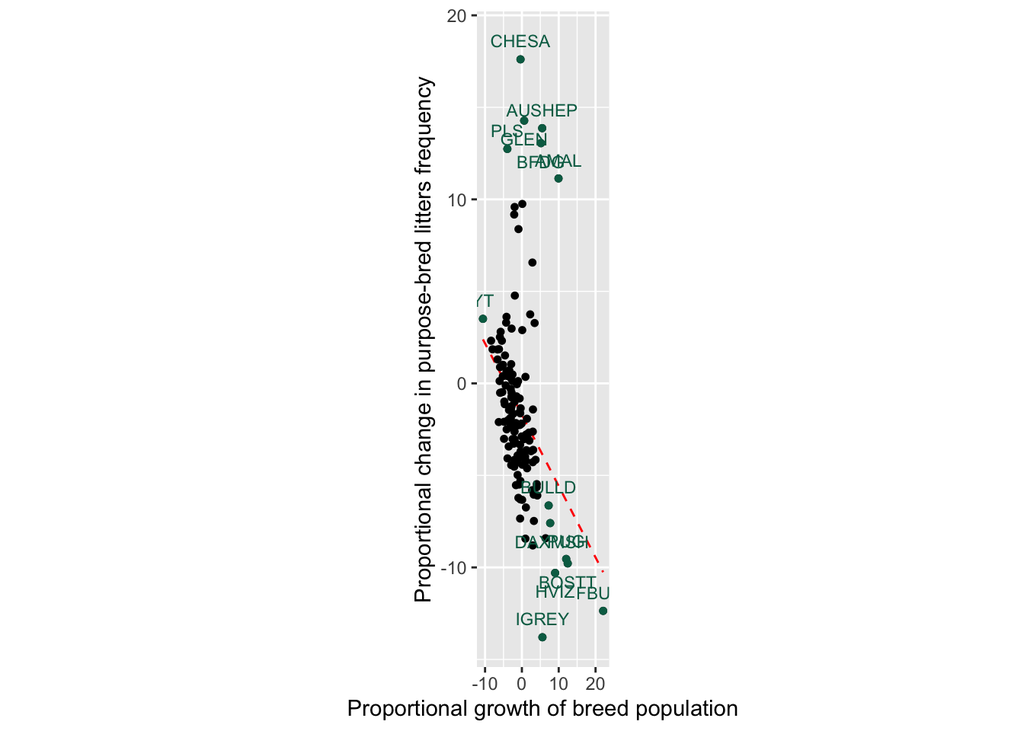

```r
xnud <- c(0,0,0,0,0,0,0.5,0,0,0,0,0,0,0)
ynud <- c(1,1,-1,-1,1,1,-1,1,-1,-1,1,1,1,1)

df4_interest<-df4[df4$breed %in% c('FBULL','YT','HVIZ','IGREY','MARMSH','ACD','AMAL','AUSHEP','BFDG','CHESA','GLEN','PLS','PWD','BOSTT','PUG','BULLD','DAXMSH'),]

ggplot(data=df4,aes(x=pp_popGrowth,y=pp_purpB)) +
  geom_line(aes(y=alin2+blin2*pp_popGrowth),colour="red",linetype="dashed")+
  geom_point(data=df4,aes(x=pp_popGrowth,y=pp_purpB),shape=20,size=2,colour="black")+
  geom_point(data=df4_interest,aes(x=pp_popGrowth,y=pp_purpB),shape=20,size=2,colour=kcgreen)+
  geom_text(data=df4_interest,aes(label=breed),colour=kcgreen,size = 3, nudge_x = xnud, nudge_y = ynud)+
  # geom_point(data=df4_top10,aes(x=pp_popGrowth,y=pp_purpB),shape=20,size=2,colour="blue")+
  # geom_text(data=df4_top10,aes(label=breed),colour="blue",size = 3)+
  xlab("Proportional growth of breed population")+
  ylab("Proportional change in purpose-bred litters frequency")+
  coord_fixed(ratio = 5)
```

```r
ggsave("Fig6_trendsPopGrowth_trendsPBlitters.jpg", device = "jpg")
```

## 4. Imports by country

For each breed, extract the number of imports from specific countries.

```r
# ## Read in the first file
# countries<-read.csv("../../outputs/ACD/out_tables/imports_by_country.csv")
# countries$breed<-'ACD'
#
# ## Loop through remaining folders
# breed_folders <- list.dirs("../../outputs", recursive = FALSE)
# for (b in breed_folders[-1]) {
#   bname=str_split_i(b,'/',-1)
#   ## Read in the number of imports per country for the breed
#   filename=paste0(b,"/","out_tables/imports_by_country.csv")
#   if (file.exists(filename)) {
#     ibc<-read.csv(filename)
#     ibc$breed<-bname
#     ## Merge with the previously added data
#     temp<-rbind(countries,ibc)
#     countries<-temp
#   } else {
#     next
#   }
# }
#
# ## Convert to numeric
# cols.num<-names(countries)[2:3]
# countries[cols.num]<-sapply(countries[cols.num],as.numeric)
#
# ## Save to file
# write.csv(countries, "5_importsCountry.csv", row.names=FALSE)
```

```r
countries<-read.csv("5_importsCountry.csv")
head(countries)
```

```
##   OrigCountry OrigCountry_N OrigCountry_freq breed
## 1   Australia            22       0.26506024   ACD
## 2       Italy            13       0.15662651   ACD
## 3     Germany            10       0.12048193   ACD
## 4     Ireland             6       0.07228916   ACD
## 5         USA             6       0.07228916   ACD
## 6     Finland             5       0.06024096   ACD
```

```r
country_stats<-aggregate(countries$OrigCountry_N, by=list(Country=countries$OrigCountry), FUN=sum)
country_stats<-as.data.frame(country_stats %>% mutate(Perc = x/sum(x)*100))
head(country_stats[order(country_stats$x,decreasing = TRUE),],20)
```

```
##               Country     x      Perc
## 45            Ireland 11577 20.999456
## 83 Russian Federation  4396  7.973880
## 77             Poland  3905  7.083258
## 41            Hungary  3211  5.824415
## 99                USA  3011  5.461636
## 36            Germany  2783  5.048068
## 35             France  2273  4.122982
## 84             Serbia  2015  3.654997
## 47              Italy  1854  3.362960
## 69        Netherlands  1661  3.012879
## 92             Sweden  1607  2.914928
## 9             Belarus  1247  2.261926
## 91              Spain  1234  2.238346
## 10            Belgium  1149  2.084165
## 27     Czech Republic  1149  2.084165
## 97            Ukraine  1106  2.006167
## 59          Lithuania  1066  1.933611
## 34            Finland   747  1.354979
## 3           Australia   730  1.324143
## 29            Denmark   667  1.209868
```

Select countries with >3%, and group the rest for pie chart

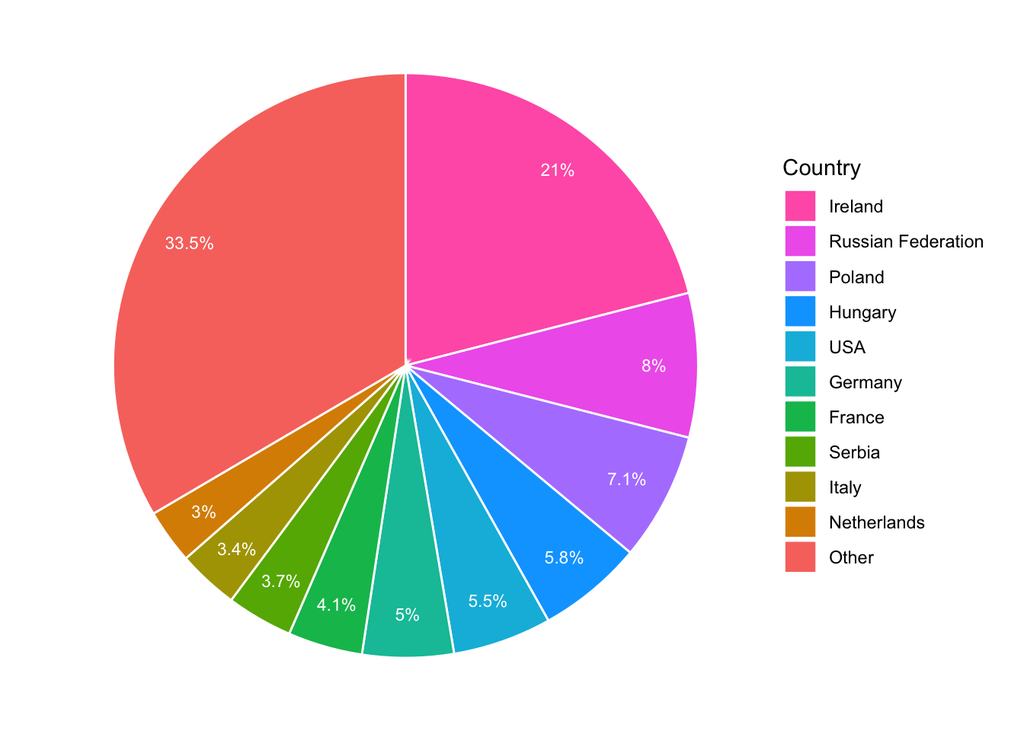

```r
pich<-country_stats[country_stats$Perc>=3,]
pich<-pich[order(pich$Perc,decreasing=TRUE),]
pich[nrow(pich) + 1,]=c('Other',sum(country_stats[country_stats$Perc<3,'x']),sum(country_stats[country_stats$Perc<3,'Perc']))
pich$x<-as.numeric(pich$x)
pich$Perc<-as.numeric(pich$Perc)

## Order the countries
pich$c<-factor(pich$Country, levels = rev(c("Ireland","Russian Federation","Poland","Hungary","USA","Germany","France","Serbia","Italy","Netherlands","Other")))

## Rename the column to avoid confusion when plotting
colnames(pich)[2] <- "N"

## Produce a pie chart with the results.
ggplot(pich,aes(x='',y=Perc,fill=c))+
geom_bar(stat='identity',width=1,color='white')+
  coord_polar("y",start=0)+
  scale_fill_discrete(breaks=c("Ireland","Russian Federation","Poland","Hungary","USA","Germany","France","Serbia","Italy","Netherlands","Other"))+
  geom_text(aes(x=1.35,label = paste0(round(Perc,digits=1), "%")),color='white',position = position_stack(vjust = 0.5), size=3) +
  labs(fill="Country") +
  theme_void()
```

```r
ggsave("Fig7_imps_countries_pie.jpg", device='jpg')
```

Select top 3 countries from each breed.

```r
top3c<-countries %>% group_by(breed) %>% slice(1:3)
## For each country, count how many breeds it appears in as a top 3
top3countries<-top3c %>% group_by(OrigCountry) %>% count()
## Print out the countries which appear in top 3 for most breeds
head(top3countries[order(top3countries$n,decreasing=TRUE),],10)
```

```
## # A tibble: 10 × 2
## # Groups:   OrigCountry [10]
##    OrigCountry            n
##    <chr>              <int>
##  1 Ireland              114
##  2 France                61
##  3 Poland                60
##  4 USA                   55
##  5 Sweden                50
##  6 Germany               46
##  7 Russian Federation    46
##  8 Netherlands           29
##  9 Italy                 26
## 10 Hungary               22
```

As of 2022, imports from Russia are not accepted as a result of Russian invasion on Ukraine. Check breeds with the highest percentage of imports from Russia

```r
rf<-countries[countries$OrigCountry=='Russian Federation',]
rf$p<-round(rf$OrigCountry_freq*100,digits=1)
head(rf[order(rf$OrigCountry_freq, decreasing=TRUE),],15)
```

```
##             OrigCountry OrigCountry_N OrigCountry_freq  breed    p
## 3322 Russian Federation          1131        0.4454510    POM 44.5
## 1401 Russian Federation           165        0.4411765 DAXMLH 44.1
## 4424 Russian Federation            17        0.3863636  XOLOS 38.6
## 3680 Russian Federation            40        0.3361345   RTOY 33.6
## 1465 Russian Federation            89        0.3016949 DAXMWH 30.2
## 2578 Russian Federation            56        0.2871795  JCHIN 28.7
## 2600 Russian Federation            70        0.2713178    JRT 27.1
## 1389 Russian Federation            24        0.2696629  DAXLH 27.0
## 1431 Russian Federation           177        0.2591508 DAXMSH 25.9
## 3575 Russian Federation            55        0.2582160    RBT 25.8
## 3437 Russian Federation            89        0.2445055  POODT 24.5
## 1161 Russian Federation           170        0.2316076   CHOW 23.2
## 2630 Russian Federation            89        0.2276215 JSHIBA 22.8
## 1087 Russian Federation           158        0.2225352 CHIHLC 22.3
## 3377 Russian Federation            71        0.2177914  POODM 21.8
```

## 4.2. Imports over time

Summing imports over all years will provide some information about overall trends. But, looking at trends within breeds, and then running a meta-analysis answers a slightly different question. So, for each breed, extract imports per year, feed those into a table, but also calculate a regression coefficient on the log of the numbers of imports within breed.

```r
# ## Read in the first file
# iby<-read.csv("../../outputs/ACD/out_tables/trends_import.csv")
# colnames(iby)[2] <- 'ACD'
#
# ## Loop through remaining folders
# for (b in breed_folders[-1]) {
#   bname=str_split_i(b,'/',-1)
#   ## From log file, extract the numbers
#   filename=paste0(b,"/","out_tables/trends_import.csv")
#   if (file.exists(filename)) {
#     temp<-read.csv(filename)
#     colnames(temp)[2]<-bname
#     ## Merge with the previously added data
#     temp2<-merge(x=iby,y=temp,by='yob', all=TRUE)
#     iby<-temp2
#   } else {
#     next
#   }
# }
#
# write.csv(iby, "5_import_breed_year.csv", row.names=FALSE)
```

```r
iby<-read.csv("5_import_breed_year.csv")
head(iby)
```

```
##    yob ACD AFF AFG AIRDT AKT AMAL AMCOCK AMWATS ANATOL AUSHEP AUSILK AUT AZWKH
## 1 1900   1   1  10    NA   8   16      6     NA     NA     29     NA   1     4
## 2 1969  NA  NA  NA    NA  NA   NA     NA     NA     NA     NA     NA  NA    NA
## 3 1970  NA  NA  NA    NA  NA   NA     NA     NA     NA     NA     NA  NA    NA
## 4 1971  NA  NA  NA    NA  NA   NA     NA     NA     NA     NA     NA  NA    NA
## 5 1974  NA  NA  NA    NA  NA   NA     NA     NA     NA     NA     NA  NA    NA
## 6 1975  NA  NA  NA    NA  NA   NA     NA     NA     NA     NA     NA  NA    NA
##   BARB BASS BAUC BBDG BC BDA BDF BEAG BEARD BEDLT BERG BFDG BGVG BGVP BICHF
## 1    1   10    3   NA 43   1  NA   19     9     2    1   NA   NA    1    17
## 2   NA   NA   NA   NA NA  NA  NA   NA    NA    NA   NA   NA   NA   NA    NA
## 3   NA   NA   NA   NA NA  NA  NA   NA    NA    NA   NA   NA   NA   NA    NA
## 4   NA   NA   NA   NA NA  NA  NA   NA    NA    NA   NA   NA   NA   NA    NA
## 5   NA   NA   NA   NA NA  NA  NA   NA    NA    NA   NA   NA   NA   NA    NA
## 6   NA   NA   NA   NA NA  NA  NA   NA    NA    NA   NA   NA   NA   NA    NA
##   BLOOD BMD BMH BOLO BORDT BORZ BOSTT BOX BRACC BRD BRITT BSDG BSDL BSDM BSDT
```

[output cut: 104 more lines]

```r
## Replace NAs with 0s.
iby[is.na(iby)] <- 0
## Sum to get the total by year
ibyt<-cbind(iby, total = rowSums(iby[-1],na.rm=TRUE))
## Filter the data to only include dogs born 1990 - 2021
iby90 <- ibyt %>% filter(yob>1989) %>% filter(yob<2022)
## Calculate log
iby90$logt<-log(iby90$total)
```

Fit linear regression

```r
lm_imps <- lm(logt ~ yob,data=iby90)
summary(lm_imps)
```

```
##
## Call:
## lm(formula = logt ~ yob, data = iby90)
##
## Residuals:
##      Min       1Q   Median       3Q      Max
## -0.81852 -0.18209  0.01159  0.26444  0.41732
##
## Coefficients:
##               Estimate Std. Error t value Pr(>|t|)
## (Intercept) -1.788e+02  1.146e+01  -15.61 6.08e-16 ***
## yob          9.267e-02  5.712e-03   16.23  < 2e-16 ***
## ---
## Signif. codes:  0 '***' 0.001 '**' 0.01 '*' 0.05 '.' 0.1 ' ' 1
##
## Residual standard error: 0.2983 on 30 degrees of freedom
## Multiple R-squared:  0.8977, Adjusted R-squared:  0.8943
## F-statistic: 263.3 on 1 and 30 DF,  p-value: < 2.2e-16
```

```r
antilog = exp(coef(lm_imps)["yob"])
pp = antilog*100-100
pp
```

```
##     yob
## 9.71046
```

**population of imports increased by 10% every year**

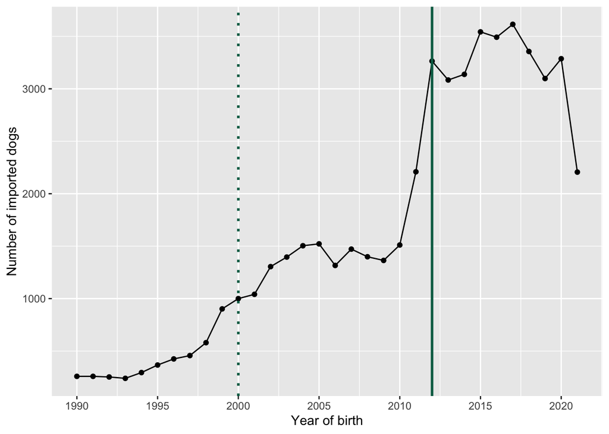

```r
ggplot(iby90,aes(yob,total)) +
  geom_point()+
  geom_line()+
  geom_vline(xintercept = 2012,color = kcgreen, linewidth=1)+
  geom_vline(xintercept = 2000, linetype="dotted", color = kcgreen, linewidth=1)+
  ylab("Number of imported dogs")+
  xlab("Year of birth")+
  scale_x_continuous(breaks = round(seq(1990, 2021, by = 5),1))
```

```r
ggsave("Fig8_imp_trend.jpg", device='jpg')
```

Calculate % increase between 2012 and 2010

```r
i1=iby90 %>% filter(yob==2010) %>% select(total)
i2=iby90 %>% filter(yob==2012) %>% select(total)
(i2-i1)/i1*100
```

```
##      total
## 1 116.0159
```

Run regression for each breed - only for breeds which were first registered after 1990 - for these breeds, 0 imports for early years is pointless as the breed “didn’t exist” in UK at the time.

```r
## Read in the file with the more recent breeds
# recent<-read.csv("post1990_breeds.csv")
# rb<-recent$breed
#
# imreg <- data.frame(matrix(ncol = 5, nrow = 0))
# colnames(imreg) <- c("breed","b","se","p","pp")
#
# for (b in breed_folders) {
#   bname=str_split_i(b,'/',-1)
#
#   if (bname %in% rb) {
#     next
#   } else {
#     ## Extract the year and number of imports
#     temp<-iby90 %>% select(yob,all_of(bname))
#     colnames(temp)<-c('yob','n_imp')
#
#     ## Add increment +1 to avoid issues with n=0
#     temp$n_imp<-temp$n_imp+1
#
#     ## Calculate log of the import numbers
#     temp$logi<-log(temp$n_imp)
#
#     ## Run regression
#     regl<-lm(logi ~ yob, data=temp)
#     lb = summary(regl)$coefficients [2,1]
#     lse = summary(regl)$coefficients [2,2]
#     lp = summary(regl)$coefficients [2,4]
#     antilog = exp(lb)
#     pp = antilog*100-100
#
#     ## Add results to frame
#     imreg[nrow(imreg) + 1,] = c(bname,lb,lse,lp,pp)
#   }
# }
# ## Convert to numeric
# cols.num<-names(imreg)[2:5]
# imreg[cols.num]<-sapply(imreg[cols.num],as.numeric)
#
# write.csv(imreg,"5_imports_trends.csv", row.names=FALSE)
```

```r
imreg<-read.csv("5_imports_trends.csv")
head(imreg)
```

```
##   breed          b          se            p       pp
## 1   ACD 0.04016509 0.009121316 1.247297e-04 4.098261
## 2   AFF 0.05053209 0.013083261 5.566240e-04 5.183062
## 3   AFG 0.03751803 0.008738668 1.695690e-04 3.823071
## 4 AIRDT 0.02705056 0.009721697 9.239817e-03 2.741975
## 5   AKT 0.06534067 0.008926438 3.751489e-08 6.752264
## 6  AMAL 0.05518707 0.006460981 1.570355e-09 5.673828
```

Some summary statistics for the trend within breeds

```r
summary(imreg$pp)
```

```
##    Min. 1st Qu.  Median    Mean 3rd Qu.    Max.
## -0.8313  3.7895  5.6551  6.3715  8.5746 23.6377
```

Check breeds with a significant negative trend

```r
imreg %>% filter(p<0.05) %>% summary(pp)
```

```
##     breed                 b                 se                 p
##  Length:145         Min.   :0.02138   Min.   :0.005784   Min.   :0.000e+00
##  Class :character   1st Qu.:0.04785   1st Qu.:0.009375   1st Qu.:0.000e+00
##  Mode  :character   Median :0.06386   Median :0.010389   Median :7.500e-07
##                     Mean   :0.06957   Mean   :0.010682   Mean   :1.763e-03
##                     3rd Qu.:0.08445   3rd Qu.:0.011936   3rd Qu.:2.102e-04
##                     Max.   :0.21219   Max.   :0.019945   Max.   :3.725e-02
##        pp
##  Min.   : 2.161
##  1st Qu.: 4.901
##  Median : 6.594
##  Mean   : 7.261
##  3rd Qu.: 8.812
##  Max.   :23.638
```

```r
imreg %>% filter(p<0.05) %>% slice(which.min(pp))
```

```
##   breed          b          se         p       pp
## 1    TT 0.02137584 0.009561359 0.0329667 2.160594
```

```r
imreg %>% filter(p<0.05) %>% slice(which.max(pp))
```

```
##   breed         b         se           p       pp
## 1 FBULL 0.2121851 0.01994527 1.06195e-11 23.63768
```

Run meta-analysis

```r
m.imp <- metagen(TE = b,
                 seTE = se,
                 studlab = breed,
                 data = imreg,
                 sm = "SMD",
                 fixed = FALSE,
                 random = TRUE,
                 method.tau = "REML",
                 hakn = TRUE,
                 title = "Imports")
summary(m.imp)
```

```
## Review:     Imports
##
##              SMD            95%-CI %W(random)
## ACD       0.0402 [ 0.0223; 0.0580]        0.6
## AFF       0.0505 [ 0.0249; 0.0762]        0.6
## AFG       0.0375 [ 0.0204; 0.0546]        0.6
## AIRDT     0.0271 [ 0.0080; 0.0461]        0.6
## AKT       0.0653 [ 0.0478; 0.0828]        0.6
## AMAL      0.0552 [ 0.0425; 0.0679]        0.6
## AMCOCK    0.0572 [ 0.0425; 0.0719]        0.6
## ANATOL   -0.0022 [-0.0235; 0.0190]        0.6
## AUSHEP    0.0903 [ 0.0743; 0.1063]        0.6
## AUSILK    0.0091 [-0.0142; 0.0324]        0.6
## AUT       0.0134 [-0.0075; 0.0343]        0.6
## BASS      0.0780 [ 0.0578; 0.0982]        0.6
## BC        0.0833 [ 0.0633; 0.1032]        0.6
## BDF       0.0359 [ 0.0124; 0.0595]        0.6
## BEAG      0.0821 [ 0.0617; 0.1025]        0.6
## BEARD     0.0825 [ 0.0660; 0.0990]        0.6
## BEDLT     0.0494 [ 0.0253; 0.0736]        0.6
## BFDG      0.0490 [ 0.0278; 0.0701]        0.6
## BGVG      0.0126 [-0.0113; 0.0364]        0.6
## BGVP     -0.0006 [-0.0210; 0.0198]        0.6
## BICHF     0.0613 [ 0.0360; 0.0867]        0.6
## BLOOD     0.0292 [ 0.0029; 0.0554]        0.6
## BMD       0.0938 [ 0.0802; 0.1073]        0.6
## BOLO      0.0452 [ 0.0205; 0.0699]        0.6
## BORDT     0.0769 [ 0.0532; 0.1006]        0.6
## BORZ      0.0823 [ 0.0610; 0.1037]        0.6
## BOSTT     0.0977 [ 0.0761; 0.1193]        0.6
## BOX       0.0772 [ 0.0556; 0.0987]        0.6
## BRD       0.0461 [ 0.0242; 0.0681]        0.6
## BRITT     0.0008 [-0.0213; 0.0229]        0.6
## BSDG      0.0304 [ 0.0080; 0.0529]        0.6
## BSDL      0.0220 [ 0.0074; 0.0365]        0.6
## BSDM      0.0767 [ 0.0580; 0.0954]        0.6
## BSDT      0.0161 [-0.0038; 0.0361]        0.6
## BSNJI     0.0820 [ 0.0639; 0.1001]        0.6
## BULLD     0.1382 [ 0.1128; 0.1636]        0.6
## BULLM     0.0814 [ 0.0588; 0.1041]        0.6
```

[output cut: 136 more lines]

```
## Random effects model (HK) 0.0609 [0.0554; 0.0664] 21.79 < 0.0001
##
## Quantifying heterogeneity:
##  tau^2 = 0.0012 [0.0009; 0.0015]; tau = 0.0344 [0.0307; 0.0393]
##  I^2 = 92.0% [91.1%; 92.8%]; H = 3.54 [3.36; 3.73]
##
## Test of heterogeneity:
##        Q d.f. p-value
##  2106.89  168       0
##
## Details on meta-analytical method:
## - Inverse variance method
## - Restricted maximum-likelihood estimator for tau^2
## - Q-Profile method for confidence interval of tau^2 and tau
## - Hartung-Knapp adjustment for random effects model (df = 168)
```

```r
print("Growth rate in import population from 1990, using REML with Hartung-Knapp adjustment")
```

```
## [1] "Growth rate in import population from 1990, using REML with Hartung-Knapp adjustment"
```

```r
e<-round(exp(m.imp$TE.random)*100-100,digits=1)
ci_low<-round(exp(m.imp$lower.random)*100-100,digits=1)
ci_upp<-round(exp(m.imp$upper.random)*100-100,digits=1)

print(paste0("Yearly change of ", e, "% (95% CI: ", ci_low,"% to ", ci_upp,"%)"))
```

```
## [1] "Yearly change of 6.3% (95% CI: 5.7% to 6.9%)"
```

```r
meta_limit_breeds_growth(m.imp)
```

```
## [1] "Largest decline in NORWELK at -0.8% (95% CI: -3.6% to 2%)"
## [1] "Largest growth in FBULL at 23.6% (95% CI: 18.9% to 28.6%)"
```

### 4.3 Imports in breeding

The data is limited to litters born since 2013. The number of imports spiked in 2012 due to changes in legislation, allowing import of 15 week old puppies (previously min age >8 months). Starting from 2013 and not 2012, as many dogs in 2012 would be too young to be bred from.

NOTE - following discussion, I’ve added also examination of the trend 1990-2012. See import_addendum_1990-2012.Rmd

#### Function to read data

Function to produce the input table for regression. Filters out litters born before 2013

```r
prep_impBdf <-function(breed){
  ## Read raw data for litters
  df<-read.csv(paste0("../../outputs/",breed,"/out_tables/litter_stats.csv"))
  ## Filter out litters before 2013
  df<-df[df$yob>2012,]
  ## Filter out litters born after 2021
  df<-df[df$yob<2022,]
  ## Group by year and litter category, count
  temp <- df %>% group_by(yob, ImportBred) %>% summarise(total_count=n(),.groups = 'drop') %>% as.data.frame()
  ## Reshape table
  df1 <- temp %>% pivot_wider(names_from = c(ImportBred), values_from = c(total_count)) %>% as.data.frame()
  ## Fill na's with 0s
  df1[is.na(df1)] <- 0

  ## Calculate proportion
  if("ImportBred" %in% colnames(df1))
  {
    if("National" %in% colnames(df1)) {
      df1$n<-df1$ImportBred+df1$National
      df1$prop <- df1$ImportBred/(df1$ImportBred+df1$National)
    } else {
      df1$n<-df1$ImportBred
      df1$prop <- 1
    }

  }
  df<-df1
}
```

#### Betaregression function

Function for the regression coefficient. Note, this will use a model with fixed dispersion and logit link function. I am also weighing the records. **May need updating!**

Also extract the number of years, min litters per year, number of years with 0 litters, number of litters total, and number of import-bred litters. Will need to filter breeds out before meta-analysis.

```r
regress_impB<-function(df,breed) {
  ## If importBred litters found:
  if("ImportBred" %in% colnames(df1))
  {
    if("National" %in% colnames(df1))
    {
      ## Transform data
      df$prop_trans<-(df$prop*(df$n-1)+0.5)/df$n
      ## Convert yob to numeric from 1 (1990) to 32 (2021)
      df$y<-df$yob-1989
      ntot = sum(df$n)
      min_litters=min(df$n)
      nIB = sum(df$ImportBred)
      nyears=nrow(df)
      n0years=nrow(df[df$yob==0,])

      tryCatch(
        expr = {
          bregt<-betareg(prop_trans ~ y, data=df)
          b=summary(bregt)$coef$mean[2,1]
          se=summary(bregt)$coef$mean[2,2]
          return(c(breed,nyears,n0years,min_litters,ntot,nIB,b,se))
        },
        error = function(e){
          return(c(breed,nyears,n0years,min_litters,ntot,nIB,NA,NA))
        }
      )
    } else {
      ntot=sum(df$ImportBred)
      min_litters=min(df$ImportBred)
      nIB=sum(df$ImportBred)
      nyears=nrow(df)
      n0years=nrow(df[df$yob==0,])
      return(c(breed,nyears,n0years,min_litters,ntot,nIB,NA,NA))
    }
  } else {
    #print("No regression calculated")
    ntot=sum(df$National)
    min_litters=min(df$National)
    nyears=nrow(df)
    n0years=nrow(df[df$yob==0,])
    return(c(breed,nyears,n0years,min_litters,ntot,NA,NA,NA))
  }
}
```

Run for all breeds

```r
# trends_impB<-data.frame(breed=NA,n_years=NA,n0years=NA,min_litters=NA,n_litters=NA,n_impB=NA,b=NA,SE=NA)
#
# breed_folders <- list.dirs("../../outputs", recursive = FALSE)
#
# #for (b in breed_folders[1:5]) {
# for (bf in breed_folders) {
#   breed=str_split_i(bf,'/',-1)
#   filename=paste0("../../outputs/",breed,"/out_tables/litter_stats.csv")
#   if (file.exists(filename)) {
#     df1<-prep_impBdf(breed)
#     if(nrow(df1)>0) {
#       resrow<-regress_impB(df1,breed)
#       trends_impB[nrow(trends_impB) + 1,] = resrow
#     } else {
#       trends_impB[nrow(trends_impB) + 1,] = c(breed,0,0,0,0,0,NA,NA)
#     }
#   } else {
#     trends_impB[nrow(trends_impB) + 1,] = c(breed,0,0,0,0,0,NA,NA)
#   }
# }
#
# ## Remove the first empty row
# trends_impB<-trends_impB[!is.na(trends_impB$breed),]
#
# ## Replace the missing values in number of purpose bred litters
# trends_impB$n_impB[is.na(trends_impB$n_impB)] <- 0
#
#
# ## Convert to numeric
# cols.num<-names(trends_impB)[2:8]
# trends_impB[cols.num]<-sapply(trends_impB[cols.num],as.numeric)
#
# write.csv(trends_impB,"5b_imports_trends_in_breeding.csv", row.names=FALSE)
```

```r
trends_impB<-read.csv("5b_imports_trends_in_breeding.csv")
head(trends_impB)
```

```
##   breed n_years n0years min_litters n_litters n_impB          b         SE
## 1   ACD       9       0           5        77     47 0.10507179 0.06763158
## 2   AFF       9       0          21       269     75 0.30601617 0.05798693
## 3   AFG       9       0           7       115     51 0.15991084 0.05232987
## 4 AIRDT       9       0          66       748     62 0.04504266 0.07051624
## 5   AKT       9       0          28       541    114 0.20411059 0.05237062
## 6  AMAL       9       0          42       666    186 0.16441796 0.01817288
```

```r
## Calculate the expected proportion
trends_impB$pp_impB<-exp(trends_impB$b)*100-100
```

Summarise breeds entirely bred from imports - those will not have b!

```r
trends_impB %>% filter(n_litters==n_impB) %>% filter(n_litters>0)
```

```
##     breed n_years n0years min_litters n_litters n_impB  b SE pp_impB
## 1   AZWKH       3       0           1         3      3 NA NA      NA
## 2    BBDG       5       0           1         6      6 NA NA      NA
## 3     BDA       7       0           1        11     11 NA NA      NA
## 4    BERG       4       0           1         6      6 NA NA      NA
## 5    BSDL       4       0           1         5      5 NA NA      NA
## 6  GREEND       5       0           1         6      6 NA NA      NA
## 7   PICSH       5       0           1         6      6 NA NA      NA
## 8    WSSD       4       0           4        42     42 NA NA      NA
## 9   XOLOI       7       0           1        12     12 NA NA      NA
## 10  XOLOS       8       0           1        20     20 NA NA      NA
```

Filter out breeds which didn’t have 9 years covered

```r
df<-trends_impB[trends_impB$n_years==9,]
print(paste0("Retained ",nrow(df)," breeds with some litters across whole period"))
```

```
## [1] "Retained 186 breeds with some litters across whole period"
```

```r
df<-trends_impB[trends_impB$min_litters>2,]
df<-df[df$n_years==9,]
print(paste0("Retained ",nrow(df)," breeds with at least 3 litters across whole period"))
```

```
## [1] "Retained 171 breeds with at least 3 litters across whole period"
```

Check that all breeds have b calculated

```r
df[is.na(df$b),]
```

```
## [1] breed       n_years     n0years     min_litters n_litters   n_impB
## [7] b           SE          pp_impB
## <0 rows> (or 0-length row.names)
```

Merge with the pedsize data

```r
df2<-merge(x=df,y=pedsize,by='breed', all=FALSE)
df2$pp_ib<-exp(df2$b)*100-100
head(df2)
```

```
##   breed n_years n0years min_litters n_litters n_impB          b         SE
## 1   ACD       9       0           5        77     47 0.10507179 0.06763158
## 2   AFF       9       0          21       269     75 0.30601617 0.05798693
## 3   AFG       9       0           7       115     51 0.15991084 0.05232987
## 4 AIRDT       9       0          66       748     62 0.04504266 0.07051624
## 5   AKT       9       0          28       541    114 0.20411059 0.05237062
## 6  AMAL       9       0          42       666    186 0.16441796 0.01817288
##     pp_impB ped_size  Breg National yr_first yr_last n1990        logN_b
## 1 11.079035     3125  1812     1605     1990    2021    10  0.0257377565
## 2 35.800426     4513  3550     3396     1990    2021    85  0.0009636883
## 3 17.340625    38071  7690     7007     1990    2021   424 -0.0648182660
## 4  4.607249    50056 27005    26692     1990    2021  1241 -0.0237539613
## 5 22.643377    33989 29105    28642     1990    2021   589 -0.0469511208
## 6 17.870687    18755 15515    14917     1990    2021    71  0.0947889653
##       logN_SE       logN_p      expB          pp     pp_ib
## 1 0.009593363 1.175883e-02 1.0260718  2.60718325 11.079035
## 2 0.005787637 8.688743e-01 1.0009642  0.09641528 35.800426
## 3 0.004893578 4.551147e-14 0.9372378 -6.27622241 17.340625
## 4 0.002533876 2.014199e-10 0.9765259 -2.34740567  4.607249
## 5 0.011236968 2.334370e-04 0.9541340 -4.58659663 22.643377
## 6 0.017773256 9.090222e-06 1.0994268  9.94268134 17.870687
```

Calculate the overall proportion of import-bred litters for the breeds where at least 1 imported litter was found.

```r
df2$tot_prop<-df2$n_impB/df2$n_litters
head(df2[order(df2$tot_prop, decreasing=FALSE),c('breed','tot_prop')],5)
```

```
##     breed   tot_prop
## 24  BORDT 0.02720121
## 64    ECS 0.03521876
## 111 LHASA 0.03689032
## 106   LAB 0.04099558
## 166  WHIP 0.04216524
```

Highest proportions

```r
head(df2[order(df2$tot_prop, decreasing=TRUE),c('breed','tot_prop')],5)
```

```
##       breed  tot_prop
## 170   XOLOM 0.8723404
## 154    SRHP 0.7750000
## 116  MARMSH 0.7708333
## 160 TIBMAST 0.7669903
## 40     CATS 0.7500000
```

Simple count and proportion of all litters.

```r
sum(df2$n_litters)
```

```
## [1] 418543
```

```r
sum(df2$n_impB)
```

```
## [1] 53317
```

```r
round(sum(df2$n_impB)/sum(df2$n_litters)*100,digits=1)
```

```
## [1] 12.7
```

Run meta-analysis to get the overall percentage:

```r
m.oaprop <- metaprop(event = n_impB,
                   n = n_litters,
                   studlab = breed,
                   data = df2,
                   method = "GLMM",
                   sm = "PLOGIT",
                   fixed = FALSE,
                   random = TRUE,
                   hakn = TRUE,
                   title = "Proportion import-bred litters")
summary(m.oaprop)
```

```
## Review:     Proportion import-bred litters
##
##            proportion           95%-CI
## ACD            0.6104 [0.4925; 0.7195]
## AFF            0.2788 [0.2261; 0.3365]
## AFG            0.4435 [0.3509; 0.5391]
## AIRDT          0.0829 [0.0641; 0.1050]
## AKT            0.2107 [0.1771; 0.2475]
## AMAL           0.2793 [0.2455; 0.3150]
## AMCOCK         0.4525 [0.4060; 0.4997]
## AUSHEP         0.5488 [0.4843; 0.6121]
## AUT            0.3148 [0.1952; 0.4555]
## BASS           0.2432 [0.2135; 0.2750]
## BC             0.0676 [0.0604; 0.0755]
## BDF            0.5152 [0.3888; 0.6401]
## BEAG           0.1241 [0.1137; 0.1352]
## BEARD          0.2356 [0.1993; 0.2751]
## BEDLT          0.0580 [0.0432; 0.0759]
## BFDG           0.4539 [0.3699; 0.5398]
## BGVG           0.5934 [0.4853; 0.6952]
## BGVP           0.2680 [0.2071; 0.3362]
## BICHF          0.0730 [0.0610; 0.0866]
## BLOOD          0.4487 [0.3359; 0.5656]
## BMD            0.3541 [0.3216; 0.3877]
## BMH            0.4026 [0.2923; 0.5206]
## BOLO           0.4938 [0.4290; 0.5587]
## BORDT          0.0272 [0.0242; 0.0305]
## BORZ           0.3615 [0.2791; 0.4504]
## BOSTT          0.1090 [0.0993; 0.1193]
## BOX            0.1278 [0.1192; 0.1367]
## BRACC          0.6933 [0.6129; 0.7659]
## BRD            0.3385 [0.2578; 0.4266]
## BRITT          0.2190 [0.1529; 0.2976]
## BSDG           0.6154 [0.4864; 0.7335]
## BSDM           0.3449 [0.2901; 0.4031]
## BSDT           0.2936 [0.2102; 0.3885]
## BSNJI          0.7188 [0.6178; 0.8058]
## BULLD          0.1297 [0.1247; 0.1347]
## BULLM          0.2129 [0.1840; 0.2442]
## BULLT          0.0706 [0.0616; 0.0806]
```

[output cut: 141 more lines]

```
##
## Quantifying heterogeneity:
##  tau^2 = 1.1156; tau = 1.0562; I^2 = 99.5%; H = 14.14
##
## Test of heterogeneity:
##              Q d.f. p-value
##  Wald 33990.45  170       0
##  LRT  38322.11  170       0
##
## Details on meta-analytical method:
## - Random intercept logistic regression model
## - Maximum-likelihood estimator for tau^2
## - Random effects confidence interval based on t-distribution (df = 170)
## - Logit transformation
## - Clopper-Pearson confidence interval for individual studies
```

Run meta-analysis for the top 10 breeds only.

```r
df2$propImpB<-df2$n_impB/df2$n_litters*100
top10<-df2[df2$breed %in% c('LAB','FBULL','ECS','BULLD','DAXMSH','ESS','GOLD','GSD','STAFF','PUG'),]

mpropIBTot10 <- metaprop(event = n_impB,
                   n = n_litters,
                   studlab = breed,
                   data = top10,
                   method = "GLMM",
                   sm = "PLOGIT",
                   fixed = FALSE,
                   random = TRUE,
                   hakn = TRUE,
                   title = "ProportionSBN litters")
summary(mpropIBTot10)
```

```
## Review:     ProportionSBN litters
##
##        proportion           95%-CI
## BULLD      0.1297 [0.1247; 0.1347]
## DAXMSH     0.1177 [0.1126; 0.1229]
## ECS        0.0352 [0.0335; 0.0370]
## ESS        0.0494 [0.0460; 0.0530]
## FBULL      0.1551 [0.1520; 0.1583]
## GOLD       0.1272 [0.1207; 0.1338]
## GSD        0.2623 [0.2538; 0.2708]
## LAB        0.0410 [0.0393; 0.0428]
## PUG        0.0725 [0.0688; 0.0764]
## STAFF      0.0633 [0.0582; 0.0687]
##
## Number of studies: k = 10
## Number of observations: o = 237518
## Number of events: e = 22091
##
##                      proportion           95%-CI
## Random effects model     0.0892 [0.0564; 0.1381]
##
## Quantifying heterogeneity:
##  tau^2 = 0.4734; tau = 0.6880; I^2 = 99.9%; H = 31.10
##
## Test of heterogeneity:
##             Q d.f. p-value
##  Wald 8702.24    9       0
##  LRT  9662.92    9       0
##
## Details on meta-analytical method:
## - Random intercept logistic regression model
## - Maximum-likelihood estimator for tau^2
## - Random effects confidence interval based on t-distribution (df = 9)
## - Logit transformation
## - Clopper-Pearson confidence interval for individual studies
```

Trends in the proportion of litters

```r
metaIBtrend_all <- metagen(TE = b,
                 seTE = SE,
                 studlab = breed,
                 data = df2,
                 sm = "SMD",
                 fixed = FALSE,
                 random = TRUE,
                 method.tau = "REML",
                 hakn = TRUE,
                 title = "Trend in impBred")

summary(metaIBtrend_all)
```

```
## Review:     Trend in impBred
##
##                SMD             95%-CI %W(random)
## ACD         0.1051 [-0.0275;  0.2376]        0.5
## AFF         0.3060 [ 0.1924;  0.4197]        0.6
## AFG         0.1599 [ 0.0573;  0.2625]        0.6
## AIRDT       0.0450 [-0.0932;  0.1833]        0.5
## AKT         0.2041 [ 0.1015;  0.3068]        0.6
## AMAL        0.1644 [ 0.1288;  0.2000]        0.7
## AMCOCK      0.1913 [ 0.1329;  0.2496]        0.7
## AUSHEP     -0.0912 [-0.1823; -0.0000]        0.6
## AUT         0.0852 [-0.0756;  0.2460]        0.5
## BASS        0.0301 [-0.0386;  0.0989]        0.6
## BC          0.0613 [ 0.0356;  0.0869]        0.7
## BDF         0.2232 [ 0.0337;  0.4127]        0.4
## BEAG        0.0788 [ 0.0289;  0.1286]        0.7
## BEARD       0.1300 [ 0.0788;  0.1812]        0.7
## BEDLT       0.3467 [ 0.2056;  0.4877]        0.5
## BFDG       -0.0791 [-0.2468;  0.0887]        0.4
## BGVG       -0.1196 [-0.2599;  0.0208]        0.5
## BGVP        0.0866 [ 0.0045;  0.1687]        0.6
## BICHF       0.0746 [ 0.0041;  0.1451]        0.6
## BLOOD      -0.0200 [-0.1528;  0.1128]        0.5
## BMD         0.1657 [ 0.0867;  0.2447]        0.6
## BMH         0.2687 [ 0.1186;  0.4188]        0.5
## BOLO        0.0848 [-0.0135;  0.1831]        0.6
## BORDT       0.1177 [ 0.0501;  0.1853]        0.6
## BORZ       -0.0800 [-0.1844;  0.0244]        0.6
## BOSTT      -0.0729 [-0.1161; -0.0297]        0.7
## BOX         0.1442 [ 0.1031;  0.1854]        0.7
## BRACC      -0.1796 [-0.3199; -0.0393]        0.5
## BRD        -0.1712 [-0.3420; -0.0004]        0.4
## BRITT       0.0070 [-0.1200;  0.1339]        0.5
## BSDG        0.1845 [-0.0262;  0.3952]        0.4
## BSDM        0.0249 [-0.0878;  0.1376]        0.6
## BSDT       -0.1030 [-0.2271;  0.0211]        0.5
## BSNJI       0.1079 [-0.0310;  0.2467]        0.5
## BULLD      -0.0034 [-0.0960;  0.0893]        0.6
## BULLM       0.1231 [ 0.0563;  0.1898]        0.6
## BULLT       0.1071 [ 0.0536;  0.1605]        0.7
```

[output cut: 138 more lines]

```
## Random effects model (HK) 0.0804 [0.0616; 0.0991] 8.45 < 0.0001
##
## Quantifying heterogeneity:
##  tau^2 = 0.0126 [0.0101; 0.0171]; tau = 0.1122 [0.1006; 0.1307]
##  I^2 = 91.0% [89.9%; 91.9%]; H = 3.33 [3.15; 3.52]
##
## Test of heterogeneity:
##        Q d.f.  p-value
##  1882.68  170 < 0.0001
##
## Details on meta-analytical method:
## - Inverse variance method
## - Restricted maximum-likelihood estimator for tau^2
## - Q-Profile method for confidence interval of tau^2 and tau
## - Hartung-Knapp adjustment for random effects model (df = 170)
```

INTERPRETATION: The proportion of litters bred after imported parents increased yearly by

```r
e<-round(exp(metaIBtrend_all$TE.random)*100-100,digits=1)
ci_low<-round(exp(metaIBtrend_all$lower.random)*100-100,digits=1)
ci_upp<-round(exp(metaIBtrend_all$upper.random)*100-100,digits=1)

print(paste0("Yearly change of ", e, "% (95% CI: ", ci_low,"% to ", ci_upp,"%)"))
```

```
## [1] "Yearly change of 8.4% (95% CI: 6.4% to 10.4%)"
```

```r
meta_limit_breeds_growth(metaIBtrend_all)
```

```
## [1] "Largest decline in FBULL at -31.3% (95% CI: -35.9% to -26.5%)"
## [1] "Largest growth in JRT at 55.5% (95% CI: 27.5% to 89.6%)"
```

Plot the distribution of the trends

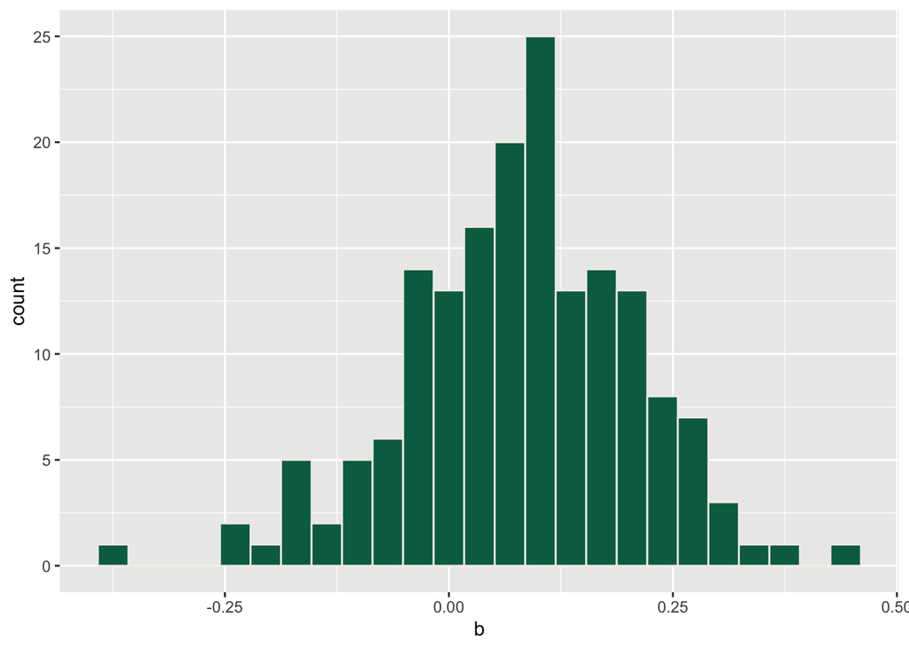

```r
ggplot(df2, aes(x=b)) +
    geom_histogram(colour=kcoat, fill=kcgreen,bins=25)
```

Highest and lowest trends

```r
df2[order(df2$pp_ib, decreasing=TRUE),c('breed','n_litters','pp_ib')]
```

```
##          breed n_litters        pp_ib
## 99         JRT       318  55.49454524
## 38      BULLTM       406  47.80320544
## 15       BEDLT       845  41.43503968
## 156      STAFF      8479  36.99401941
## 2          AFF       269  35.80042615
## 44      CHIHLC      5008  34.90135219
## 133        POM      3838  32.51434525
## 79       GSCHN       257  32.30874469
## 56      DAXMLH      3124  31.81976392
## 22         BMH        77  30.82571774
## 103        KCS       330  30.45621144
## 171         YT      2655  30.23284227
## 43       CHESA        92  30.23060122
## 100     JSHIBA       799  28.43553656
```

[output cut: 157 more lines]

```r
df2[order(df2$pp_ib, decreasing=FALSE),c('breed','n_litters','pp_ib')]
```

```
##          breed n_litters        pp_ib
## 69       FBULL     50982 -31.34840179
## 154       SRHP        40 -21.27745073
## 51       COTON       649 -21.27713207
## 72       FLAPP       133 -19.55413360
## 50       COLLS       138 -16.89051362
## 93       ISPIN       532 -16.69149361
## 28       BRACC       150 -16.44027336
## 29         BRD       130 -15.73749165
## 67       ETOYT       253 -15.07150777
## 123    NORWELK        83 -13.70223013
## 17        BGVG        91 -11.27144792
## 87       HPULI        65 -10.40711376
## 33        BSDT       109  -9.79007639
## 101     JSPITZ       406  -9.74611250
```

[output cut: 157 more lines]

Trends in top 10

```r
metaIBtrend_top10 <- metagen(TE = b,
                 seTE = SE,
                 studlab = breed,
                 data = top10,
                 sm = "SMD",
                 fixed = FALSE,
                 random = TRUE,
                 method.tau = "REML",
                 hakn = TRUE,
                 title = "Trend in impBred")

summary(metaIBtrend_top10)
```

```
## Review:     Trend in impBred
##
##            SMD             95%-CI %W(random)
## BULLD  -0.0034 [-0.0960;  0.0893]        9.5
## DAXMSH  0.1211 [ 0.0447;  0.1976]        9.8
## ECS     0.0826 [ 0.0537;  0.1116]       10.2
## ESS     0.0865 [ 0.0600;  0.1130]       10.2
## FBULL  -0.3761 [-0.4441; -0.3081]        9.9
## GOLD    0.0808 [ 0.0602;  0.1015]       10.2
## GSD     0.1485 [ 0.1270;  0.1699]       10.2
## LAB     0.0894 [ 0.0631;  0.1158]       10.2
## PUG    -0.0303 [-0.0483; -0.0124]       10.2
## STAFF   0.3148 [ 0.2186;  0.4109]        9.5
##
## Number of studies: k = 10
##
##                              SMD            95%-CI    t p-value
## Random effects model (HK) 0.0510 [-0.0740; 0.1760] 0.92  0.3800
##
## Quantifying heterogeneity:
##  tau^2 = 0.0291 [0.0133; 0.1025]; tau = 0.1707 [0.1155; 0.3201]
##  I^2 = 97.5% [96.6%; 98.2%]; H = 6.39 [5.45; 7.48]
##
## Test of heterogeneity:
##       Q d.f.  p-value
##  367.10    9 < 0.0001
##
## Details on meta-analytical method:
## - Inverse variance method
## - Restricted maximum-likelihood estimator for tau^2
## - Q-Profile method for confidence interval of tau^2 and tau
## - Hartung-Knapp adjustment for random effects model (df = 9)
```

```r
e<-round(exp(metaIBtrend_top10$TE.random)*100-100,digits=1)
ci_low<-round(exp(metaIBtrend_top10$lower.random)*100-100,digits=1)
ci_upp<-round(exp(metaIBtrend_top10$upper.random)*100-100,digits=1)

print(paste0("Yearly change of ", e, "% (95% CI: ", ci_low,"% to ", ci_upp,"%)"))
```

```
## [1] "Yearly change of 5.2% (95% CI: -7.1% to 19.2%)"
```

```r
meta_limit_breeds_growth(metaIBtrend_top10)
```

```
## [1] "Largest decline in FBULL at -31.3% (95% CI: -35.9% to -26.5%)"
## [1] "Largest growth in STAFF at 37% (95% CI: 24.4% to 50.8%)"
```

### 5. Sires - general comparisons

Sires grouped into categories, and pairwise comparisons carried out to find SMD in the number of litters. SMD is calculated by meta package directly from the following: - n.e. - number of observations in the treatment group (i.e. imports, SBNs etc) - mean number of litters in the experimental group - SD of mean number of litters in the experimental group - n.c. - number of observations in control group (e.g. if treatment was import, then control is national) - mean number of litters in the control group - SD of mean number of litters in the control group

```r
# read_sireCat <-function(Breed){
#   ## Read the file
#   df<-read_csv(paste0("../../outputs/",Breed,"/out_tables/sireCat_stats.csv"),show_col_types = FALSE)
#   ## Keep only the n_litters
#   df<-df[df$variable=='n_litters',]
#   ## Add a breed column
#   df$breed<-rep(Breed,nrow(df))
#
#   df
# }
#
# ## Function for reading p-values
# read_pvals<-function(Breed) {
#   ## Reading p-values
#   dfp<-read_csv(paste0("../../outputs/",Breed,"/out_tables/sireCat_pvals.csv"),show_col_types = FALSE,col_names=c('cat','pval'))
#   # dfp$pval<-sapply(dfp$pval,as.numeric)
#   dfp<-dfp %>% pivot_wider(names_from=c(cat), values_from=c(pval)) %>% as.data.frame()
#   dfp$breed<-Breed
#   dfp
# }
#
# ## Read for all breeds
# sirecats<-data.frame("cat"=NA,"variable"=NA,"n_sires"=NA,"mode"=NA,"median"=NA,"mean"=NA,"std"=NA,"min"=NA,"max"=NA,"breed"=NA)
# sirepvals<-data.frame("Dogs with StudBook No and without"=NA,"Imports and national dogs"=NA,"Imports with Studbook No and without"=NA,"Imported and national dogs with Studbook No"=NA,"breed"=NA)
#
# breed_folders <- list.dirs("../../outputs", recursive = FALSE)
#
# for (bf in breed_folders) {
#   breed=str_split_i(bf,'/',-1)
#   filename=paste0("../../outputs/",breed,"/out_tables/sireCat_stats.csv")
#   if (file.exists(filename)) {
#     ## sire stats
#     df_temp<-read_sireCat(breed)
#     ## Append to the rest - keeping all columns
#     temp <-dplyr::bind_rows(sirecats,df_temp)
#     sirecats<-temp
#
#     ## pvals
#     dfp_temp<-read_pvals(breed)
#     tempp<-dplyr::bind_rows(sirepvals,dfp_temp)
#     sirepvals<-tempp
#   } else {
#     print(paste0("No file found for ", breed))
#   }
# }
#
# ## Remove the first empty row
# sirecats<-sirecats[!is.na(sirecats$breed),]
# sirepvals<-sirepvals[!is.na(sirepvals$breed),]
#
# ## Convert to numeric
# cols.num<-names(sirecats)[3:9]
# sirecats[cols.num]<-sapply(sirecats[cols.num],as.numeric)
#
# #cols.num<-names(sirepvals)[1:4]
# # sirepvals[cols.num]<-sapply(sirepvals[cols.num],as.numeric)
# sirepvals<-sirepvals[c(names(sirepvals[5:9]))]
#
# write.csv(sirecats, "6_sireCats.csv",row.names=FALSE)
# write.csv(sirepvals, "6_sirePvals.csv",row.names=FALSE)
```

```r
sirecats<-read.csv("6_sireCats.csv")
sirepvals<-read.csv("6_sirePvals.csv")
head(sirecats)
```

```
##                cat  variable n_sires mode median     mean      std min max
## 1              all n_litters     109    1    2.0 3.018349 2.834907   1  17
## 2         purpBred n_litters      39    1    3.0 3.897436 3.789146   1  17
## 3     Non-purpBred n_litters      70    1    2.0 2.528571 1.997980   1   9
## 4  NonImp purpBred n_litters      31    1    2.0 3.774194 4.055529   1  17
## 5     Imp purpBred n_litters       8    2    3.5 4.375000 2.669270   2  10
## 6 Imp non purpBred n_litters      15    3    3.0 4.266667 2.250926   2   9
##   breed
## 1   ACD
## 2   ACD
## 3   ACD
## 4   ACD
## 5   ACD
## 6   ACD
```

```r
head(sirepvals)
```

```
##   breed Dogs.with.StudBook.No.and.without Imports.and.national.dogs
## 1   ACD                      4.085567e-02               0.007370318
## 2   AFF                      5.823528e-08               0.390346338
## 3   AFG                      1.770766e-08               0.042777948
## 4 AIRDT                      9.423390e-17               0.335191554
## 5   AKT                      1.359537e-11               0.005189201
## 6  AMAL                      4.975695e-02               0.015467235
##   Imports.with.Studbook.No.and.without
## 1                           0.92369466
## 2                           0.92371612
## 3                           0.12308567
## 4                           0.00932103
## 5                           0.05048867
## 6                           0.20915166
##   Imported.and.national.dogs.with.Studbook.No
## 1                                   0.6209567
## 2                                   0.5041371
## 3                                   0.2497181
## 4                                   0.2737204
## 5                                   0.1806774
## 6                                   0.1381298
```

Print out the unique categories - will be needed later!

```r
names(sirepvals)[-1]
```

```
## [1] "Dogs.with.StudBook.No.and.without"
## [2] "Imports.and.national.dogs"
## [3] "Imports.with.Studbook.No.and.without"
## [4] "Imported.and.national.dogs.with.Studbook.No"
```

```r
## Function for reshaping
pair_reshape<-function(treat,control){
  ## Drop unnecessary columns
  df1<-sirecats[c('cat','n_sires','mean','std','breed')]

  ## Drop unnecessary rows
  df1<-df1[df1$cat %in% c(control,treat),]

  ## Reshape
  df1<-df1 %>% pivot_wider(names_from = c(cat), values_from = c(n_sires,mean,std)) %>% as.data.frame()

  ## Rename columns
  names(df1)<-c('breed','n.e.','n.c.','mean.e','mean.c','sd.e','sd.c')

  df2<-df1 %>% filter(n.e.<5 | n.c.<5)
  n=nrow(df2)
  print(paste0("Removed ", n, " breeds with fewer than 5 dogs in either category. Removed breeds:"))
  print(df2$breed)
  ## Filter out
  df1<-as.data.frame(df1 %>% filter(n.e.>4) %>% filter(n.c.>4))

  ## Calculate MD
  df1$MD<-df1$mean.e-df1$mean.c
  ## Calculate the SE of the difference
  df1$s_pooled<-sqrt(
  (((df1$n.e.-1)*df1$sd.e^2) + ((df1$n.c.-1)*df1$sd.c^2))/
    ((df1$n.e.-1)+(df1$n.c.-1)))
  df1$MD_SE<-df1$s_pooled*sqrt((1/df1$n.e.)+(1/df1$n.c.))
  ## Drop s_pooled
  df1<-df1[ , -which(names(df1) %in% c("s_pooled"))]

  ## Function for calculating SMD
  df1 <- as.data.frame(df1 %>%
                         mutate(SMD =  esc_mean_sd(grp1m = mean.e, grp1sd = sd.e, grp1n = n.e.,
                                                   grp2m = mean.c,grp2sd = sd.c,grp2n = n.c.,es.type = "g")$es))

  df1<-as.data.frame(df1 %>%
                       mutate(SMD_SE =  esc_mean_sd(grp1m = mean.e,grp1sd = sd.e,grp1n = n.e.,grp2m = mean.c,
                                                    grp2sd = sd.c,grp2n = n.c.,es.type = "g")$se))

  return(df1)
}
```

#### 5.1 Purpose-bred and pets

“Dogs.with.StudBook.No.and.without” Extract the data, and calculate some basic stats. The SMD will be calculated again later in the meta-analysis, but this is for the reporting of outliers. Working on breeds with >4 sires in each category. To see breeds removed, see R Console.

```r
## Select pairing
treat='purpBred'
control='Non-purpBred'

df1<-pair_reshape(treat,control)
```

```
## [1] "Removed 56 breeds with fewer than 5 dogs in either category. Removed breeds:"
##  [1] "ANATOL"     "AUSILK"     "AZWKH"      "BARB"       "BAUC"
##  [6] "BBDG"       "BDA"        "BERG"       "BMH"        "BOLO"
## [11] "BSDL"       "BTC"        "CAAN"       "CATS"       "CED"
## [16] "CIRNE"      "COTON"      "ENTLMD"     "ESTRMD"     "EURSR"
## [21] "FOX"        "GBDG"       "GPIN"       "GREEND"     "GRIFFFDB"
## [26] "GSMD"       "HKUV"       "HMLTST"     "HOV"        "HPUMI"
## [31] "HRIER"      "JAI"        "JRT"        "KJIND"      "KOMDR"
## [36] "KOOIK"      "KORTHGRIFF" "LAGROM"     "NEAMAST"    "PICSH"
## [41] "PODNG"      "PORTP"      "PYRMASF"    "PYRSHLH"    "PYRSHSH"
## [46] "RBT"        "RTOY"       "SLOUGH"     "SMUNST"     "SRHP"
## [51] "SWLAPP"     "TKANG"      "WSSD"       "XOLOI"      "XOLOM"
## [56] "XOLOS"
```

```r
head(df1)
```

```
##   breed n.e. n.c.    mean.e   mean.c      sd.e     sd.c        MD     MD_SE
## 1   ACD   39   70  3.897436 2.528571  3.789146 1.997980 1.3688645 0.5535033
## 2   AFF  156  180  5.051282 2.361111  5.445086 2.652634 2.6901709 0.4580002
## 3   AFG  281  217  2.469751 1.534562  2.459670 1.031878 0.9351887 0.1779883
## 4 AIRDT  224  439 10.267857 3.416856 11.055086 4.536185 6.8510007 0.6082098
## 5   AKT  249 1491  5.883534 2.399732  7.691539 2.573974 3.4838024 0.2572637
## 6  AMAL   83  589  4.445783 3.324278  4.899609 4.174156 1.1215047 0.5005781
##         SMD     SMD_SE
## 1 0.4906933 0.20260039
## 2 0.6410741 0.11216123
## 3 0.4741130 0.09161541
## 4 0.9238635 0.08594962
## 5 0.9266670 0.07024048
## 6 0.2623799 0.11746201
```

Summarise - how many breeds had the estimate produced for both categories, and so for which breeds could MD be calculated?

```r
nrow(df1[!is.na(df1$MD),])
```

```
## [1] 165
```

Check in how many breeds the tested group had higher number of litters

```r
nrow(df1[df1$MD>0,])
```

```
## [1] 160
```

Print out breeds with negative MD

```r
df1[df1$MD<0,]
```

```
##     breed n.e. n.c.   mean.e   mean.c     sd.e     sd.c         MD     MD_SE
## 17   BGVG   28   58 3.071429 4.051724 2.580964 4.310015 -0.9802956 0.8836901
## 26  BRACC   14   71 2.214286 2.845070 1.577660 2.930860 -0.6307847 0.8079843
## 38   CESK   11   75 2.727273 3.013333 1.420627 2.826005 -0.2860606 0.8708896
## 89  IGREY  161  307 3.403727 3.996743 3.509592 5.560422 -0.5930160 0.4819526
## 120  NSDT   29  118 3.172414 5.016949 2.752518 6.021306 -1.8445354 1.1487217
##            SMD     SMD_SE
## 17  -0.2529919 0.23094272
## 26  -0.2262249 0.29294992
## 38  -0.1051019 0.32296720
## 89  -0.1195372 0.09738493
## 120 -0.3310814 0.20816837
```

Check the significance of the MD - from pvals. Remove breeds with <5 sires per cat. Check how many breeds where positive and significant

```r
## Merge the appropriate column with output
temp<-merge(x=df1,y=sirepvals[,c('breed','Dogs.with.StudBook.No.and.without')],by='breed', all=FALSE)
names(temp)[names(temp) == 'Dogs.with.StudBook.No.and.without'] <- 'pval'
temp$pval<-sapply(temp$pval,as.numeric)
df1<-temp
pos<-df1 %>% filter(MD>0) %>% filter(pval<0.05)
nrow(pos)
```

```
## [1] 139
```

Significant negative

```r
neg<-df1 %>% filter(MD<0) %>% filter(pval<0.05)
nrow(neg)
```

```
## [1] 1
```

Check breeds with highest and lowest difference (where it was significant)

```r
sign<-df1 %>% filter(pval<0.05) %>% as.data.frame()
head(sign[order(sign$MD, decreasing=FALSE),c('breed','mean.c', 'mean.e','MD','MD_SE','pval')],5)
```

```
##     breed   mean.c   mean.e         MD     MD_SE        pval
## 101  NSDT 5.016949 3.172414 -1.8445354 1.1487217 0.016183864
## 20   BORZ 2.015544 2.523490  0.5079459 0.2235035 0.026572855
## 105 PHARH 1.250000 1.775510  0.5255102 0.2420835 0.006283508
## 72   IBIH 1.111111 1.647059  0.5359477 0.3022452 0.007185563
## 125 SHUSK 3.413564 4.128289  0.7147256 0.2852706 0.005348564
```

```r
head(sign[order(sign$MD, decreasing=TRUE),c('breed','mean.c', 'mean.e','MD','MD_SE','pval')],5)
```

```
##     breed   mean.c   mean.e       MD     MD_SE          pval
## 22    BOX 3.727114 17.58357 13.85646 0.3744062  6.482359e-44
## 51    ECS 4.976696 17.18259 12.20589 0.2874284  8.076284e-76
## 137  WHWT 9.601436 21.70709 12.10566 0.8530706  1.228760e-18
## 30  BULLT 3.088624 14.18000 11.09138 0.4338198  4.726364e-26
## 85    LAB 3.774802 14.52988 10.75507 0.1936135 3.063730e-124
```

Meta-analysis of mean differences. Could use SMD but may not be necessary as measure (number of litter) was collected in the same way between breeds? There is some variability - the minimum will always be 1, but max will be dependent to a certain degree on overall breed size. E.g. a small numerically breed is unlikely to have large numbers, if total number of litters is low.

```r
m1.MD <- metacont(n.e = n.e.,
                   mean.e = mean.e,
                   sd.e = sd.e,
                   n.c = n.c.,
                   mean.c = mean.c,
                   sd.c = sd.c,
                   studlab = breed,
                   data = df1,
                   sm = "MD",
                   method.smd = "Hedges",
                   fixed = FALSE,
                   random = TRUE,
                   method.tau = "REML",
                   hakn = TRUE,
                   title = paste0("MD between ",treat," and ",control))

summary(m1.MD)
```

```
## Review:     MD between purpBred and Non-purpBred
##
##               MD             95%-CI %W(random)
## ACD       1.3689 [ 0.0909;  2.6469]        0.6
## AFF       2.6902 [ 1.7519;  3.6284]        0.6
## AFG       0.9352 [ 0.6165;  1.2539]        0.6
## AIRDT     6.8510 [ 5.3424;  8.3596]        0.6
## AKT       3.4838 [ 2.5196;  4.4480]        0.6
## AMAL      1.1215 [ 0.0148;  2.2282]        0.6
## AMCOCK    3.4533 [ 2.5098;  4.3968]        0.6
## AUSHEP    0.8600 [ 0.2189;  1.5012]        0.6
## AUT       1.1169 [ 0.5606;  1.6732]        0.6
## BASS      1.9034 [ 0.7413;  3.0655]        0.6
## BC        3.2792 [ 2.5924;  3.9660]        0.6
## BDF       2.5741 [ 1.5560;  3.5923]        0.6
## BEAG      5.6028 [ 4.2459;  6.9597]        0.6
## BEARD     3.0539 [ 2.3164;  3.7913]        0.6
## BEDLT     3.3543 [ 2.1401;  4.5685]        0.6
## BFDG      0.1152 [-0.8545;  1.0848]        0.6
## BGVG     -0.9803 [-2.4446;  0.4840]        0.6
## BGVP      1.3947 [ 0.5505;  2.2388]        0.6
## BICHF     4.3000 [ 3.1397;  5.4603]        0.6
## BLOOD     0.3839 [-0.1321;  0.8999]        0.6
## BMD       3.5449 [ 2.6245;  4.4654]        0.6
## BORDT     9.1535 [ 7.8488; 10.4582]        0.6
## BORZ      0.5079 [ 0.0613;  0.9546]        0.6
## BOSTT     2.0273 [ 0.5350;  3.5196]        0.6
## BOX      13.8565 [12.0359; 15.6771]        0.6
## BRACC    -0.6308 [-1.7021;  0.4405]        0.6
## BRD       1.6173 [ 0.6917;  2.5430]        0.6
## BRITT     2.7464 [ 1.7533;  3.7395]        0.6
## BSDG      1.1192 [ 0.3364;  1.9020]        0.6
## BSDM      0.4474 [-0.2143;  1.1091]        0.6
## BSDT      1.6777 [ 0.9290;  2.4264]        0.6
## BSNJI     1.0072 [ 0.6048;  1.4096]        0.6
## BULLD     8.9853 [ 7.5971; 10.3736]        0.6
## BULLM     3.3722 [ 2.6302;  4.1142]        0.6
## BULLT    11.0914 [ 9.1731; 13.0097]        0.6
## BULLTM    0.7382 [-0.3368;  1.8131]        0.6
## CAIRN     3.2053 [ 2.1048;  4.3057]        0.6
```

[output cut: 133 more lines]

```
## Random effects model 2.8888 [2.4917; 3.2858] 14.37 < 0.0001
##
## Quantifying heterogeneity:
##  tau^2 = 6.1300 [5.0837; 8.1430]; tau = 2.4759 [2.2547; 2.8536]
##  I^2 = 95.5% [95.1%; 95.9%]; H = 4.73 [4.52; 4.95]
##
## Test of heterogeneity:
##        Q d.f. p-value
##  3666.08  164       0
##
## Details on meta-analytical method:
## - Inverse variance method
## - Restricted maximum-likelihood estimator for tau^2
## - Q-Profile method for confidence interval of tau^2 and tau
## - Hartung-Knapp adjustment for random effects model (df = 164)
```

Repeat in top 10 breeds

```r
df1_top10<-df1[df1$breed %in% top10_breeds,]
m1top10.MD <- metacont(n.e = n.e.,
                   mean.e = mean.e,
                   sd.e = sd.e,
                   n.c = n.c.,
                   mean.c = mean.c,
                   sd.c = sd.c,
                   studlab = breed,
                   data = df1_top10,
                   sm = "MD",
                   method.smd = "Hedges",
                   fixed = FALSE,
                   random = TRUE,
                   method.tau = "REML",
                   hakn = TRUE,
                   title = paste0("MD between ",treat," and ",control))

summary(m1top10.MD)
```

```
## Review:     MD between purpBred and Non-purpBred
##
##             MD             95%-CI %W(random)
## BULLD   8.9853 [ 7.5971; 10.3736]        9.9
## DAXMSH  8.5667 [ 6.2075; 10.9259]        9.0
## ECS    12.2059 [10.9683; 13.4435]       10.0
## ESS     7.7295 [ 6.8110;  8.6481]       10.2
## FBULL   1.8698 [ 0.7571;  2.9825]       10.1
## GOLD   10.5872 [ 9.2787; 11.8957]       10.0
## GSD     6.8740 [ 5.7897;  7.9584]       10.1
## LAB    10.7551 [ 9.9029; 11.6073]       10.3
## PUG     5.8441 [ 4.6741;  7.0141]       10.1
## STAFF   6.2083 [ 5.3308;  7.0859]       10.3
##
## Number of studies: k = 10
## Number of observations: o = 142879
##
##                          MD            95%-CI    t  p-value
## Random effects model 7.9487 [5.8053; 10.0920] 8.39 < 0.0001
##
## Quantifying heterogeneity:
##  tau^2 = 8.6387 [3.8674; 29.2952]; tau = 2.9392 [1.9666; 5.4125]
##  I^2 = 96.4% [94.9%; 97.5%]; H = 5.28 [4.42; 6.31]
##
## Test of heterogeneity:
##       Q d.f.  p-value
##  250.81    9 < 0.0001
##
## Details on meta-analytical method:
## - Inverse variance method
## - Restricted maximum-likelihood estimator for tau^2
## - Q-Profile method for confidence interval of tau^2 and tau
## - Hartung-Knapp adjustment for random effects model (df = 9)
```

#### Imported and national sires

```r
## Select pairing
treat='Imp'
control='Non-imp'
df2<-pair_reshape("Imp","Non-imp")
```

```
## [1] "Removed 23 breeds with fewer than 5 dogs in either category. Removed breeds:"
##  [1] "AZWKH"    "BARB"     "BBDG"     "BDA"      "BERG"     "BSDL"
##  [7] "BTC"      "ENTLMD"   "FOX"      "GBDG"     "GRIFFFDB" "HKUV"
## [13] "HRIER"    "OTT"      "PICSH"    "PORTP"    "PYRMASF"  "PYRSHSH"
## [19] "SMUNST"   "SS"       "TKANG"    "WSSD"     "XOLOS"
```

```r
head(df2)
```

```
##   breed n.e. n.c.   mean.e   mean.c      sd.e     sd.c        MD     MD_SE
## 1   ACD   23   86 4.304348 2.674419  2.343944 2.867431 1.6299292 0.6497553
## 2   AFF   29  307 4.344828 3.540717  4.790436 4.353738 0.8041110 0.8532284
## 3   AFG   67  431 2.626866 1.974478  2.479222 1.929405 0.6523877 0.2641226
## 4 AIRDT   22  641 8.181818 5.647426 11.970744 7.913825 2.5343923 1.7507009
## 5   AKT   73 1667 5.835616 2.769646  9.060006 3.513441 3.0659704 0.4667058
## 6  AMAL   80  592 4.675000 3.298986  4.748817 4.192911 1.3760135 0.5077100
##         SMD    SMD_SE
## 1 0.5847322 0.2381110
## 2 0.1826733 0.1943964
## 3 0.3238779 0.1317239
## 4 0.3135343 0.2169998
## 5 0.7852043 0.1203155
## 6 0.3224773 0.1194434
```

Summarise - how many breeds had the estimate produced for both categories, and so for which breeds could MD be calculated?

```r
nrow(df2[!is.na(df2$MD),])
```

```
## [1] 198
```

Check the significance of the MD - from pvals. Remove breeds with that are not included here (<5 sires per cat). Check how many breeds where positive and significant

```r
## Merge the appropriate column with output
temp<-merge(x=df2,y=sirepvals[,c('breed',"Imports.and.national.dogs")],by='breed', all=FALSE)
names(temp)[names(temp) == "Imports.and.national.dogs"] <- 'pval'
temp$pval<-sapply(temp$pval,as.numeric)
df2<-temp
pos<-df2 %>% filter(MD>0) %>% filter(pval<0.05)
nrow(pos)
```

```
## [1] 77
```

Significant negative

```r
neg<-df2 %>% filter(MD<0) %>% filter(pval<0.05)
nrow(neg)
```

```
## [1] 6
```

Check breeds with highest and lowest difference (where it was significant)

```r
sign<-df2 %>% filter(pval<0.05) %>% as.data.frame()
head(sign[order(sign$MD, decreasing=FALSE),c('breed','mean.c', 'mean.e','MD','pval')],5)
```

```
##     breed   mean.c   mean.e        MD         pval
## 80 SHETSH 8.065544 5.363636 -2.701908 3.136153e-03
## 32  ESETT 4.260809 2.161290 -2.099519 1.255386e-06
## 25 DAXMLH 5.671042 3.901961 -1.769081 9.211060e-04
## 76    SAM 4.305656 2.777778 -1.527878 3.269281e-04
## 54    KCS 3.688555 2.583333 -1.105222 1.276056e-02
```

```r
head(sign[order(sign$MD, decreasing=TRUE),c('breed','mean.c', 'mean.e','MD','pval')],5)
```

```
##    breed   mean.c   mean.e        MD         pval
## 48  HVIZ 4.858325 15.47191 10.613585 6.341427e-07
## 49 HVIZW 3.313953 11.22078  7.906826 1.175952e-08
## 36 FBULL 4.993357 11.87974  6.886380 1.482445e-18
## 83    TT 5.281553 12.02740  6.745844 1.455077e-03
## 43   GSD 4.296733 10.19409  5.897360 4.071030e-22
```

Meta-analysis Raw mean differences.

```r
m2.MD <- metacont(n.e = n.e.,
                   mean.e = mean.e,
                   sd.e = sd.e,
                   n.c = n.c.,
                   mean.c = mean.c,
                   sd.c = sd.c,
                   studlab = breed,
                   data = df2,
                   sm = "MD",
                   method.smd = "Hedges",
                   fixed = FALSE,
                   random = TRUE,
                   method.tau = "REML",
                   hakn = TRUE,
                   title = paste0("MD between ",treat," and ",control))

summary(m2.MD)
```

```
## Review:     MD between Imp and Non-imp
##
##                 MD             95%-CI %W(random)
## ACD         1.6299 [ 0.4964;  2.7635]        0.6
## AFF         0.8041 [-1.0061;  2.6144]        0.5
## AFG         0.6524 [ 0.0314;  1.2733]        0.7
## AIRDT       2.5344 [-2.5051;  7.5739]        0.2
## AKT         3.0660 [ 0.9808;  5.1511]        0.4
## AMAL        1.3760 [ 0.2820;  2.4701]        0.6
## AMCOCK      3.8659 [ 2.5380;  5.1938]        0.6
## ANATOL     -0.0456 [-1.0963;  1.0050]        0.6
## AUSHEP      1.3098 [ 0.6701;  1.9496]        0.7
## AUSILK      1.3282 [ 0.2203;  2.4361]        0.6
## AUT         0.5782 [-0.4549;  1.6113]        0.6
## BASS        0.0316 [-1.6370;  1.7002]        0.5
## BAUC        1.4375 [ 0.0662;  2.8088]        0.6
## BC          3.9576 [ 1.4282;  6.4870]        0.4
## BDF         2.3579 [ 0.5641;  4.1517]        0.5
## BEAG        2.6220 [ 0.1158;  5.1282]        0.4
## BEARD       0.9668 [-1.1249;  3.0586]        0.4
## BEDLT       0.0863 [-1.7334;  1.9061]        0.5
## BFDG        2.9380 [ 1.4834;  4.3926]        0.5
## BGVG        2.4375 [-0.4173;  5.2924]        0.3
## BGVP        1.5377 [ 0.1627;  2.9127]        0.6
## BICHF      -0.3378 [-1.9018;  1.2261]        0.5
## BLOOD       0.9791 [-0.1572;  2.1155]        0.6
## BMD         1.9601 [ 0.4464;  3.4737]        0.5
## BMH         1.1616 [-0.4692;  2.7925]        0.5
## BOLO        2.7079 [ 0.6235;  4.7923]        0.4
## BORDT       3.0164 [-1.1423;  7.1751]        0.2
## BORZ        0.2320 [-0.5371;  1.0012]        0.7
## BOSTT       4.4010 [ 1.5155;  7.2866]        0.3
## BOX         4.8630 [ 2.6315;  7.0946]        0.4
## BRACC       1.0666 [-0.1135;  2.2468]        0.6
## BRD         2.4547 [-0.0539;  4.9632]        0.4
## BRITT       4.2854 [ 1.7018;  6.8691]        0.4
## BSDG        1.7833 [ 0.3829;  3.1837]        0.6
## BSDM        0.6792 [-0.0193;  1.3777]        0.7
## BSDT        4.3631 [ 2.3213;  6.4050]        0.4
## BSNJI       0.1303 [-0.6145;  0.8751]        0.7
```

[output cut: 166 more lines]

```
## Random effects model 1.3910 [1.1575; 1.6246] 11.75 < 0.0001
##
## Quantifying heterogeneity:
##  tau^2 = 1.8742 [1.5425; 2.7411]; tau = 1.3690 [1.2420; 1.6556]
##  I^2 = 79.2% [76.3%; 81.7%]; H = 2.19 [2.06; 2.34]
##
## Test of heterogeneity:
##       Q d.f.  p-value
##  947.36  197 < 0.0001
##
## Details on meta-analytical method:
## - Inverse variance method
## - Restricted maximum-likelihood estimator for tau^2
## - Q-Profile method for confidence interval of tau^2 and tau
## - Hartung-Knapp adjustment for random effects model (df = 197)
```

Meta-analysis for the top 10 breeds

```r
df2_top10<-df2[df2$breed %in% c('LAB','FBULL','ECS','BULLD','DAXMSH','ESS','GOLD','GSD','STAFF','PUG'),]
m2top10.MD <- metacont(n.e = n.e.,
                   mean.e = mean.e,
                   sd.e = sd.e,
                   n.c = n.c.,
                   mean.c = mean.c,
                   sd.c = sd.c,
                   studlab = breed,
                   data = df2_top10,
                   sm = "MD",
                   method.smd = "Hedges",
                   fixed = FALSE,
                   random = TRUE,
                   method.tau = "REML",
                   hakn = TRUE,
                   title = paste0("MD between ",treat," and ",control))

summary(m2top10.MD)
```

```
## Review:     MD between Imp and Non-imp
##
##            MD            95%-CI %W(random)
## BULLD  2.7444 [ 1.3799; 4.1090]       12.1
## DAXMSH 5.3050 [ 2.3486; 8.2613]        7.4
## ECS    3.9012 [ 1.0092; 6.7932]        7.6
## ESS    3.0502 [ 1.1832; 4.9171]       10.5
## FBULL  6.8864 [ 5.3988; 8.3740]       11.7
## GOLD   4.3242 [ 1.4909; 7.1575]        7.7
## GSD    5.8974 [ 4.7407; 7.0540]       12.7
## LAB    3.9924 [ 2.1110; 5.8739]       10.5
## PUG    1.6290 [ 0.2613; 2.9968]       12.1
## STAFF  2.7436 [-0.1050; 5.5921]        7.7
##
## Number of studies: k = 10
## Number of observations: o = 142879
##
##                          MD           95%-CI    t  p-value
## Random effects model 4.0579 [2.8299; 5.2859] 7.48 < 0.0001
##
## Quantifying heterogeneity:
##  tau^2 = 2.3446 [0.6150; 7.9429]; tau = 1.5312 [0.7842; 2.8183]
##  I^2 = 78.5% [60.8%; 88.2%]; H = 2.16 [1.60; 2.91]
##
## Test of heterogeneity:
##      Q d.f.  p-value
##  41.82    9 < 0.0001
##
## Details on meta-analytical method:
## - Inverse variance method
## - Restricted maximum-likelihood estimator for tau^2
## - Q-Profile method for confidence interval of tau^2 and tau
## - Hartung-Knapp adjustment for random effects model (df = 9)
```

#### Imports with/out SBN

```r
## Select pairing
treat="Imp purpBred"
control="Imp non purpBred"

df3<-pair_reshape(treat,control)
```

```
## [1] "Removed 78 breeds with fewer than 5 dogs in either category. Removed breeds:"
##  [1] "ANATOL"     "AUSILK"     "AUT"        "AZWKH"      "BARB"
##  [6] "BAUC"       "BBDG"       "BDA"        "BERG"       "BGVG"
## [11] "BMH"        "BOLO"       "BSDL"       "BTC"        "CAAN"
## [16] "CATS"       "CED"        "CESK"       "CIRNE"      "COLLS"
## [21] "COTON"      "DDB"        "ENTLMD"     "ESTRMD"     "EURSR"
## [26] "FIELDS"     "FOX"        "FSPITZ"     "GBDG"       "GLEN"
## [31] "GLP"        "GPIN"       "GREEND"     "GRIFFFDB"   "GSMD"
## [36] "GSPITZM"    "HKUV"       "HMLTST"     "HOV"        "HPUMI"
## [41] "HRIER"      "IBIH"       "IRWSETT"    "IWS"        "JAI"
## [46] "JRT"        "KJIND"      "KOMDR"      "KOOIK"      "KORTHGRIFF"
## [51] "LAGROM"     "LANCH"      "LMNST"      "MANCHT"     "MINPIN"
## [56] "NEAMAST"    "NORWBUH"    "OTT"        "PICSH"      "PODNG"
## [61] "PORTP"      "PYRMASF"    "PYRSHLH"    "PYRSHSH"    "RBT"
## [66] "RTOY"       "SCOTT"      "SLOUGH"     "SMUNST"     "SRHP"
## [71] "SS"         "SWD"        "SWLAPP"     "TKANG"      "WSSD"
## [76] "XOLOI"      "XOLOM"      "XOLOS"
```

```r
head(df3)
```

```
##   breed n.e. n.c.    mean.e   mean.c      sd.e     sd.c         MD     MD_SE
## 1   ACD    8   15  4.375000 4.266667  2.669270 2.250926  0.1083333 1.0500551
## 2   AFF    9   20  4.444444 4.300000  2.455153 5.592288  0.1444444 1.9579029
## 3   AFG   41   26  2.951220 2.115385  2.940674 1.395046  0.8358349 0.6176701
## 4 AIRDT   11   11 15.000000 1.363636 14.085453 0.504525 13.6363636 4.2496475
## 5   AKT   31   42  8.516129 3.857143 11.966261 5.470860  4.6589862 2.0883811
## 6  AMAL   27   53  5.740741 4.132075  5.887357 4.004986  1.6086653 1.1152192
##          SMD    SMD_SE
## 1 0.04353466 0.4378482
## 2 0.02878207 0.4014053
## 3 0.33532265 0.2524097
## 4 1.31628769 0.4736727
## 5 0.52264789 0.2407880
## 6 0.33776991 0.2379747
```

Summarise - how many breeds had the estimate produced for both categories, and so for which breeds could MD be calculated?

```r
nrow(df3[!is.na(df3$MD),])
```

```
## [1] 143
```

Check the significance of the MD - from pvals. Remove breeds with that are not included here (<5 sires per cat). Check how many breeds where positive and significant

```r
## Merge the appropriate column with output
temp<-merge(x=df3,y=sirepvals[,c('breed',"Imports.with.Studbook.No.and.without")],by='breed', all=FALSE)
names(temp)[names(temp) == "Imports.with.Studbook.No.and.without"] <- 'pval'
temp$pval<-sapply(temp$pval,as.numeric)
df3<-temp
pos<-df3 %>% filter(MD>0) %>% filter(pval<0.05)
nrow(pos)
```

```
## [1] 39
```

Significant negative

```r
neg<-df3 %>% filter(MD<0) %>% filter(pval<0.05)
nrow(neg)
```

```
## [1] 2
```

```r
neg
```

```
##   breed n.e. n.c. mean.e   mean.c     sd.e      sd.c        MD    MD_SE
## 1 FOXTW   17   31    4.0 8.451613 2.371708 10.516142 -4.451613 2.597560
## 2  NSDT    5   24    4.8 9.833333 3.420526  6.969915 -5.033333 3.227958
##          SMD    SMD_SE      pval
## 1 -0.5087313 0.3063790 0.0304680
## 2 -0.7450506 0.5017943 0.0324804
```

Check breeds with highest and lowest difference (where it was significant)

```r
sign<-df3 %>% filter(pval<0.05) %>% as.data.frame()
head(sign[order(sign$MD, decreasing=FALSE),c('breed','mean.c', 'mean.e','MD','pval')],5)
```

```
##     breed   mean.c   mean.e        MD       pval
## 27   NSDT 9.833333 4.800000 -5.033333 0.03248040
## 18  FOXTW 8.451613 4.000000 -4.451613 0.03046800
## 9   BSNJI 1.461538 2.941176  1.479638 0.02362798
## 3  AUSHEP 2.693878 4.380952  1.687075 0.03195616
## 38  SKYET 1.444444 3.428571  1.984127 0.00638624
```

```r
head(sign[order(sign$MD, decreasing=TRUE),c('breed','mean.c', 'mean.e','MD','pval')],5)
```

```
##       breed   mean.c   mean.e       MD         pval
## 40     WHWT 7.679012 30.46667 22.78765 0.0045192752
## 1     AIRDT 1.363636 15.00000 13.63636 0.0093210303
## 25 MINISCHN 8.412322 21.62162 13.20930 0.0005933157
## 19     GOLD 8.133929 20.97561 12.84168 0.0030266511
## 14   DAXMWH 7.072727 19.30000 12.22727 0.0071664653
```

Meta-analysis Raw mean differences.

```r
m3.MD <- metacont(n.e = n.e.,
                   mean.e = mean.e,
                   sd.e = sd.e,
                   n.c = n.c.,
                   mean.c = mean.c,
                   sd.c = sd.c,
                   studlab = breed,
                   data = df3,
                   sm = "MD",
                   method.smd = "Hedges",
                   fixed = FALSE,
                   random = TRUE,
                   method.tau = "REML",
                   hakn = TRUE,
                   title = paste0("MD between ",treat," and ",control))

summary(m3.MD)
```

```
## Review:     MD between Imp purpBred and Imp non purpBred
##
##               MD              95%-CI %W(random)
## ACD       0.1083 [ -2.0640;  2.2806]        1.0
## AFF       0.1444 [ -2.7847;  3.0735]        0.8
## AFG       0.8358 [ -0.2119;  1.8836]        1.3
## AIRDT    13.6364 [  5.3072; 21.9655]        0.2
## AKT       4.6590 [  0.1333;  9.1846]        0.5
## AMAL      1.6087 [ -0.8599;  4.0773]        0.9
## AMCOCK    7.0789 [  4.8346;  9.3231]        1.0
## AUSHEP    1.6871 [  0.2209;  3.1532]        1.2
## BASS      1.7870 [ -5.2101;  8.7842]        0.3
## BC        8.6178 [  2.6467; 14.5890]        0.3
## BDF       2.0625 [ -1.2966;  5.4216]        0.7
## BEAG      6.9333 [  0.5841; 13.2825]        0.3
## BEARD     2.3213 [ -1.6412;  6.2837]        0.6
## BEDLT     1.0833 [ -3.0951;  5.2618]        0.6
## BFDG     -1.8250 [ -4.3467;  0.6967]        0.9
## BGVP      0.8955 [ -1.9109;  3.7018]        0.8
## BICHF    -0.8333 [ -3.4577;  1.7910]        0.9
## BLOOD    -1.7778 [ -3.9637;  0.4081]        1.0
## BMD       5.3639 [  1.6921;  9.0357]        0.7
## BORDT     0.9412 [ -8.1130;  9.9954]        0.2
## BORZ     -0.7407 [ -2.1017;  0.6202]        1.2
## BOSTT    -0.6574 [ -6.6313;  5.3165]        0.3
## BOX      10.2899 [-13.5639; 34.1437]        0.0
## BRACC    -0.4815 [ -2.6967;  1.7337]        1.0
## BRD       3.1750 [ -2.1147;  8.4647]        0.4
## BRITT     9.2857 [  5.9174; 12.6541]        0.7
## BSDG      1.4062 [ -0.9168;  3.7291]        0.9
## BSDM      0.8750 [ -1.2534;  3.0034]        1.0
## BSDT      3.9928 [  0.2353;  7.7502]        0.6
## BSNJI     1.4796 [  0.2939;  2.6654]        1.2
## BULLD     0.3321 [ -2.5635;  3.2278]        0.8
## BULLM     4.5439 [  1.0894;  7.9983]        0.7
## BULLT    10.7333 [  3.6173; 17.8494]        0.3
## BULLTM    2.2857 [ -0.8406;  5.4120]        0.8
## CAIRN     5.1524 [  0.7154;  9.5894]        0.5
## CHCREST   0.7736 [ -0.5432;  2.0904]        1.2
## CHESA    -0.5556 [ -3.6723;  2.5611]        0.8
```

[output cut: 111 more lines]

```
## Random effects model 2.0388 [1.5720; 2.5056] 8.63 < 0.0001
##
## Quantifying heterogeneity:
##  tau^2 = 3.1913 [3.4085; 8.8300]; tau = 1.7864 [1.8462; 2.9715]
##  I^2 = 61.8% [54.3%; 68.1%]; H = 1.62 [1.48; 1.77]
##
## Test of heterogeneity:
##       Q d.f.  p-value
##  371.93  142 < 0.0001
##
## Details on meta-analytical method:
## - Inverse variance method
## - Restricted maximum-likelihood estimator for tau^2
## - Q-Profile method for confidence interval of tau^2 and tau
## - Hartung-Knapp adjustment for random effects model (df = 142)
```

Meta-analysis for the top 10 breeds

```r
df3_top10<-df3[df3$breed %in% c('LAB','FBULL','ECS','BULLD','DAXMSH','ESS','GOLD','GSD','STAFF','PUG'),]
m3top10.MD <- metacont(n.e = n.e.,
                   mean.e = mean.e,
                   sd.e = sd.e,
                   n.c = n.c.,
                   mean.c = mean.c,
                   sd.c = sd.c,
                   studlab = breed,
                   data = df3_top10,
                   sm = "MD",
                   method.smd = "Hedges",
                   fixed = FALSE,
                   random = TRUE,
                   method.tau = "REML",
                   hakn = TRUE,
                   title = paste0("MD between ",treat," and ",control))

summary(m3top10.MD)
```

```
## Review:     MD between Imp purpBred and Imp non purpBred
##
##             MD             95%-CI %W(random)
## BULLD   0.3321 [-2.5635;  3.2278]       12.8
## DAXMSH  2.1413 [-8.3499; 12.6326]        6.6
## ECS     7.1439 [-3.7956; 18.0834]        6.3
## ESS    10.3349 [ 5.0064; 15.6634]       10.8
## FBULL  -2.3451 [-6.3779;  1.6878]       11.9
## GOLD   12.8417 [ 4.7881; 20.8953]        8.4
## GSD    11.6535 [ 6.8729; 16.4340]       11.3
## LAB     9.4123 [ 3.0186; 15.8060]        9.8
## PUG     4.0207 [-1.7370;  9.7784]       10.4
## STAFF  -1.0567 [-5.3861;  3.2728]       11.7
##
## Number of studies: k = 10
## Number of observations: o = 2830
##
##                          MD           95%-CI    t p-value
## Random effects model 5.0829 [0.9822; 9.1835] 2.80  0.0206
##
## Quantifying heterogeneity:
##  tau^2 = 25.8382 [7.4122; 94.4772]; tau = 5.0831 [2.7225; 9.7199]
##  I^2 = 79.2% [62.4%; 88.5%]; H = 2.19 [1.63; 2.95]
##
## Test of heterogeneity:
##      Q d.f.  p-value
##  43.36    9 < 0.0001
##
## Details on meta-analytical method:
## - Inverse variance method
## - Restricted maximum-likelihood estimator for tau^2
## - Q-Profile method for confidence interval of tau^2 and tau
## - Hartung-Knapp adjustment for random effects model (df = 9)
```

#### Imports and national sires with SBN

```r
## Select pairing
treat="Imp purpBred"
control="NonImp purpBred"

df4<-pair_reshape(treat,control)
```

```
## [1] "Removed 74 breeds with fewer than 5 dogs in either category. Removed breeds:"
##  [1] "ANATOL"     "AUSILK"     "AZWKH"      "BARB"       "BAUC"
##  [6] "BBDG"       "BDA"        "BERG"       "BGVG"       "BMH"
## [11] "BOLO"       "BSDL"       "BTC"        "CAAN"       "CATS"
## [16] "CED"        "CESK"       "CIRNE"      "COTON"      "DDB"
## [21] "ENTLMD"     "ESTRMD"     "EURSR"      "FIELDS"     "FOX"
## [26] "GBDG"       "GLEN"       "GLP"        "GPIN"       "GREEND"
## [31] "GRIFFFDB"   "GSMD"       "GSPITZM"    "HKUV"       "HMLTST"
## [36] "HOV"        "HPUMI"      "HRIER"      "IRWSETT"    "IWS"
## [41] "JAI"        "JRT"        "KJIND"      "KOMDR"      "KOOIK"
## [46] "KORTHGRIFF" "LAGROM"     "LANCH"      "LMNST"      "MANCHT"
## [51] "MINPIN"     "NEAMAST"    "NORWBUH"    "OTT"        "PICSH"
## [56] "PODNG"      "PORTP"      "PYRMASF"    "PYRSHLH"    "PYRSHSH"
## [61] "RBT"        "RTOY"       "SCOTT"      "SLOUGH"     "SMUNST"
## [66] "SRHP"       "SS"         "SWD"        "SWLAPP"     "TKANG"
## [71] "WSSD"       "XOLOI"      "XOLOM"      "XOLOS"
```

```r
head(df4)
```

```
##   breed n.e. n.c.    mean.e    mean.c      sd.e      sd.c         MD     MD_SE
## 1   ACD   31    8  3.774194  4.375000  4.055529  2.669270 -0.6008065 1.5195787
## 2   AFF  147    9  5.088435  4.444444  5.578733  2.455153  0.6439909 1.8751084
## 3   AFG  240   41  2.387500  2.951220  2.365161  2.940674 -0.5637195 0.4150287
## 4 AIRDT  213   11 10.023474 15.000000 10.861669 14.085453 -4.9765258 3.4095895
## 5   AKT  218   31  5.509174  8.516129  6.832587 11.966261 -3.0069547 1.4669605
## 6  AMAL   56   27  3.821429  5.740741  4.264471  5.887357 -1.9193122 1.1351606
##          SMD    SMD_SE
## 1 -0.1535900 0.3969549
## 2  0.1173578 0.3434507
## 3 -0.2289130 0.1692650
## 4 -0.4497702 0.3099331
## 5 -0.3922627 0.1927591
## 6 -0.3924632 0.2363039
```

Summarise - how many breeds had the estimate produced for both categories, and so for which breeds could MD be calculated?

```r
nrow(df4[!is.na(df4$MD),])
```

```
## [1] 147
```

Check the significance of the MD - from pvals. Remove breeds with that are not included here (<5 sires per cat). Check how many breeds where positive and significant

```r
## Merge the appropriate column with output
temp<-merge(x=df4,y=sirepvals[,c('breed',"Imported.and.national.dogs.with.Studbook.No")],by='breed', all=FALSE)
names(temp)[names(temp) == "Imported.and.national.dogs.with.Studbook.No"] <- 'pval'
temp$pval<-sapply(temp$pval,as.numeric)
df4<-temp
pos<-df4 %>% filter(MD>0) %>% filter(pval<0.05)
nrow(pos)
```

```
## [1] 11
```

Significant negative

```r
neg<-df4 %>% filter(MD<0) %>% filter(pval<0.05)
nrow(neg)
```

```
## [1] 18
```

Check breeds with highest and lowest difference (where it was significant)

```r
sign<-df4 %>% filter(pval<0.05) %>% as.data.frame()
head(sign[order(sign$MD, decreasing=FALSE),c('breed','mean.c', 'mean.e','MD','pval')],5)
```

```
##       breed   mean.c    mean.e         MD         pval
## 14      GSD 20.25773  9.877822 -10.379910 0.0000443059
## 19 MINISCHN 21.62162 11.765957  -9.855664 0.0081601109
## 5     BRITT 12.28571  3.709091  -8.576623 0.0013048649
## 17    ISPIN 13.00000  4.606838  -8.393162 0.0310395536
## 16    HVIZW 12.15385  3.888889  -8.264957 0.0095207775
```

```r
head(sign[order(sign$MD, decreasing=TRUE),c('breed','mean.c', 'mean.e','MD','pval')],5)
```

```
##     breed   mean.c    mean.e       MD         pval
## 9  DAXMLH 4.000000 10.131579 6.131579 1.762718e-03
## 7   BULLD 8.694444 14.187726 5.493281 3.711964e-04
## 29     YT 6.391304 11.600000 5.208696 8.664744e-03
## 12  FOXTW 4.000000  9.042654 5.042654 8.004995e-07
## 4   BICHF 4.666667  9.643564 4.976898 2.641316e-05
```

Meta-analysis Raw mean differences.

```r
m4.MD <- metacont(n.e = n.e.,
                   mean.e = mean.e,
                   sd.e = sd.e,
                   n.c = n.c.,
                   mean.c = mean.c,
                   sd.c = sd.c,
                   studlab = breed,
                   data = df4,
                   sm = "MD",
                   method.smd = "Hedges",
                   fixed = FALSE,
                   random = TRUE,
                   method.tau = "REML",
                   hakn = TRUE,
                   title = paste0("MD between ",treat," and ",control))

summary(m4.MD)
```

```
## Review:     MD between Imp purpBred and NonImp purpBred
##
##                MD              95%-CI %W(random)
## ACD       -0.6008 [ -2.9373;  1.7357]        0.8
## AFF        0.6440 [ -1.1962;  2.4841]        0.9
## AFG       -0.5637 [ -1.5123;  0.3848]        1.0
## AIRDT     -4.9765 [-13.4272;  3.4741]        0.2
## AKT       -3.0070 [ -7.3159;  1.3019]        0.5
## AMAL      -1.9193 [ -4.4051;  0.5664]        0.8
## AMCOCK    -6.0000 [ -8.2458; -3.7542]        0.8
## AUSHEP    -2.1810 [ -3.6111; -0.7508]        1.0
## AUT       -0.6712 [ -1.8664;  0.5240]        1.0
## BASS      -0.0508 [ -7.0108;  6.9091]        0.3
## BC        -7.0466 [-12.9281; -1.1652]        0.4
## BDF       -1.6916 [ -4.1208;  0.7376]        0.8
## BEAG      -3.7097 [ -9.7532;  2.3338]        0.3
## BEARD     -0.5277 [ -3.6281;  2.5727]        0.7
## BEDLT      2.0839 [ -2.0913;  6.2591]        0.5
## BFDG      -1.1528 [ -3.1047;  0.7991]        0.9
## BGVP      -1.4194 [ -3.8413;  1.0025]        0.8
## BICHF      4.9769 [  2.9439;  7.0099]        0.9
## BLOOD      0.1667 [ -0.8698;  1.2031]        1.0
## BMD       -3.4398 [ -7.0591;  0.1794]        0.6
## BORDT      4.5214 [ -3.3080; 12.3509]        0.2
## BORZ       0.6754 [ -0.3957;  1.7465]        1.0
## BOSTT     -2.0453 [ -7.2254;  3.1347]        0.4
## BOX       -1.7164 [-25.5675; 22.1347]        0.0
## BRACC     -1.2222 [ -3.2825;  0.8380]        0.9
## BRD       -3.6701 [ -8.6435;  1.3034]        0.4
## BRITT     -8.5766 [-11.7270; -5.4263]        0.7
## BSDG      -1.8884 [ -3.9043;  0.1276]        0.9
## BSDM      -1.1273 [ -3.2227;  0.9682]        0.9
## BSDT      -5.2178 [ -7.8545; -2.5810]        0.8
## BSNJI     -0.4890 [ -1.6488;  0.6708]        1.0
## BULLD      5.4933 [  2.6330;  8.3536]        0.7
## BULLM     -1.4185 [ -4.8770;  2.0400]        0.6
## BULLT      0.1177 [ -7.0499;  7.2854]        0.3
## BULLTM    -1.1518 [ -4.0961;  1.7926]        0.7
## CAIRN     -0.1765 [ -4.3394;  3.9863]        0.5
## CHCREST    0.3941 [ -0.8241;  1.6122]        1.0
```

[output cut: 115 more lines]

```
## Random effects model -0.8700 [-1.3219; -0.4180] -3.80  0.0002
##
## Quantifying heterogeneity:
##  tau^2 = 4.5008 [3.4705; 7.4302]; tau = 2.1215 [1.8629; 2.7258]
##  I^2 = 71.0% [65.8%; 75.4%]; H = 1.86 [1.71; 2.02]
##
## Test of heterogeneity:
##       Q d.f.  p-value
##  503.17  146 < 0.0001
##
## Details on meta-analytical method:
## - Inverse variance method
## - Restricted maximum-likelihood estimator for tau^2
## - Q-Profile method for confidence interval of tau^2 and tau
## - Hartung-Knapp adjustment for random effects model (df = 146)
```

Meta-analysis for the top 10 breeds

```r
df4_top10<-df4[df4$breed %in% c('LAB','FBULL','ECS','BULLD','DAXMSH','ESS','GOLD','GSD','STAFF','PUG'),]
m4top10.MD <- metacont(n.e = n.e.,
                   mean.e = mean.e,
                   sd.e = sd.e,
                   n.c = n.c.,
                   mean.c = mean.c,
                   sd.c = sd.c,
                   studlab = breed,
                   data = df4_top10,
                   sm = "MD",
                   method.smd = "Hedges",
                   fixed = FALSE,
                   random = TRUE,
                   method.tau = "REML",
                   hakn = TRUE,
                   title = paste0("MD between ",treat," and ",control))

summary(m4top10.MD)
```

```
## Review:     MD between Imp purpBred and NonImp purpBred
##
##              MD              95%-CI %W(random)
## BULLD    5.4933 [  2.6330;  8.3536]       13.1
## DAXMSH   0.7220 [ -9.5954; 11.0395]        6.0
## ECS      1.2362 [ -9.4083; 11.8807]        5.8
## ESS     -3.2722 [ -8.6368;  2.0925]       10.5
## FBULL   -2.6992 [ -6.5992;  1.2008]       12.1
## GOLD    -4.9209 [-12.7364;  2.8946]        8.0
## GSD    -10.3799 [-15.1542; -5.6057]       11.1
## LAB     -1.3350 [ -7.6343;  4.9642]        9.5
## PUG      0.1000 [ -5.6107;  5.8107]       10.1
## STAFF    3.9262 [  1.8750;  5.9775]       13.8
##
## Number of studies: k = 10
## Number of observations: o = 11883
##
##                           MD            95%-CI     t p-value
## Random effects model -0.9601 [-4.4484; 2.5282] -0.62  0.5490
##
## Quantifying heterogeneity:
##  tau^2 = 19.3329 [5.2087; 63.4345]; tau = 4.3969 [2.2823; 7.9646]
##  I^2 = 81.1% [66.3%; 89.4%]; H = 2.30 [1.72; 3.07]
##
## Test of heterogeneity:
##      Q d.f.  p-value
##  47.66    9 < 0.0001
##
## Details on meta-analytical method:
## - Inverse variance method
## - Restricted maximum-likelihood estimator for tau^2
## - Q-Profile method for confidence interval of tau^2 and tau
## - Hartung-Knapp adjustment for random effects model (df = 9)
```

### 5b. Highest producing sires

AKA popular sires

```r
# sirecats<-data.frame("cat"=NA,"variable"=NA,"n_sires"=NA,"mode"=NA,"median"=NA,"mean"=NA,"std"=NA,"min"=NA,"max"=NA,"breed"=NA)
# tops<-data.frame("KCreg"=NA,"DogName"=NA,"yob"=NA,"pid"=NA,"n_litters"=NA,"nlit_cat"=NA,"imp"=NA,"purpBred"=NA,"n_pups"=NA,"age1stLitter"=NA,"breed"=NA)
#
# breed_folders <- list.dirs("../../outputs", recursive = FALSE)
#
# for (bf in breed_folders) {
#   breed=str_split_i(bf,'/',-1)
#
#   ## Stats for sire categories
#   filename=paste0("../../outputs/",breed,"/out_tables/sireCat_stats.csv")
#   if (file.exists(filename)) {
#     ## sire stats
#     df_temp<-read_csv(filename,show_col_types = FALSE)
#     ## Add a breed column
#     df_temp$breed<-rep(breed,nrow(df_temp))
#
#     ## Append to the rest - keeping all columns
#     temp <-dplyr::bind_rows(sirecats,df_temp)
#     sirecats<-temp
#   } else {
#     next
#   }
#
#   ## Top 10 sires
#   filename2=paste0("../../outputs/",breed,"/out_tables/top10_sires.csv")
#   if (file.exists(filename2)) {
#     df_tops<-read_csv(filename2,show_col_types=FALSE)
#     if (nrow(df_tops)>0) {
#       ## Add a breed column
#       df_tops$breed<-rep(breed,nrow(df_tops))
#
#       ## Append to the rest - keeping all columns
#       temp2 <-dplyr::bind_rows(tops,df_tops)
#       tops<-temp2
#     } else {
#       next
#     }
#   }
# }
#
# ## Remove the first empty row
# sirecats<-sirecats[!is.na(sirecats$breed),]
# tops<-tops[!is.na(tops$breed),]
#
# ## Convert to numeric
# cols.num<-names(sirecats)[3:9]
# sirecats[cols.num]<-sapply(sirecats[cols.num],as.numeric)
#
# cols.num<-names(tops)[c(3,4,5,9,10)]
# tops[cols.num]<-sapply(tops[cols.num],as.numeric)
#
# write.csv(sirecats,"6b_sireCats_all.csv",row.names=FALSE)
# write.csv(tops,"6b_topSires.csv",row.names=FALSE)
#
```

```r
sirecats<-read.csv("6b_sireCats_all.csv")
tops<-read.csv("6b_topSires.csv")
```

1. Compare the number of litters produced by all time top sire, to the median number of litters

```r
df1<-as.data.frame(sirecats %>% filter(cat=='all') %>% filter(variable=='n_litters') %>% select(breed,median,n_sires))
df2<-as.data.frame(tops %>% group_by(breed) %>% summarise(topSire_litters = max(n_litters)))

df<-merge(df1,df2,by='breed', all=FALSE)
## Calculate difference
df$diff<-df$topSire_litters-df$median
## Calculate increase as percentage
df$increase<-df$diff/df$median*100

head(df)
```

```
##   breed median n_sires topSire_litters diff increase
## 1   ACD      2     109              17   15      750
## 2   AFF      2     336              35   33     1650
## 3   AFG      1     498              19   18     1800
## 4 AIRDT      2     663              55   53     2650
## 5   AKT      2    1740              61   59     2950
## 6  AMAL      2     672              41   39     1950
```

Select only breeds with at least 50 sires in the whole period, and show the extremes

```r
df3<-df[df$n_sires>50,]
head(df3[order(df3$increase, decreasing=FALSE),],3)
```

```
##     breed median n_sires topSire_litters diff increase
## 28  BLOOD      2     155               8    6      300
## 10 AUSILK      2      80               9    7      350
## 43  BSNJI      2     195              10    8      400
```

```r
head(df3[order(df3$increase, decreasing=TRUE),],3)
```

```
##     breed median n_sires topSire_litters diff increase
## 80    ESS      1   20876             381  380    38000
## 200 STAFF      1   15765             182  181    18100
## 77    ECS      2   19963             299  297    14850
```

Function calculating mean and sd difference for top 10 sires for number of litters, and age at 1st litter

```r
top_age_litter<-function(b) {
  Nsires = as.data.frame(sirecats %>% filter(breed==b) %>% filter(cat=='all') %>% filter(variable=='n_litters') %>% select(n_sires))[1,1]
  Nmedian = as.data.frame(sirecats %>% filter(breed==b) %>% filter(cat=='all') %>% filter(variable=='n_litters') %>% select(median))[1,1]
  Amedian = as.data.frame(sirecats %>% filter(breed==b) %>% filter(cat=='all') %>% filter(variable=='age1stLitter') %>% select(median))[1,1]

  ## Calculate the differences for each sire
  tops_b<-as.data.frame(tops %>% filter(breed==b))
  tops_b$diffN<-tops_b$n_litters-Nmedian
  tops_b$diffA<-tops_b$age1stLitter-Amedian

  ## Calculate the mean and sd difference for breed
  topN_mean = mean(tops_b$diffN)
  topN_sd = sd(tops_b$diffN)

  topA_mean = mean(tops_b$diffA)
  topA_sd = sd(tops_b$diffA)

  result<-c(b,Nsires,topN_mean,topN_sd,topA_mean,topA_sd)

  result
}
```

Run for all breeds

```r
ndf<-data.frame('breed'=NA, 'n_sires'=NA,'topN_mean'=NA, 'topN_sd'=NA, 'topA_mean'=NA,'topA_sd'=NA)

for (b in unique(tops$breed)) {
  r = top_age_litter(b)
  ndf[nrow(ndf) + 1,] = r
}
ndf<-ndf[!is.na(ndf$breed),]
ndf$n<-10
cols.num<-names(ndf)[2:7]
ndf[cols.num]<-sapply(ndf[cols.num],as.numeric)
head(ndf,3)
```

```
##   breed n_sires topN_mean  topN_sd  topA_mean   topA_sd  n
## 2   ACD     109       7.9 3.984693 -12.173333  6.138299 10
## 3   AFF     336      19.3 6.880730  -6.826667  5.913033 10
## 4   AFG     498      11.0 3.299832 -10.186667 25.533789 10
```

Filter breeds with at least 50 sires

```r
ndf2<-ndf[ndf$n_sires>49,]
head(ndf2[order(ndf2$topN_mean,decreasing = TRUE),],3)
```

```
##     breed n_sires topN_mean  topN_sd topA_mean   topA_sd  n
## 81    ESS   20876     219.0 83.57432 -11.27333 15.422079 10
## 140   LAB   37427     215.8 29.01264 -16.06333 11.001520 10
## 78    ECS   19963     208.5 41.87614  -8.87000  5.992185 10
```

```r
head(ndf2[order(ndf2$topN_mean,decreasing = FALSE),],3)
```

```
##      breed n_sires topN_mean  topN_sd   topA_mean  topA_sd  n
## 82  ESTRMD      56       2.4 1.173788   4.1300000 19.48798 10
## 165  PHARH      73       2.4 1.349897   0.3333333 19.31481 10
## 162    OTT     136       3.1 0.875595 -13.7066667 17.95850 10
```

Meta-analysis on the difference in number of litters

```r
m.Ndiff <- metamean(n=n,
                    mean=topN_mean,
                    sd=topN_sd,
                    studlab=breed,
                    data=ndf2,
                    sm='MRAW',
                    random = TRUE,
                    method.tau = "REML",
                    hakn = TRUE,
                    prediction = TRUE)

summary(m.Ndiff)
```

```
##              mean               95%-CI %W(common) %W(random)
## ACD        7.9000 [  5.4303;  10.3697]        0.5        0.6
## AFF       19.3000 [ 15.0354;  23.5646]        0.2        0.6
## AFG       11.0000 [  8.9548;  13.0452]        0.8        0.6
## AIRDT     42.2000 [ 39.0969;  45.3031]        0.3        0.6
## AKT       34.2000 [ 27.2748;  41.1252]        0.1        0.6
## AMAL      23.9000 [ 19.7428;  28.0572]        0.2        0.6
## AMCOCK    30.2000 [ 26.9755;  33.4245]        0.3        0.6
## ANATOL     4.7000 [  3.4587;   5.9413]        2.1        0.6
## AUSHEP     6.8000 [  5.8398;   7.7602]        3.5        0.6
## AUSILK     3.9000 [  2.6795;   5.1205]        2.1        0.6
## AUT        4.8000 [  3.2875;   6.3125]        1.4        0.6
## BASS      59.5000 [ 47.0757;  71.9243]        0.0        0.6
## BC        48.7000 [ 42.8343;  54.5657]        0.1        0.6
## BDF       11.0000 [  9.7264;  12.2736]        2.0        0.6
## BEAG      74.5000 [ 65.4981;  83.5019]        0.0        0.6
## BEARD     32.4000 [ 25.3623;  39.4377]        0.1        0.6
## BEDLT     29.7000 [ 22.6754;  36.7246]        0.1        0.6
## BFDG       8.4000 [  7.0547;   9.7453]        1.8        0.6
## BGVG       9.8000 [  6.4970;  13.1030]        0.3        0.6
## BGVP      11.6000 [ 10.2868;  12.9132]        1.9        0.6
## BICHF     75.7000 [ 60.8248;  90.5752]        0.0        0.6
## BLOOD      4.5000 [  3.6114;   5.3886]        4.1        0.6
## BMD       32.4000 [ 27.5685;  37.2315]        0.1        0.6
## BOLO      16.2000 [ 11.6473;  20.7527]        0.2        0.6
## BORDT     88.7000 [ 79.9345;  97.4655]        0.0        0.6
## BORZ       9.0000 [  6.9340;  11.0660]        0.7        0.6
## BOSTT     45.4000 [ 41.9528;  48.8472]        0.3        0.6
## BOX      153.5000 [128.3913; 178.6087]        0.0        0.5
## BRACC      6.3000 [  3.5121;   9.0879]        0.4        0.6
## BRD       11.3000 [  9.4977;  13.1023]        1.0        0.6
## BRITT     10.0000 [  7.8729;  12.1271]        0.7        0.6
## BSDG       8.8000 [  6.0623;  11.5377]        0.4        0.6
## BSDM       7.3000 [  5.4510;   9.1490]        0.9        0.6
## BSDT      15.3000 [ 13.2124;  17.3876]        0.7        0.6
## BSNJI      5.5000 [  4.4365;   6.5635]        2.8        0.6
## BULLD    111.1000 [ 92.2204; 129.9796]        0.0        0.5
## BULLM     36.0000 [ 28.7191;  43.2809]        0.1        0.6
## BULLT     97.7000 [ 81.6968; 113.7032]        0.0        0.6
## BULLTM    23.8000 [ 11.7081;  35.8919]        0.0        0.6
```

[output cut: 145 more lines]

```
## Quantifying heterogeneity:
##  tau^2 = 1401.8162 [1215.8964; 1916.9282]; tau = 37.4408 [34.8697; 43.7827]
##  I^2 = 98.8% [98.7%; 98.9%]; H = 9.07 [8.81; 9.33]
##
## Test of heterogeneity:
##         Q d.f. p-value
##  14300.89  174       0
##
## Details on meta-analytical method:
## - Inverse variance method
## - Restricted maximum-likelihood estimator for tau^2
## - Q-Profile method for confidence interval of tau^2 and tau
## - Hartung-Knapp adjustment for random effects model (df = 174)
## - Prediction interval based on t-distribution (df = 173)
## - Untransformed (raw) means
```

2. Age at first litter

```r
head(ndf2[order(ndf2$topA_mean,decreasing=TRUE),],3)
```

```
##      breed n_sires topN_mean  topN_sd topA_mean  topA_sd  n
## 9   ANATOL      86       4.7 2.002776 10.250000 26.56181 10
## 159 NRWICH     270      29.7 5.907622  9.613333 16.92409 10
## 88   FLAPP      98       5.3 1.888562  9.120000 27.05833 10
```

```r
head(ndf2[order(ndf2$topA_mean,decreasing=FALSE),],3)
```

```
##     breed n_sires topN_mean  topN_sd topA_mean   topA_sd  n
## 86    FCR    1370      34.5 4.836206 -23.03333  3.522485 10
## 169 POINT    1215      26.2 5.573748 -18.81667  7.015701 10
## 105 GSETT     479      18.3 5.812821 -17.78000 10.166141 10
```

Number of breeds where the average age for the top10 was higher than breed median

```r
ndf2[ndf2$topA_mean>0,]
```

```
##      breed n_sires topN_mean   topN_sd  topA_mean   topA_sd  n
## 9   ANATOL      86       4.7  2.002776 10.2500000 26.561812 10
## 11  AUSILK      80       3.9  1.969207  4.8666667 21.569320 10
## 25    BFDG     134       8.4  2.170509  1.8566667 32.147802 10
## 32    BOLO     124      16.2  7.345445  0.7666667 16.391026 10
## 57  CHIHLC    4078      33.7  7.409453  4.7033333  8.928487 10
## 61    CKCS   10902     107.8 31.842669  0.3066667 16.359156 10
## 62   CLMBR     342      15.4  4.033196  1.2566667 23.764581 10
## 64   COLLS     191       8.9  3.281260  5.7633333 17.377575 10
## 65   COTON     164      25.0 13.816255  1.2466667 11.675620 10
## 68  DANDIN     257      17.6  4.402020  1.8666667 22.005157 10
## 82  ESTRMD      56       2.4  1.173788  4.1300000 19.487978 10
## 88   FLAPP      98       5.3  1.888562  9.1200000 27.058333 10
## 91   FOXTW    1068      48.3 21.980041  3.3300000 13.472427 10
## 92  FSPITZ      79       4.8  2.097618  6.2833333 30.493469 10
## 100   GREY      85       4.6  2.270585  5.6900000 23.164607 10
## 101 GRIFFB     590      21.3  6.290204  0.3166667 14.111024 10
## 103  GSCHN     282      16.9  4.794673  1.7066667 17.231315 10
## 143  LANCH     357      20.5  6.835366  8.4500000 27.475130 10
## 153  MSTIF     594      19.0  6.716481  0.7200000  8.518512 10
## 159 NRWICH     270      29.7  5.907622  9.6133333 16.924089 10
## 165  PHARH      73       2.4  1.349897  0.3333333 19.314812 10
## 172  POODS    1367      32.5  5.720334  2.8233333 20.037133 10
## 173  POODT    3704      42.3 13.614127  5.1900000 18.216720 10
## 175    PRT     956      26.1  4.483302  0.1033333 13.248342 10
## 185    SAL     332       6.5  2.173067  0.7100000 17.405392 10
## 187 SCHIPP     270      10.4  4.695151  0.4133333 15.807087 10
## 189  SCOTT     996      77.4 17.263964  7.6400000 19.854420 10
## 194   SHIH    5804      83.4 16.338095  8.0766667 19.004977 10
```

Meta-analysis

```r
m.Adiff <- metamean(n=n,
                    mean=topA_mean,
                    sd=topA_sd,
                    studlab=breed,
                    data=ndf2,
                    sm='MRAW',
                    random = TRUE,
                    method.tau = "REML",
                    hakn = TRUE,
                    prediction = TRUE)

summary(m.Adiff)
```

```
##              mean               95%-CI %W(common) %W(random)
## ACD      -12.1733 [-15.9778;  -8.3688]        0.6        0.8
## AFF       -6.8267 [-10.4915;  -3.1618]        0.7        0.8
## AFG      -10.1867 [-26.0124;   5.6390]        0.0        0.2
## AIRDT     -7.1333 [-13.4908;  -0.7759]        0.2        0.6
## AKT       -6.6500 [-13.8706;   0.5706]        0.2        0.5
## AMAL     -14.6767 [-16.7275; -12.6258]        2.2        0.9
## AMCOCK    -1.2900 [ -8.3856;   5.8056]        0.2        0.5
## ANATOL    10.2500 [ -6.2129;  26.7129]        0.0        0.2
## AUSHEP    -2.1567 [-12.8967;   8.5833]        0.1        0.3
## AUSILK     4.8667 [ -8.5019;  18.2352]        0.1        0.3
## AUT       -3.8000 [ -9.7177;   2.1177]        0.3        0.6
## BASS      -8.6767 [-10.6450;  -6.7083]        2.4        0.9
## BC       -14.1800 [-19.2988;  -9.0612]        0.4        0.7
## BDF      -15.4400 [-20.3316; -10.5484]        0.4        0.7
## BEAG      -8.6100 [ -9.7134;  -7.5066]        7.6        0.9
## BEARD    -11.0100 [-21.6945;  -0.3255]        0.1        0.3
## BEDLT     -1.9800 [-14.2836;  10.3236]        0.1        0.3
## BFDG       1.8567 [-18.0684;  21.7817]        0.0        0.1
## BGVG      -1.6367 [-10.3558;   7.0825]        0.1        0.4
## BGVP      -3.2467 [ -9.6276;   3.1343]        0.2        0.6
## BICHF     -6.0967 [ -9.8585;  -2.3348]        0.7        0.8
## BLOOD     -4.6800 [-14.3415;   4.9815]        0.1        0.4
## BMD       -8.7933 [-12.7830;  -4.8036]        0.6        0.8
## BOLO       0.7667 [ -9.3924;  10.9257]        0.1        0.4
## BORDT     -9.0700 [-13.6113;  -4.5287]        0.4        0.7
## BORZ     -14.4600 [-17.3678; -11.5522]        1.1        0.8
## BOSTT     -5.3233 [ -8.4580;  -2.1887]        0.9        0.8
## BOX      -11.5300 [-15.9624;  -7.0976]        0.5        0.7
## BRACC    -10.1600 [-13.7864;  -6.5336]        0.7        0.8
## BRD       -0.3533 [-11.0960;  10.3893]        0.1        0.3
## BRITT    -15.9367 [-21.2101; -10.6633]        0.3        0.7
## BSDG      -9.0200 [-18.7650;   0.7250]        0.1        0.4
## BSDM      -5.4000 [-16.9008;   6.1008]        0.1        0.3
## BSDT     -15.6433 [-21.7008;  -9.5859]        0.3        0.6
## BSNJI    -11.7233 [-18.5118;  -4.9348]        0.2        0.6
## BULLD     -7.2433 [ -9.6254;  -4.8613]        1.6        0.9
## BULLM     -4.8733 [-11.0194;   1.2727]        0.2        0.6
## BULLT     -9.0767 [-11.8014;  -6.3519]        1.2        0.8
## BULLTM    -4.0400 [ -8.0036;  -0.0764]        0.6        0.8
```

[output cut: 145 more lines]

```
## Quantifying heterogeneity:
##  tau^2 = 17.8292 [13.0746; 26.2081]; tau = 4.2225 [3.6159; 5.1194]
##  I^2 = 76.0% [72.3%; 79.2%]; H = 2.04 [1.90; 2.19]
##
## Test of heterogeneity:
##       Q d.f.  p-value
##  725.70  174 < 0.0001
##
## Details on meta-analytical method:
## - Inverse variance method
## - Restricted maximum-likelihood estimator for tau^2
## - Q-Profile method for confidence interval of tau^2 and tau
## - Hartung-Knapp adjustment for random effects model (df = 174)
## - Prediction interval based on t-distribution (df = 173)
## - Untransformed (raw) means
```

Save output to file

```r
sink(file='meta_output_sires_age.csv')
summary(m.Adiff)
```

```
##              mean               95%-CI %W(common) %W(random)
## ACD      -12.1733 [-15.9778;  -8.3688]        0.6        0.8
## AFF       -6.8267 [-10.4915;  -3.1618]        0.7        0.8
## AFG      -10.1867 [-26.0124;   5.6390]        0.0        0.2
## AIRDT     -7.1333 [-13.4908;  -0.7759]        0.2        0.6
## AKT       -6.6500 [-13.8706;   0.5706]        0.2        0.5
## AMAL     -14.6767 [-16.7275; -12.6258]        2.2        0.9
## AMCOCK    -1.2900 [ -8.3856;   5.8056]        0.2        0.5
## ANATOL    10.2500 [ -6.2129;  26.7129]        0.0        0.2
## AUSHEP    -2.1567 [-12.8967;   8.5833]        0.1        0.3
## AUSILK     4.8667 [ -8.5019;  18.2352]        0.1        0.3
## AUT       -3.8000 [ -9.7177;   2.1177]        0.3        0.6
## BASS      -8.6767 [-10.6450;  -6.7083]        2.4        0.9
## BC       -14.1800 [-19.2988;  -9.0612]        0.4        0.7
## BDF      -15.4400 [-20.3316; -10.5484]        0.4        0.7
## BEAG      -8.6100 [ -9.7134;  -7.5066]        7.6        0.9
## BEARD    -11.0100 [-21.6945;  -0.3255]        0.1        0.3
## BEDLT     -1.9800 [-14.2836;  10.3236]        0.1        0.3
## BFDG       1.8567 [-18.0684;  21.7817]        0.0        0.1
## BGVG      -1.6367 [-10.3558;   7.0825]        0.1        0.4
## BGVP      -3.2467 [ -9.6276;   3.1343]        0.2        0.6
## BICHF     -6.0967 [ -9.8585;  -2.3348]        0.7        0.8
## BLOOD     -4.6800 [-14.3415;   4.9815]        0.1        0.4
## BMD       -8.7933 [-12.7830;  -4.8036]        0.6        0.8
## BOLO       0.7667 [ -9.3924;  10.9257]        0.1        0.4
## BORDT     -9.0700 [-13.6113;  -4.5287]        0.4        0.7
## BORZ     -14.4600 [-17.3678; -11.5522]        1.1        0.8
## BOSTT     -5.3233 [ -8.4580;  -2.1887]        0.9        0.8
## BOX      -11.5300 [-15.9624;  -7.0976]        0.5        0.7
## BRACC    -10.1600 [-13.7864;  -6.5336]        0.7        0.8
## BRD       -0.3533 [-11.0960;  10.3893]        0.1        0.3
## BRITT    -15.9367 [-21.2101; -10.6633]        0.3        0.7
## BSDG      -9.0200 [-18.7650;   0.7250]        0.1        0.4
## BSDM      -5.4000 [-16.9008;   6.1008]        0.1        0.3
## BSDT     -15.6433 [-21.7008;  -9.5859]        0.3        0.6
## BSNJI    -11.7233 [-18.5118;  -4.9348]        0.2        0.6
## BULLD     -7.2433 [ -9.6254;  -4.8613]        1.6        0.9
## BULLM     -4.8733 [-11.0194;   1.2727]        0.2        0.6
## BULLT     -9.0767 [-11.8014;  -6.3519]        1.2        0.8
## BULLTM    -4.0400 [ -8.0036;  -0.0764]        0.6        0.8
```

[output cut: 145 more lines]

```
## Quantifying heterogeneity:
##  tau^2 = 17.8292 [13.0746; 26.2081]; tau = 4.2225 [3.6159; 5.1194]
##  I^2 = 76.0% [72.3%; 79.2%]; H = 2.04 [1.90; 2.19]
##
## Test of heterogeneity:
##       Q d.f.  p-value
##  725.70  174 < 0.0001
##
## Details on meta-analytical method:
## - Inverse variance method
## - Restricted maximum-likelihood estimator for tau^2
## - Q-Profile method for confidence interval of tau^2 and tau
## - Hartung-Knapp adjustment for random effects model (df = 174)
## - Prediction interval based on t-distribution (df = 173)
## - Untransformed (raw) means
```

```r
sink(file=NULL)
```

3. Characterisation of the highest producing sires - how many were imports, SBNs etc

```r
imp_counts<-as.data.frame(tops %>% group_by(breed) %>% mutate(imp_count = sum(imp=='TRUE')) %>% select(breed,imp_count) %>% distinct())
## Extract only breeds with at least 50 sires
imp2<-imp_counts[imp_counts$breed %in% df3$breed,]
head(imp2)
```

```
##   breed imp_count
## 1   ACD         4
## 2   AFF         1
## 3   AFG         2
## 4 AIRDT         1
## 5   AKT         3
## 6  AMAL         1
```

Top 10 sires since 2015 Will only use this to compare the numbers of sires with imports and SBNs

```r
tops2015<-data.frame("KCreg"=NA,"DogName"=NA,"yob"=NA,"pid"=NA,"n_litters"=NA,"nlit_cat"=NA,"imp"=NA,"purpBred"=NA,"n_pups"=NA,"age1stLitter"=NA,"breed"=NA)

breed_folders <- list.dirs("../../outputs", recursive = FALSE)

for (bf in breed_folders) {
  breed=str_split_i(bf,'/',-1)

  ## Top 10 sires
  filename2=paste0("../../outputs/",breed,"/out_tables/top10_sires_since2015.csv")
  if (file.exists(filename2)) {
    df_tops<-read_csv(filename2,show_col_types=FALSE)
    if (nrow(df_tops)>0) {
      ## Add a breed column
      df_tops$breed<-rep(breed,nrow(df_tops))

      ## Append to the rest - keeping all columns
      temp2 <-dplyr::bind_rows(tops2015,df_tops)
      tops2015<-temp2
    } else {
      next
    }
  }
}

## Remove the first empty row
tops2015<-tops2015[!is.na(tops2015$breed),]

## Convert to numeric
cols.num<-names(tops2015)[c(3,4,5,9,10)]
tops2015[cols.num]<-sapply(tops2015[cols.num],as.numeric)
```

```r
## Read in file with counts of pB dogs
pb<-read.csv("../tables/purpBreds_breeds.csv")
pb<-pb[pb$StudBookNo>0,]
head(pb)
```

```
##   breed ped_size Nchamps StudBookNo    percCh    percSB
## 1   ACD     3125      45        130 1.4400000  4.160000
## 2   AFF     4513     166        477 3.6782628 10.569466
## 3   AFG    38071     817       3605 2.1459904  9.469150
## 4 AIRDT    50056     704       2978 1.4064248  5.949337
## 5   AKT    33989     182        781 0.5354674  2.297802
## 6  AMAL    18755      78        398 0.4158891  2.122101
```

```r
imp_counts2015<-as.data.frame(tops2015 %>% group_by(breed) %>% mutate(imp_count = sum(imp=='TRUE')) %>% select(breed,imp_count) %>% distinct())
## Extract only breeds with at least 50 sires
imp2015<-imp_counts2015[imp_counts2015$breed %in% df3$breed,]

pb_counts2015<-as.data.frame(tops2015 %>% group_by(breed) %>% mutate(pb_count = sum(purpBred=='TRUE')) %>% select(breed,pb_count) %>% distinct())
pb2015<-merge(pb_counts2015,pb,by='breed', all=FALSE)
```

Total proportion of imports among highest producing sires - all time

```r
sum(imp2$imp_count)/(nrow(imp2)*10)*100
```

```
## [1] 22.34286
```

```r
sum(imp2$imp_count)
```

```
## [1] 391
```

Total proportion of imports among highest producing sires - since 2015

```r
sum(imp2015$imp_count)/(nrow(imp2015)*10)*100
```

```
## [1] 29.82857
```

```r
sum(imp2015$imp_count)
```

```
## [1] 522
```

Calculate the increase:

```r
(sum(imp2015$imp_count)-sum(imp2$imp_count))/sum(imp2$imp_count)*100
```

```
## [1] 33.50384
```

Breeds where none were imported

```r
imp2 %>% filter(imp_count==0)
```

```
##       breed imp_count
## 1      BEAG         0
## 2     BEARD         0
## 3     BEDLT         0
## 4     BICHF         0
## 5     BORDT         0
## 6     BULLD         0
## 7     BULLM         0
## 8     BULLT         0
## 9     CAIRN         0
## 10   CHIHSC         0
## 11     CKCS         0
## 12    COLLR         0
## 13 CRLYCOAT         0
## 14      DAL         0
```

[output cut: 41 more lines]

```r
imp2015 %>% filter(imp_count==0)
```

```
##      breed imp_count
## 1   AUSILK         0
## 2    BICHF         0
## 3    BRITT         0
## 4     CKCS         0
## 5   DAXMLH         0
## 6      DDB         0
## 7     DEER         0
## 8    GDANE         0
## 9  GSPITZM         0
## 10     LAB         0
## 11 NORWBUH         0
## 12 NORWELK         0
## 13     OTT         0
## 14    SHIH         0
## 15    WEIM         0
## 16    WHIP         0
## 17    WHWT         0
```

Merge for plotting

```r
imp2$period<-'All time'
imp2015$period<-'Since 2015'

imps<-rbind(imp2,imp2015)
head(imps)
```

```
##   breed imp_count   period
## 1   ACD         4 All time
## 2   AFF         1 All time
## 3   AFG         2 All time
## 4 AIRDT         1 All time
## 5   AKT         3 All time
## 6  AMAL         1 All time
```

3. PurposeBred

Count number of top sires with SBN number

```r
pb_counts<-as.data.frame(tops %>% group_by(breed) %>% mutate(pb_count = sum(purpBred=='TRUE')) %>% select(breed,pb_count) %>% distinct())
head(pb_counts)
```

```
##   breed pb_count
## 1   ACD        6
## 2   AFF        8
## 3   AFG       10
## 4 AIRDT       10
## 5   AKT        7
## 6  AMAL        2
```

Merge with counts of sb per breed to remove breed with no studbook no at all

```r
pb2<-merge(pb_counts,pb,by='breed', all=FALSE)
head(pb2)
```

```
##   breed pb_count ped_size Nchamps StudBookNo    percCh    percSB
## 1   ACD        6     3125      45        130 1.4400000  4.160000
## 2   AFF        8     4513     166        477 3.6782628 10.569466
## 3   AFG       10    38071     817       3605 2.1459904  9.469150
## 4 AIRDT       10    50056     704       2978 1.4064248  5.949337
## 5   AKT        7    33989     182        781 0.5354674  2.297802
## 6  AMAL        2    18755      78        398 0.4158891  2.122101
```

```r
sum(pb2$pb_count)/(nrow(pb2)*10)*100
```

```
## [1] 55.08671
```

```r
sum(pb2$pb_count)
```

```
## [1] 953
```

```r
pb2 %>% filter(pb_count==10)
```

```
##      breed pb_count ped_size Nchamps StudBookNo    percCh    percSB
## 1      AFG       10    38071     817       3605 2.1459904  9.469150
## 2    AIRDT       10    50056     704       2978 1.4064248  5.949337
## 3      AUT       10     3629     244        798 6.7236153 21.989529
## 4     BSDG       10     6819     243        940 3.5635724 13.785012
## 5    BSNJI       10     6121     351       1318 5.7343571 21.532429
## 6    COLLS       10     5192     246       1065 4.7380586 20.512327
## 7   DAXMWH       10    36026     423       1565 1.1741520  4.344085
## 8    ESETT       10    36412     620       4162 1.7027354 11.430298
## 9      ESS       10   493956    1510      13719 0.3056952  2.777373
## 10   FOXTS       10    19394     535       3511 2.7585851 18.103537
## 11   ISETT       10    71837     756       5334 1.0523825  7.425143
## 12   LMNST       10     5325     165        531 3.0985915  9.971831
## 13 NORWELK       10     7469     411       1693 5.5027447 22.667024
## 14  NRWICH       10     8040     290       1247 3.6069652 15.509950
## 15  SCHIPP       10     6143     260       1265 4.2324597 20.592544
## 16      SS       10     4442     203        738 4.5700135 16.614138
## 17 TIBSPAN       10    16235     486       1906 2.9935325 11.740068
## 18     WSS       10    22979     383       1941 1.6667392  8.446843
```

```r
sum(pb2015$pb_count)/(nrow(pb2015)*10)*100
```

```
## [1] 31.56977
```

```r
sum(pb2015$pb_count)
```

```
## [1] 543
```

```r
(sum(pb2015$pb_count)-sum(pb2$pb_count))/sum(pb2$pb_count)*100
```

```
## [1] -43.02204
```

```r
pb2015 %>% filter(pb_count==10)
```

```
## [1] breed      pb_count   ped_size   Nchamps    StudBookNo percCh     percSB
## <0 rows> (or 0-length row.names)
```

Merge for plotting

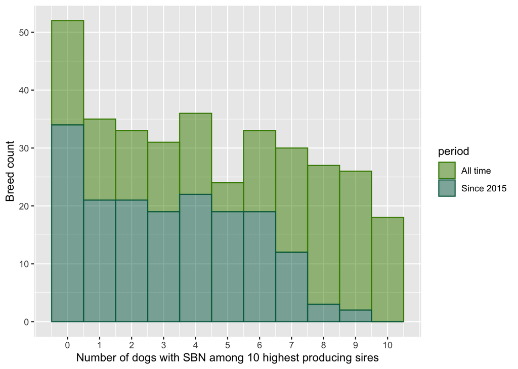

```r
pb2$period<-'All time'
pb2015$period<-'Since 2015'

pbs<-rbind(pb2,pb2015)

# Histogram overlaid with kernel density curve
p<-ggplot(pbs, aes(x=pb_count,fill=period,color=period)) +
    geom_histogram(bins=11, alpha=0.5)+
  scale_x_continuous(breaks = round(seq(0,10, by = 1),1))+
  xlab("Number of dogs with SBN among 10 highest producing sires")+
  ylab("Breed count")
p+scale_color_manual(values=c('chartreuse4',kcgreen))+
  scale_fill_manual(values=c( 'chartreuse4',kcgreen))
```

Histogram

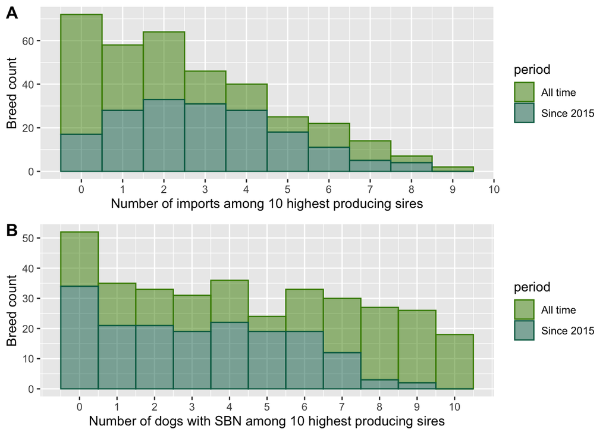

```r
# Histogram overlaid with kernel density curve
fig1 = ggplot(imps, aes(x=imp_count,fill=period,color=period)) +
    geom_histogram(bins=10, alpha=0.5)+
  scale_x_continuous(breaks = round(seq(0,10, by = 1),1))+
  xlab("Number of imports among 10 highest producing sires")+
  ylab("Breed count")

fig2 = ggplot(pbs, aes(x=pb_count,fill=period,color=period)) +
    geom_histogram(bins=11, alpha=0.5)+
  scale_x_continuous(breaks = round(seq(0,10, by = 1),1))+
  xlab("Number of dogs with SBN among 10 highest producing sires")+
  ylab("Breed count")

plot_grid(nrow=2,
          fig1 + scale_color_manual(values=c('chartreuse4',kcgreen))+
            scale_fill_manual(values=c( 'chartreuse4',kcgreen)),
          fig2+scale_color_manual(values=c('chartreuse4',kcgreen))+
            scale_fill_manual(values=c( 'chartreuse4',kcgreen)),
          labels = "AUTO")
```

```r
ggsave("Fig9_topSires_imp_SBN.jpg")
```